# 目录

# Table of Contents

[figure not shown]

# 科学哲学：简明导论

# Philosophy of Science: A Very Short Introduction

《极简入门》系列丛书旨在为希望以轻松有趣的方式了解新学科的读者提供帮助。该系列丛书由专家撰写，已被翻译成40多种语言。

VERY SHORT INTRODUCTIONS are for anyone wanting a stimulating and accessible way into a new subject. They are written by experts, and have been translated into more than 40 different languages.

该系列丛书始于1995年，如今已涵盖各个学科的众多主题。VSI丛书目前拥有超过450卷，从心理学和科学哲学到美国历史和相对论，无所不包，内容涵盖广泛，并且还在各个学科领域持续扩充。

The series began in 1995, and now covers a wide variety of topics in every discipline. The VSI library now contains over 450 volumes—a Very Short Introduction to everything from Psychology and Philosophy of Science to American History and Relativity—and continues to grow in every subject area.

现已推出《简明导论》：

Very Short Introductions available now:

会计克里斯托弗·诺布斯

青春期彼得·K·史密斯

广告温斯顿·弗莱彻

非裔美国人宗教埃迪·S·格劳德二世

非洲历史约翰·帕克和理查德·拉斯伯恩

非洲宗教雅各布·K·奥卢波纳

不可知论罗宾·勒·波德文

农业保罗·布拉斯利和理查德·索夫

亚历山大大帝 休·鲍登

代数彼得·M·希金斯

美国历史保罗·S·博耶

美国移民大卫·A·格伯

美国法律史G·爱德华·怀特

美国政治史唐纳德·克里奇洛

美国政党与选举L. Sandy Maisel

美国政治理查德·M·瓦莱利

美国总统制查尔斯·O·琼斯

美国革命罗伯特·J·艾利森

美国奴隶制希瑟·安德里亚·威廉姆斯

美国西部斯蒂芬·阿伦

美国妇女史苏珊·韦尔

麻醉师艾丹·奥唐纳

无政府主义科林·沃德

古代亚述凯伦·拉德纳

古埃及伊恩·肖

古埃及艺术与建筑克里斯蒂娜·里格斯

古希腊保罗·卡特利奇

古代近东阿曼达·H·波达尼

古代哲学朱莉娅·安娜斯

古代战争哈里·赛德博顿

天使队大卫·阿尔伯特·琼斯

圣公会马克·查普曼

盎格鲁-撒克逊时代约翰·布莱尔

动物王国彼得·霍兰德

动物权利大卫·德格拉齐亚

南极洲克劳斯·多兹

反犹主义史蒂文·贝勒

焦虑丹尼尔·弗里曼和杰森·弗里曼

伪经福音书保罗·福斯特

考古学保罗·班

建筑设计：安德鲁·巴兰坦

贵族制度威廉·道尔

亚里士多德乔纳森·巴恩斯

艺术史达娜·阿诺德

艺术理论辛西娅·弗里兰

天体生物学大卫·C·卡特林

天体物理学詹姆斯·宾尼

无神论朱利安·巴吉尼

奥古斯丁·亨利·查德威克

澳大利亚肯尼斯·摩根

自闭症Uta Frith

前卫艺术 大卫·科廷顿

阿兹特克人大卫·卡拉斯科

细菌Sebastian GB Amyes

巴特斯乔纳森·库勒

节拍大卫·斯特里特

美容罗杰·斯克鲁顿

畅销书作家约翰·萨瑟兰

圣经约翰·里奇斯

圣经考古学埃里克·H·克莱恩

赫敏·李传记

黑洞凯瑟琳·布伦德尔

布鲁斯伊利亚·沃尔德

克里斯·希林

摩尔门经特里尔·吉文斯

边界亚历山大·C·迪纳和约书亚·哈根

大脑迈克尔·奥谢

金砖国家安德鲁·F·库珀

英国宪法马丁·洛夫林

大英帝国阿什利·杰克逊

英国政治安东尼·赖特

佛陀迈克尔·卡里瑟斯

佛教达米安·基翁

佛教伦理达米安·基翁

拜占庭彼得·萨里斯

癌症尼古拉斯·詹姆斯

资本主义詹姆斯·富尔彻

天主教杰拉尔德·奥科林斯

因果关系：斯蒂芬·芒福德和拉尼·莉尔·安朱姆

《牢房》特伦斯·艾伦和格雷厄姆·考林

凯尔特人队巴里·坎利夫

混乱伦纳德·史密斯

化学彼得·阿特金斯

儿童心理学乌莎·戈斯瓦米

儿童文学金伯利·雷诺兹

中国文学萨宾娜·奈特

选择理论迈克尔·阿林厄姆

基督教艺术贝丝·威廉姆森

基督教伦理学D. 斯蒂芬·朗

基督教琳达·伍德海德

公民身份理查德·贝拉米

土木工程 大卫·缪尔·伍德

古典文学威廉·艾伦

古典神话海伦·莫拉莱斯

经典作品：玛丽·比尔德和约翰·亨德森

克劳塞维茨迈克尔·霍华德

气候马克·马斯林

气候变化马克·马斯林

冷战罗伯特·麦克马洪

殖民地时期的美国艾伦·泰勒

殖民时期拉丁美洲文学罗莱娜·阿多诺

组合数学家罗宾·威尔逊

喜剧演员马修·贝维斯

共产主义莱斯利·霍姆斯

复杂性约翰·H·霍兰德

计算机达雷尔·因斯

计算机科学Subrata Dasgupta

儒家思想丹尼尔·K·加德纳

征服者马修·雷斯塔尔和费利佩·费尔南德斯-阿梅斯托

良心保罗·斯特罗姆

意识苏珊·布莱克摩尔

当代艺术朱利安·斯塔拉布拉斯

当代小说罗伯特·伊格尔斯通

大陆哲学西蒙·克里奇利

珊瑚礁查尔斯·谢泼德

企业社会责任杰里米·穆恩

腐败莱斯利·霍姆斯

宇宙学彼得·科尔斯

犯罪小说理查德·布拉德福德

刑事司法朱利安·V·罗伯茨

批判理论斯蒂芬·埃里克·布朗纳

十字军东征克里斯托弗·泰尔曼

密码学弗雷德·派珀和肖恩·墨菲

晶体学AM Glazer

文化大革命理查德·柯特·克劳斯

达达主义与超现实主义大卫·霍普金斯

但丁·彼得·海因斯沃思和大卫·罗比

达尔文·乔纳森·霍华德

死海古卷蒂莫西·林

非殖民化戴恩·肯尼迪

民主伯纳德·克里克

德里达西蒙·格伦丁宁

笛卡尔汤姆·索雷尔

沙漠尼克·米德尔顿

设计：约翰·赫斯克特

发育生物学刘易斯·沃尔珀特

魔鬼达伦·奥尔德里奇

散居地凯文·肯尼

词典琳达·穆格尔斯通

恐龙大卫·诺曼

外交官约瑟夫·M·西拉库萨

纪录片帕特里夏·奥夫德海德

梦想J. Allan Hobson

毒品莱斯·艾弗森

德鲁伊教士巴里·坎利夫

早期音乐托马斯·福雷斯特·凯利

地球马丁·雷德芬

地球系统科学蒂姆·伦顿

经济学帕尔塔·达斯古普塔

教育加里·托马斯

埃及神话杰拉尔丁·平奇

十八世纪英国保罗·朗福德

元素菲利普·鲍尔

迪伦·埃文斯的情感

《帝国》史蒂芬·豪

恩格尔斯·特雷尔·卡弗

工程学大卫·布洛克利

英国文学乔纳森·贝特

启蒙运动约翰·罗伯逊

创业学保罗·韦斯特黑德和迈克·赖特

环境经济学斯蒂芬·史密斯

环境政治安德鲁·多布森

伊壁鸠鲁主义凯瑟琳·威尔逊

流行病学鲁道夫·萨拉奇

伦理学西蒙·布莱克本

民族音乐学蒂莫西·赖斯

伊特鲁里亚人克里斯托弗·史密斯

欧盟约翰·平德和西蒙·厄舍伍德

进化论布莱恩和黛博拉·查尔斯沃思

存在主义托马斯·弗林

探险家斯图尔特·A·韦弗

《眼睛》迈克尔·兰德

家庭法乔纳森·赫林

法西斯主义凯文·帕斯莫尔

时尚：丽贝卡·阿诺德

女权主义玛格丽特·沃尔特斯

电影《迈克尔·伍德》

电影音乐Kathryn Kalinak

第一次世界大战迈克尔·霍华德

民谣音乐马克·斯洛宾

食物约翰·克雷布斯

法庭心理学大卫·坎特

法医学吉姆·弗雷泽

森林Jaboury Ghazoul

化石 基思·汤姆森

福柯·加里·古廷

开国元勋RB 伯恩斯坦

分形肯尼斯·福尔克纳

言论自由奈杰尔·沃伯顿

自由意志托马斯·平克

法国文学约翰·D·莱昂斯

法国大革命威廉·道尔

弗洛伊德安东尼·斯托尔

原教旨主义马利斯·鲁思文

真菌尼古拉斯·P·莫尼

星系约翰·格里宾

伽利略·斯蒂尔曼·德雷克

博弈论肯·宾莫尔

甘地比库·帕雷克

基因乔纳森·斯莱克

天才安德鲁·罗宾逊

地理学约翰·马修斯和大卫·赫伯特

地缘政治克劳斯·多兹

德国文学尼古拉斯·博伊尔

德国哲学安德鲁·鲍伊

全球灾难比尔·麦奎尔

全球经济史罗伯特·C·艾伦

全球化曼弗雷德·施特格尔

上帝约翰·鲍克

歌德·里奇·罗伯逊

哥特式尼克·格鲁姆

治理马克·贝维尔

大萧条与新政埃里克·劳赫韦

哈贝马斯詹姆斯·戈登·芬利森

幸福丹尼尔·M·海布伦

哈莱姆文艺复兴谢丽尔·A·沃尔

希伯来圣经作为文学作品托德·利纳费尔特

黑格尔彼得·辛格

海德格尔迈克尔·英伍德

诠释学延斯·齐默尔曼

希罗多德詹妮弗·T·罗伯茨

象形文字佩内洛普·威尔逊

印度教 金·诺特

历史约翰·H·阿诺德

天文学史迈克尔·霍斯金

化学史威廉·H·布罗克

生命史迈克尔·本顿

数学史杰奎琳·斯特德尔

医学史威廉·拜纳姆

时间史 利奥弗兰克·霍尔福德-斯特雷文斯

艾滋病毒/艾滋病阿兰·怀特赛德

霍布斯理查德·塔克

好莱坞彼得·德切尼

荷尔蒙马丁·拉克

人体解剖学莱斯利·克莱纳曼

人类进化伯纳德·伍德

人权安德鲁·克拉普汉姆

人文主义史蒂芬·劳

休姆·艾尔

幽默诺埃尔·卡罗尔

冰河世纪杰米·伍德沃德

意识形态迈克尔·弗里登

印度哲学苏·汉密尔顿

传染病玛尔塔·L·韦恩和本杰明·M·博尔克

信息来源：卢西亚诺·弗洛里迪

创新马克·道奇森和大卫·甘恩

情报伊恩·J·迪里

国际法沃恩·洛

国际移民Khalid Koser

国际关系保罗·威尔金森

国际安全克里斯托弗·S·布朗宁

伊朗阿里·M·安萨里

伊斯兰教马利斯·鲁思文

伊斯兰历史亚当·西尔弗斯坦

同位素罗伯·埃勒姆

意大利文学彼得·海因斯沃思和大卫·罗比

耶稣理查德·鲍克汉姆

新闻记者伊恩·哈格里夫斯

犹太教诺曼·所罗门

荣格·安东尼·史蒂文斯

卡巴拉约瑟夫·丹

卡夫卡·里奇·罗伯逊

康德罗杰·斯克鲁顿

凯恩斯罗伯特·斯基德尔斯基

克尔凯郭尔帕特里克·加德纳

知识詹妮弗·纳格尔

《古兰经》迈克尔·库克

景观建筑伊恩·H·汤普森

景观与地貌学安德鲁·古迪和希瑟·维尔斯

语言斯蒂芬·R·安德森

晚期古代吉莉安·克拉克

法律雷蒙德·瓦克斯

热力学定律彼得·阿特金斯

领导层：基思·格林特

学习马克·哈塞尔格罗夫

自由主义迈克尔·弗里登

灯光伊恩·沃尔姆斯利

林肯·艾伦·C·格尔佐

语言学彼得·马修斯

文学理论乔纳森·库勒

洛克约翰·邓恩

逻辑学格雷厄姆·普里斯特

爱罗纳德·德·索萨

马基雅维利昆汀·斯金纳

疯狂安德鲁·斯库尔

魔术师欧文·戴维斯

《大宪章》尼古拉斯·文森特

磁力斯蒂芬·布伦德尔

马尔萨斯唐纳德·温奇

管理层：约翰·亨德利

毛德莉娅·达文

海洋生物学Philip V. Mladenov

萨德侯爵约翰·菲利普斯

马丁·路德·斯科特·H·亨德里克斯

殉难乔利恩·米切尔

马克思·彼得·辛格

材料克里斯托弗·霍尔

数学蒂莫西·高尔斯

生命的意义特里·伊格尔顿

医学伦理学托尼·霍普

医疗法查尔斯·福斯特

中世纪英国约翰·吉林厄姆和拉尔夫·A·格里菲斯

中世纪文学伊莱恩·特雷哈恩

中世纪哲学约翰·马伦邦

纪念乔纳森·K·福斯特

形而上学斯蒂芬·芒福德

墨西哥革命艾伦·奈特

迈克尔·法拉第弗兰克·AJL·詹姆斯

微生物学尼古拉斯·P·莫尼

微观经济学阿维纳什·迪克西特

显微镜学特伦斯·艾伦

中世纪 米里·鲁宾

矿物大卫·沃恩

现代艺术大卫·科廷顿

现代中国拉纳·米特

现代剧克尔斯滕·E·谢泼德-巴尔

现代法国瓦妮莎·R·施瓦茨

现代爱尔兰塞尼亚·帕塞塔

现代日本克里斯托弗·戈托-琼斯

现代拉丁美洲文学罗伯托·冈萨雷斯·埃切瓦里亚

现代战争理查德·英格利希

现代主义克里斯托弗·巴特勒

分子菲利普·鲍尔

蒙古人莫里斯·罗萨比

月亮大卫·A·罗瑟里

摩门教理查德·莱曼·布什曼

山脉马丁·F·普莱斯

穆罕默德·乔纳森·AC·布朗

多元文化主义阿里·拉坦西

音乐：尼古拉斯·库克

神话罗伯特·A·西格尔

拿破仑战争迈克·拉波特

民族主义史蒂文·格罗斯比

纳尔逊·曼德拉埃勒克·博默

新自由主义曼弗雷德·施特格尔和拉维·罗伊

网络Guido Caldarelli 和 Michele Catanzaro

新约 路加福音 提摩太·约翰逊

作为文学作品的新约凯尔·基弗

牛顿·罗伯特·伊利夫

尼采迈克尔·坦纳

十九世纪英国克里斯托弗·哈维和HCG·马修

诺曼征服乔治·加内特

北美印第安人西达·珀杜和迈克尔·D·格林

北爱尔兰马克·穆尔霍兰德

弗兰克·克洛斯

核物理学弗兰克·克洛斯

核能马克斯韦尔·欧文

核武器约瑟夫·M·西拉库萨

数字彼得·M·希金斯

营养学大卫·A·本德

客观性斯蒂芬·高克罗格

旧约迈克尔·D·库根

管弦乐队D. Kern Holoman

组织机构Mary Jo Hatch

异教欧文·戴维斯

巴以冲突马丁·邦顿

粒子物理学弗兰克·克洛斯

保罗· E·P·桑德斯

和平奥利弗·P·里士满

五旬节派威廉·K·凯

元素周期表埃里克·R·斯切里

哲学爱德华·克雷格

伊斯兰世界的哲学彼得·亚当森

法律哲学雷蒙德·瓦克斯

科学哲学Samir Okasha

摄影：史蒂夫·爱德华兹

物理化学彼得·阿特金斯

朝圣之旅伊恩·里德

瘟疫保罗·斯莱克

行星大卫·A·罗瑟里

植物蒂莫西·沃克

板块构造彼得·莫尔纳

柏拉图朱莉娅·安娜斯

政治哲学大卫·米勒

政治人物肯尼斯·米诺格

后殖民主义罗伯特·杨

后现代主义克里斯托弗·巴特勒

后结构主义凯瑟琳·贝尔西

史前史克里斯·戈斯登

前苏格拉底哲学凯瑟琳·奥斯本

隐私雷蒙德·沃克斯

概率论约翰·海格

进步主义沃尔特·纽金特

新教马克·A·诺尔

精神病学汤姆·伯恩斯

精神分析丹尼尔·皮克

心理学吉莉安·巴特勒和弗雷达·麦克马纳斯

心理治疗汤姆·伯恩斯和伊娃·伯恩斯-伦德格伦

清教主义弗朗西斯·J·布雷默

贵格会粉红蒲公英

量子理论约翰·波尔金霍恩

种族主义者阿里·拉坦西

放射性克劳迪奥·图尼兹

拉斯特法里教徒恩尼斯·B·埃德蒙兹

里根革命吉尔·特洛伊

现实 简·韦斯特霍夫

宗教改革彼得·马歇尔

相对论拉塞尔·斯坦纳德

美国宗教蒂莫西·比尔

文艺复兴杰瑞·布罗顿

文艺复兴艺术杰拉尔丁·A·约翰逊

革命杰克·A·戈德斯通

修辞学理查德·托耶

风险巴鲁克·菲什霍夫和约翰·卡德瓦尼

仪式巴里·斯蒂芬森

河流尼克·米德尔顿

机器人学阿兰·温菲尔德

罗马不列颠彼得·萨尔韦

罗马帝国 克里斯托弗·凯利

罗马共和国大卫·M·格温

浪漫主义迈克尔·费伯

卢梭 罗伯特·沃克勒

拉塞尔· A·C·格雷林

俄罗斯历史杰弗里·霍斯金

俄罗斯文学卡特里奥娜·凯利

俄国革命SA·史密斯

萨凡纳彼得·A·弗利

精神分裂症克里斯·弗里斯和伊芙·约翰斯通

肖本豪尔克里斯托弗·贾纳威

科学与宗教托马斯·迪克森

科幻小说大卫·西德

科学革命劳伦斯·M·普林西比

苏格兰拉布·休斯顿

性爱维罗妮克·莫蒂埃

莎士比亚喜剧巴特·范·埃斯

锡克教埃莉诺·内斯比特

丝绸之路詹姆斯·A·米尔沃德

俚语乔纳森·格林

睡眠史蒂文·W·洛克利和罗素·G·福斯特

社会与文化人类学约翰·莫纳汉和彼得·贾斯特

社会心理学理查德·J·克里斯普

社会工作萨莉·霍兰德和乔纳森·斯科菲尔德

社会主义迈克尔·纽曼

社会语言学约翰·爱德华兹

社会学史蒂夫·布鲁斯

苏格拉底CCW 泰勒

音效：迈克·戈德史密斯

苏联 斯蒂芬·洛弗尔

西班牙内战海伦·格雷厄姆

西班牙文学乔·拉巴尼

斯宾诺莎罗杰·斯克鲁顿

灵性菲利普·谢尔德雷克

体育记者迈克·克罗宁

明星安德鲁·金

统计学大卫·J·汉德

干细胞乔纳森·斯莱克

结构工程大卫·布洛克利

斯图尔特·布里坦约翰·莫里尔

超导性斯蒂芬·布伦德尔

对称伊恩·斯图尔特

税务斯蒂芬·史密斯

牙齿彼得·S·昂加尔

恐怖主义查尔斯·汤森

剧院马文·卡尔森

神学大卫·F·福特

托马斯·阿奎那弗格斯·克尔

蒂姆·贝恩

藏传佛教马修·T·卡普斯坦

托克维尔哈维·C·曼斯菲尔德

悲剧阿德里安·普尔

特洛伊战争埃里克·H·克莱恩

信任凯瑟琳·霍利

都铎王朝约翰·盖伊

二十世纪英国肯尼斯·O·摩根

联合国尤西·M·汉希迈基

美国国会唐纳德·A·里奇

美国最高法院琳达·格林豪斯

乌托邦主义莱曼·托尔·萨金特

《维京传奇》朱利安·理查兹

病毒多萝西·H·克劳福德

水约翰·芬尼

福利国家戴维·加兰

威廉·莎士比亚斯坦利·威尔斯

巫术马尔科姆·加斯基尔

维特根斯坦AC 格雷林

工作斯蒂芬·芬尼曼

世界音乐菲利普·博尔曼

世界贸易组织阿姆里塔·纳尔利卡尔

第二次世界大战格哈德·L·温伯格

编剧及剧本：安德鲁·罗宾逊

即将推出：

Available soon:

巴比伦尼亚特雷弗·布莱斯

血 克里斯·库珀

译者：马修·雷诺兹

公共卫生弗吉尼亚·贝里奇

印度电影Ashish Rajadhyaksha

更多信息请访问我们的网站

www.oup.com/vsi/

# 萨米尔·奥卡沙

# Samir Okasha

科学哲学

Philosophy of Science

# 简短介绍

# A Very Short Introduction

第二版

Second Edition

英国牛津市克拉伦登大街，邮编OX2 6DP

Great Clarendon Street, Oxford, OX2 6DP, United Kingdom

牛津大学出版社是牛津大学的一个部门。它通过在全球范围内出版发行，促进牛津大学在研究、学术和教育方面追求卓越的目标。“牛津”是牛津大学出版社在英国和其他一些国家的注册商标。

Oxford University Press is a department of the University of Oxford. It furthers the University’s objective of excellence in research, scholarship, and education by publishing worldwide. Oxford is a registered trade mark of Oxford University Press in the UK and in certain other countries

© Samir Okasha 2002, 2016

© Samir Okasha 2002, 2016

作者的著作权已得到维护。

The moral rights of the author have been asserted

第一版出版于2002年

First edition published 2002

第二版出版于2016年

Second edition published 2016

印象：1

Impression: 1

版权所有。未经牛津大学出版社事先书面许可，或法律、许可或与相关版权机构达成协议明确允许，不得以任何形式或任何方式复制、存储于检索系统或传播本出版物的任何部分。有关超出上述范围的复制事宜，请联系牛津大学出版社版权部，地址如上所示。

All rights reserved. No part of this publication may be reproduced, stored in a retrieval system, or transmitted, in any form or by any means, without the prior permission in writing of Oxford University Press, or as expressly permitted by law, by licence or under terms agreed with the appropriate reprographics rights organization. Enquiries concerning reproduction outside the scope of the above should be sent to the Rights Department, Oxford University Press, at the address above

你不得以任何其他形式传播此作品，并且你必须将此相同条件强加于任何获取者。

You must not circulate this work in any other form and you must impose this same condition on any acquirer

本书由美国牛津大学出版社出版，地址：198 Madison Avenue, New York, NY 10016, United States of America

Published in the United States of America by Oxford University Press 198 Madison Avenue, New York, NY 10016, United States of America

英国图书馆出版物编目数据

British Library Cataloguing in Publication Data

可用数据

Data available

美国国会图书馆控制号：2016931583

Library of Congress Control Number: 2016931583

ISBN 978–0–19–874558–7

ISBN 978–0–19–874558–7

电子书 ISBN 978–0–19–106279–7

ebook ISBN 978–0–19–106279–7

由英国汉普郡戈斯波特的阿什福德彩色印刷有限公司印刷

Printed in Great Britain by Ashford Colour Press Ltd, Gosport, Hampshire

牛津大学出于善意提供第三方网站链接，仅供参考。牛津大学对本作品中提及的任何第三方网站的内容不承担任何责任。

Links to third party websites are provided by Oxford in good faith and for information only. Oxford disclaims any responsibility for the materials contained in any third party website referenced in this work.

*致所罗门和约珥*

*For Solomon and Joel*

# 内容

# Contents

致谢

Acknowledgements

插图列表

List of illustrations

1.什么是科学？

1 What is science?

2科学推断

2 Scientific inference

3.科学中的解释

3 Explanation in science

4.现实主义与反现实主义

4 Realism and anti-realism

5科学变革和科学革命

5 Scientific change and scientific revolutions

物理学、生物学和心理学中的六个哲学问题

6 Philosophical problems in physics, biology, and psychology

7科学及其批评者

7 Science and its critics

延伸阅读

Further reading

指数

Index

# 致谢

# Acknowledgements

我要感谢比尔·牛顿-史密斯、菲利普·基彻、伊丽莎白·奥卡莎、雪莉·考克斯以及牛津大学出版社的读者们提出的宝贵意见和建议。同时，我也要感谢第一版的众多读者，他们向我提供了宝贵的意见、批评和建议，我在编写第二版时已尽力将这些意见和建议纳入考量。

I would like to thank Bill Newton-Smith, Philip Kitcher, Elisabeth Okasha, Shelley Cox, and OUP’s readers for their comments and suggestions. Thanks also to the numerous readers of the first edition who sent me their thoughts, criticisms, and comments, which I have tried to take into account in preparing the second edition.

# 插图列表

# List of illustrations

1哥白尼宇宙

© Archivo Iconografico, SA/Corbis

2.沃森和克里克的DNA模型

© A. Barrington Brown，冈维尔和凯斯学院/科学图片库

3.共同原因假说

4.旗杆和阴影

5云室

© CTR Wilson/科学图片库

6苯的结构

© 大卫·曼

7.牛顿的“旋转水桶”实验

8环物种

9.蜥蜴、鳄鱼和鸟类之间的系统发育关系

10.缪勒-莱尔错觉

# 第一章

# Chapter 1

# 什么是科学？

# What is science?

什么是科学？这个问题看似容易回答：人人都知道物理、化学和生物等学科属于科学，而艺术、音乐和神学等学科则不属于科学。但当我们作为哲学家追问“什么是科学”时，我们想要的答案并非如此。我们并非仅仅想要一份通常被称为“科学”的活动清单，而是想要探究清单上所有事物的共同特征，即是什么*使*它们成为科学。如此理解，我们的问题就远非那么简单了。

What is science? This question may seem easy to answer: everybody knows that subjects such as physics, chemistry, and biology constitute science, while subjects such as art, music, and theology do not. But when as philosophers we ask what science is, that is not the sort of answer we want. We are not asking for a mere list of the activities that are usually called ‘science’. Rather we are asking what common feature all the things on that list share, i.e. what it is that *makes* something a science. Understood this way, our question is not so trivial.

但你或许仍然认为这个问题相对简单明了。科学不就是试图理解、解释和预测我们所生活的世界吗？这当然是一个合理的答案。但这真的是全部真相吗？毕竟，各种宗教也试图理解和解释世界，但宗教通常不被视为科学的一个分支。同样，占星术和算命也是预测未来的尝试，但大多数人不会将这些活动描述为科学。再想想历史。历史学家试图理解和解释过去发生的事情，但历史通常被归类为人文学科，而非科学学科。正如许多哲学问题一样，“什么是科学？”这个问题远比乍看之下要复杂得多。

But you may still think the question is relatively straightforward. Surely science is just the attempt to understand, explain, and predict the world we live in? This is certainly a reasonable answer. But is it the whole story? After all, the various religions also attempt to understand and explain the world, but religion is not usually regarded as a branch of science. Similarly, astrology and fortune-telling are attempts to predict the future, but most people would not describe these activities as science. Or consider history. Historians try to understand and explain what happened in the past, but history is usually classified as a humanities subject not a science subject. As with many philosophical questions, the question ‘what is science?’ is trickier than it looks at first sight.

许多人认为，科学的显著特征在于科学家用来探索世界的独特*方法*。这种观点颇有道理。因为许多科学学科确实采用了非科学领域所不具备的独特研究方法。一个显而易见的例子就是实验的使用，它在历史上标志着现代科学发展的一个转折点。然而，并非所有科学都是实验性的——天文学家显然无法对天体进行实验，只能进行细致的观察。许多社会科学也是如此。科学的另一个重要特征是理论的构建。科学家并非仅仅将实验和观察的结果记录在日志中——他们通常希望用一个普遍的理论来解释这些结果。这并非易事，但也有一些令人瞩目的成功案例。科学哲学的主要任务之一，就是理解实验、观察和理论构建等技术是如何帮助科学家揭开自然界诸多奥秘的。

Many people believe that the distinguishing features of science lie in the particular *methods* scientists use to investigate the world. This suggestion is quite plausible. For many scientific disciplines do employ distinctive methods of enquiry that are not used in non-scientific enterprises. An obvious example is the use of experiments, which historically marks a turning-point in the development of modern science. Not all the sciences are experimental though—astronomers obviously cannot do experiments on the heavens, but have to content themselves with careful observation instead. The same is true of many social sciences. Another important feature of science is the construction of theories. Scientists do not simply record the results of experiment and observation in a log book—they usually want to explain those results in terms of a general theory. This is not always easy to do, but there have been some striking successes. One of the main tasks of philosophy of science is to understand how techniques such as experimentation, observation, and theory construction have enabled scientists to unravel so many of nature’s secrets.

# 现代科学的起源

# The origins of modern science

在当今的中小学和大学里，科学教学很大程度上缺乏历史视角。教科书尽可能以最便捷的方式呈现某一科学学科的核心概念，却鲜少提及促成这些概念发现的漫长而曲折的历史进程。作为一种教学策略，这无可厚非。然而，对科学思想史有所了解，有助于理解科学哲学家们所关注的问题。事实上，正如我们将在第五章中看到的，有人认为，密切关注科学史对于做好科学哲学研究至关重要。

In today’s schools and universities, science is taught in a largely ahistorical way. Textbooks present the key ideas of a scientific discipline in as convenient a form as possible, with little mention of the lengthy and often tortuous historical process which led to their discovery. As a pedagogical strategy, this makes good sense. But some appreciation of the history of scientific ideas is helpful for understanding the issues that interest philosophers of science. Indeed as we shall see in Chapter 5, it has been argued that close attention to the history of science is indispensable for doing good philosophy of science.

现代科学的起源可以追溯到1500年至1750年间欧洲科学的快速发展时期，我们现在称之为*科学革命*。古代和中世纪也曾进行过科学研究——科学革命并非凭空而来。在这些早期时期，占主导地位的世界观是*亚里士多德*主义，它以古希腊哲学家亚里士多德的名字命名，亚里士多德提出了物理学、生物学、天文学和宇宙学方面的详尽理论。但亚里士多德的思想及其研究方法在现代科学家看来会非常怪异。举例来说，他认为所有物体都由四种元素组成：土、火、气和水。这种观点显然与现代化学的理论相悖。

The origins of modern science lie in a period of rapid scientific development that occurred in Europe between about 1500 and 1750, which we now refer to as the *scientific revolution*. Of course scientific investigations were pursued in ancient and medieval times too—the scientific revolution did not come from nowhere. In these earlier periods the dominant worldview was *Aristotelianism*, named after the ancient Greek philosopher Aristotle, who put forward detailed theories in physics, biology, astronomy, and cosmology. But Aristotle’s ideas would seem very strange to a modern scientist, as would his methods of enquiry. To pick just one example, he believed that all earthly bodies are composed of just four elements: earth, fire, air, and water. This view is obviously at odds with what modern chemistry tells us.

现代科学世界观发展的第一个关键步骤是哥白尼革命。1542年，波兰天文学家尼古拉·哥白尼（1473-1543）出版了一本书，抨击了地心宇宙模型。地心宇宙模型认为静止的地球位于宇宙中心，行星和太阳围绕地球运行。地心天文学，也称托勒密天文学（以古希腊天文学家托勒密的名字命名），是亚里士多德世界观的核心，并在1800年间几乎未受到挑战。但哥白尼提出了另一种方案：太阳*是*宇宙的固定中心，包括地球在内的行星围绕太阳运行（见图1）。在这种日心说模型中，地球被视为一颗普通的行星，因此失去了传统赋予它的独特地位。哥白尼的理论最初遭到了很多阻力，尤其是来自天主教会的阻力，他们认为这违背了圣经，并在1616年查禁了所有宣扬地球运动的书籍。但不到100年，哥白尼学派就成为了公认的科学正统观念。

The first crucial step in the development of the modern scientific worldview was the Copernican revolution. In 1542 the Polish astronomer Nicolas Copernicus (1473–1543) published a book attacking the geocentric model of the universe, which placed the stationary earth at the centre of the universe with the planets and the sun in orbit around it. Geocentric astronomy, also known as Ptolemaic astronomy after the ancient Greek astronomer Ptolemy, lay at the heart of the Aristotelian worldview, and had gone largely unchallenged for 1,800 years. But Copernicus suggested an alternative: the *sun* was the fixed centre of the universe, and the planets, including the earth, were in orbit around it (see Figure 1). On this heliocentric model the earth is regarded as just another planet, and so loses the unique status that tradition had accorded it. Copernicus’ theory initially met with much resistance, not least from the Catholic Church who regarded it as contravening the Scriptures, and in 1616 banned books advocating the earth’s motion. But within 100 years Copernicanism had become established scientific orthodoxy.

[figure not shown]

1.哥白尼的日心宇宙模型，显示包括地球在内的行星围绕太阳运行。

1. Copernicus’ heliocentric model of the universe, showing the planets, including the earth, orbiting the sun.

Copernicus’ innovation did not merely lead to a better astronomy. Indirectly, it led to the development of modern physics, through the work of Johannes Kepler (1571–1630) and Galileo Galilei (1564–1642). Kepler discovered that the planets do not move in circular orbits around the sun, as Copernicus thought, but rather in *ellipses*. This was his ‘first law’ of planetary motion; his second and third laws specify the speeds at which the planets orbit the sun. Taken together, Kepler’s laws provided a successful planetary theory, solving problems that had confounded astronomers for centuries. Galileo was a lifelong supporter of Copernicanism and one of the early pioneers of the telescope. When he pointed his telescope at the heavens, he made a wealth of amazing discoveries: mountains on the moon, a vast array of stars, sun-spots, Jupiter’s moons, and more. All of these conflicted with Aristotelian cosmology, and played a pivotal role in converting the scientific community to Copernicanism.

然而，伽利略最持久的贡献并非在于天文学，而在于力学。他驳斥了亚里士多德关于重物比轻物下落速度更快的理论。伽利略提出了一个反直觉的观点来取代这一理论：所有物体的下落速度都相等。自由落体无论重量如何，都会以相同的速度落向地球。（当然，在实际中，如果你从同一高度同时扔下一根羽毛和一个炮弹，炮弹会先落地，但伽利略认为这仅仅是由于空气阻力造成的——在真空中，它们会同时落地。）此外，他还认为自由落体做匀加速运动，即在相等的时间内速度增加量相等；这就是著名的伽利略自由落体定律。伽利略为这一定律提供了令人信服但并非决定性的证据，而这一定律也构成了他力学的核心。

Galileo’s most enduring contribution, however, lay not in astronomy but in mechanics, where he refuted the Aristotelian theory that heavier bodies fall faster than lighter ones. In place of this theory, Galileo made the counter-intuitive suggestion that all freely falling bodies will fall towards the earth at the same rate, irrespective of their weight. (Of course in practice, if you drop a feather and a cannonball from the same height the cannonball will land first, but Galileo argued that this is simply due to air resistance—in a vacuum, they would land together.) Furthermore, he argued that freely falling bodies accelerate uniformly, i.e. gain equal increments of speed in equal times; this is known as Galileo’s law of free fall. Galileo provided persuasive though not conclusive evidence for this law, which formed the centrepiece of his mechanics.

伽利略通常被认为是第一位现代物理学家。他是第一个证明数学语言可以用来描述物质对象（例如落体和抛射体）行为的人。对我们来说，这似乎显而易见——如今的科学理论通常用数学语言表达，不仅在物理学领域，在生物科学和社会科学领域也是如此。但在伽利略的时代，这并非显而易见：数学被广泛认为是处理纯粹抽象概念的，因此不适用于物理现实。伽利略的另一个创新之处在于他强调通过实验检验假设。对现代科学家来说，这或许也是理所当然的。但在伽利略的时代，实验并不被普遍认为是获取知识的可靠途径。伽利略对实验的重视标志着一种研究自然的经验方法的开端，这种方法一直延续至今。

Galileo is generally regarded as the first modern physicist. He was the first to show that the language of mathematics could be used to describe the behaviour of material objects, such as falling bodies and projectiles. To us this seems obvious—today’s scientific theories are routinely formulated in mathematical language, not only in physics but also in the biological and social sciences. But in Galileo’s day it was not obvious: mathematics was widely regarded as dealing with purely abstract entities, hence inapplicable to physical reality. Another innovative aspect was Galileo’s emphasis on testing hypotheses experimentally. To the modern scientist this may again seem obvious. But in Galileo’s day experimentation was not generally regarded as a reliable means of gaining knowledge. Galileo’s emphasis on experiment marks the beginning of an empirical approach to studying nature that continues to this day.

伽利略去世后的时期，科学革命迅速发展。法国哲学家兼科学家勒内·笛卡尔（1596-1650）发展出一种全新的“机械论哲学”，该哲学认为物理世界由相互作用和碰撞的惰性物质粒子构成。笛卡尔相信，支配这些粒子或“微粒”运动的规律是理解宇宙结构的关键。机械论哲学承诺用这些微粒的运动来解释所有可观测的现象，并迅速成为主流哲学。这是17世纪晚期的科学思想，在某种程度上，它至今仍然存在。惠更斯、伽桑狄、胡克和波义耳等人都曾拥护过机械论哲学；它的被接受标志着亚里士多德世界观的最终衰落。

The period following Galileo’s death saw the scientific revolution rapidly gain in momentum. The French philosopher-scientist René Descartes (1596–1650) developed a radical new ‘mechanical philosophy’, according to which the physical world consists of inert particles of matter interacting and colliding with one another. The laws governing the motion of these particles or ‘corpuscles’ held the key to understanding the structure of the universe, Descartes believed. The mechanical philosophy promised to explain all observable phenomena in terms of the motions of these corpuscles, and quickly became the dominant scientific vision of the late 17th century; to some extent it is still with us today. Versions of the mechanical philosophy were espoused by figures such as Huygens, Gassendi, Hooke, and Boyle; its acceptance marked the final downfall of the Aristotelian worldview.

科学革命在艾萨克·牛顿（1643-1727）的著作中达到顶峰，他的杰作《*自然哲学的数学原理*》于1687年出版。

The scientific revolution culminated in the work of Isaac Newton (1643–1727), whose masterpiece, *Mathematical Principles of Natural Philosophy*, was published in 1687.

牛顿认同机械哲学家的观点，认为宇宙仅仅由运动的粒子构成，并致力于改进笛卡尔的理论。最终，他建立了一套强大的动力学和力学理论，其核心是牛顿三大运动定律和著名的*万有引力*原理。根据这一原理，宇宙中任何物体都对其他物体施加引力；两个物体之间的引力大小取决于它们的质量乘积与它们之间距离的平方。运动定律则阐明了这种引力如何影响物体的运动。牛顿以惊人的精确性和严谨性完善了他的理论，并发明了我们现在称之为“微积分”的数学方法。值得注意的是，牛顿证明了开普勒的行星运动定律和伽利略的自由落体定律（经过一些细微的修正）都是他的运动定律和万有引力定律的逻辑推论。因此，一套单一的定律可以解释地球和天体中物体的运动，并且由牛顿以精确的定量形式表述出来。

Newton agreed with the mechanical philosophers that the universe consists simply of particles in motion, and sought to improve on Descartes’s theory. The result was a dynamical and mechanical theory of great power, based around Newton’s three laws of motion and his famous principle of *universal gravitation*. According to this principle, every body in the universe exerts a gravitational attraction on every other body; the strength of the attraction between two bodies depends on the product of their masses, and on the distance between them squared. The laws of motion then specify how this gravitational force affects the bodies’ motions. Newton elaborated his theory with remarkable precision and rigour, inventing the mathematical techniques we now call ‘calculus’. Strikingly, Newton was able to show that Kepler’s laws of planetary motion and Galileo’s law of free fall (both with certain minor modifications) were logical consequences of his laws of motion and gravitation. So a single set of laws could explain the motions of bodies in both terrestrial and celestial domains, and were formulated by Newton in a precise quantitative form.

牛顿物理学为接下来的两百年科学发展奠定了基础，迅速取代了笛卡尔物理学。在此期间，科学信心迅速增长，这主要归功于牛顿理论的成功。人们普遍认为牛顿理论揭示了自然界的真正运行规律，并且至少在原则上能够解释一切。人们进行了大量的尝试，试图将牛顿的解释模式扩展到越来越多的领域。现象。18世纪和19世纪都见证了显著的科学进步，尤其是在化学、光学、热力学和电磁学领域。但总的来说，这些发展被认为符合牛顿宇宙观的框架。科学家们普遍接受牛顿的宇宙观，认为其基本正确；剩下的工作就是完善细节。

Newtonian physics provided the framework for science for the next 200 years, quickly replacing Cartesian physics. Scientific confidence grew rapidly in this period, due largely to the success of Newton’s theory, which was widely believed to have revealed the true workings of nature, and to be capable of explaining everything, in principle at least. Detailed attempts were made to extend the Newtonian mode of explanation to more and more phenomena. The 18th and 19th centuries both saw notable scientific advances, particularly in chemistry, optics, thermodynamics, and electromagnetism. But for the most part, these developments were regarded as falling within a broadly Newtonian conception of the universe. Scientists accepted Newton’s conception as essentially correct; what remained to be done was to fill in the details.

20世纪初，物理学领域的两项革命性新进展——相对论和量子力学——动摇了人们对牛顿力学的信心。爱因斯坦发现的相对论表明，牛顿力学在应用于质量极大的物体或高速运动的物体时，无法给出正确的结果。相反，量子力学则表明，牛顿理论在应用于亚原子粒子等极小尺度时也失效了。相对论和量子力学，尤其是后者，都是奇异而激进的理论，它们对现实本质的论断与常识相悖，许多人难以接受甚至理解。它们的出现给物理学带来了巨大的概念性变革，这种变革至今仍在持续。

Confidence in the Newtonian picture was shattered in the early years of the 20th century, thanks to two revolutionary new developments in physics: relativity theory and quantum mechanics. Relativity theory, discovered by Einstein, showed that Newtonian mechanics does not give the right results when applied to very massive objects, or objects moving at very high velocities. Quantum mechanics, conversely, shows that the Newtonian theory does not work when applied on a very small scale, to subatomic particles. Both relativity theory and quantum mechanics, especially the latter, are strange and radical theories, making claims about the nature of reality which conflict with common sense, and which many people find hard to accept or even understand. Their emergence caused considerable conceptual upheaval in physics, which continues to this day.

到目前为止，我们对科学史的简要概述主要集中在物理学上。这并非偶然，因为物理学不仅在历史上举足轻重，而且在某种意义上也是最基础的科学学科。其他科学研究的对象本身也是由物理实体构成的，反之则不然。以植物学为例。植物学家研究植物，植物由细胞构成，细胞又由生物分子构成，生物分子最终由原子构成，而原子是物理粒子。因此，植物学研究的实体不如物理学那样“基础”——但这并不意味着它不重要。这一点我们将在第三章中再次讨论。但是，即使是对现代科学起源的简要描述，如果忽略了非物理科学，也是不完整的。

So far our brief account of the history of science has focused mainly on physics. This is no accident, as physics is both historically important and in a sense the most fundamental scientific discipline. For the objects that other sciences study are themselves made up of physical entities, but not vice versa. Consider botany, for example. Botanists study plants, which are composed of cells, which are themselves composed of bio-molecules, which are ultimately made up of atoms, which are physical particles. So botany deals with entities that are less ‘fundamental’ than does physics—though that is not to say it is less important. This is a point we shall return to in Chapter 3. But even a brief description of modern science’s origins would be incomplete if it omitted all mention of the non-physical sciences.

在生物学领域，最引人注目的事件莫过于查尔斯·达尔文于1859年发表的*《物种起源》一书*，书中阐述了自然选择进化论。在此之前，人们普遍认为不同的物种是上帝按照《创世记》的记载分别创造的。但达尔文认为，现存物种实际上是通过*自然选择*这一过程，从祖先物种进化而来。自然选择是指某些生物体因其生理特征而比其他生物体留下更多后代；如果这些特征被后代继承，随着时间的推移，种群就会越来越适应环境。达尔文指出，尽管这个过程看似简单，但经过无数代，它可以使一个物种进化成一个全新的物种。达尔文为他的理论提出的证据如此令人信服，以至于到20世纪初，尽管遭到了相当大的神学反对，它仍然被奉为科学正统。后来的研究为达尔文的理论提供了令人信服的佐证，该理论也构成了现代生物学世界观的核心。

In biology, the event that stands out is Charles Darwin’s discovery of the theory of evolution by natural selection, published in *The Origin of Species* in 1859. Until then it was widely believed that the different species had been separately created by God, as the Book of Genesis teaches. But Darwin argued that contemporary species have actually evolved from ancestral ones, through a process known as *natural selection*. Natural selection occurs when some organisms leave more offspring than others, depending on their physical characteristics; if these characteristics are then inherited by their offspring, over time the population will become better and better adapted to the environment. Simple though this process is, over a large number of generations it can cause one species to evolve into a wholly new one, Darwin argued. So persuasive was the evidence Darwin adduced for his theory that by the start of the 20th century it was accepted as scientific orthodoxy, despite considerable theological opposition. Subsequent work has provided striking confirmation of Darwin’s theory, which forms the centrepiece of the modern biological worldview.

20世纪见证了生物学领域另一场尚未完成的革命：分子生物学和遗传学的兴起。1953年，沃森和克里克发现了DNA的结构，DNA是构成生物细胞基因的遗传物质（见图2）。沃森和克里克的发现解释了遗传信息如何在细胞间复制，从而从亲代传递给子代，进而解释了为什么子代往往与父母相似。他们的发现开辟了一个令人兴奋的生物学研究新领域——分子生物学，该领域研究生物现象的分子基础。自沃森和克里克的研究以来的六十年间，分子生物学发展迅猛，彻底改变了我们对遗传、发育和其他核心生物过程的理解。2003年，历时十年、旨在提供人类全部基因组分子水平描述的人类基因组计划终于完成。虽然这项技术已经完成，但其对医学和生物技术的影响才刚刚开始被探索。21世纪，该领域很可能会出现更多令人振奋的发展。

The 20th century witnessed another revolution in biology that is not yet complete: the emergence of molecular biology and genetics. In 1953 Watson and Crick discovered the structure of DNA, the hereditary material that makes up the genes in the cells of living creatures (see Figure 2). Watson and Crick’s discovery explained how genetic information can be copied from one cell to another, and thus passed down from parent to offspring, thereby explaining why offspring tend to resemble their parents. Their discovery opened up an exciting new area of biological research known as molecular biology, which studies the molecular basis of biological phenomena. In the sixty years since Watson and Crick’s work, molecular biology has grown fast, transforming our understanding of heredity, development, and other core biological processes. In 2003, the decade-long attempt to provide a molecular-level description of the complete set of genes in a human being, known as the Human Genome Project, was finally completed; the implications for medicine and biotechnology have only begun to be explored. The 21st century will most likely see further exciting developments in this field.

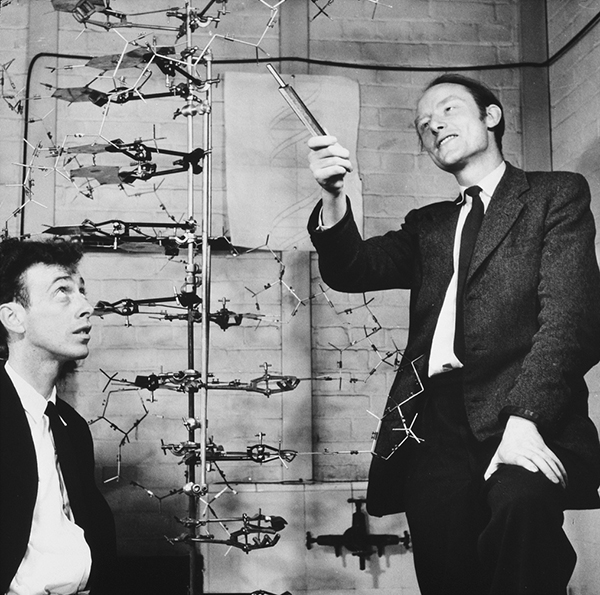

2.詹姆斯·沃森和弗朗西斯·克里克发现了著名的“双螺旋”——这是他们于 1953 年发现的 DNA 结构的分子模型。

2. James Watson and Francis Crick with the famous ‘double helix’—their molecular model of the structure of DNA, discovered in 1953.

过去六十年间，投入科学研究的资源比以往任何时候都多。其成果之一是计算机科学、人工智能和神经科学等新兴学科的蓬勃发展。20世纪后期，认知科学兴起，它研究人类认知的各个方面，包括感知、记忆和推理，并彻底改变了传统心理学。认知科学的兴起很大程度上源于这样一种观点：人类的心智在某种程度上是不可预测的。人类的思维方式与计算机有相似之处，可以通过将其与计算机的运算进行比较来理解人类的思维过程。相比之下，神经科学则研究大脑本身的运作方式。得益于脑部扫描技术的进步，神经科学家们开始了解人类（以及动物）认知背后的神经基础。这项研究本身就具有巨大的意义，并且可能有助于改进精神疾病的治疗方法。

More resources have been devoted to scientific research in the last sixty years than ever before. One result has been an explosion of new scientific disciplines, such as computer science, artificial intelligence, and neuroscience. The late 20th century witnessed the rise of cognitive science, which studies aspects of human cognition including perception, memory, and reasoning, and has transformed traditional psychology. Much of the impetus for cognitive science comes from the idea that the human mind is in some respects similar to a computer, and that human mental processes can be understood by comparing them to the operations computers carry out. By contrast, the field of neuroscience studies how the brain itself works. Thanks to technological advances in brain scanning, neuroscientists are beginning to understand the underlying neural basis of human (and animal) cognition. This enterprise is of great intrinsic interest and may also lead to improved treatments for mental disorders.

经济学、人类学和社会学等社会科学在20世纪也蓬勃发展，尽管有人认为它们在复杂性和预测能力方面落后于自然科学。这就引出了一个有趣的方法论问题：社会科学家是否应该尝试使用与自然科学家相同的方法，还是说他们的研究对象需要不同的方法？我们将在第七章再次探讨这个问题。

The social sciences, such as economics, anthropology, and sociology, also flourished in the 20th century, though some believe they lag behind the natural sciences in terms of sophistication and predictive power. This raises an interesting methodological question. Should social scientists try to use the same methods as natural scientists, or does their subject matter call for a different approach? We return to this issue in Chapter 7.

# 什么是科学哲学？

# What is philosophy of science?

科学哲学的主要任务是分析科学研究中使用的探究方法。你或许会疑惑，为什么这项任务应该由哲学家承担，而不是科学家自己？这是一个很好的问题。部分答案在于，哲学反思能够揭示科学探究中隐含的假设。举例来说，假设一位科学家做了一个实验，并得到了某个特定的结果。他重复实验几次，每次都得到相同的结果。之后，他很可能会停止实验，因为他确信，如果在完全相同的条件下再次重复实验，结果仍然会相同。这个假设看似显而易见，但作为哲学家，我们却想要质疑它。*为什么*会假设未来的实验重复会得到相同的结果？我们如何知道这是真的？科学家不太可能花太多时间思考这个问题：他们可能还有更重要的事情要做。这是一个典型的哲学问题。

The principal task of philosophy of science is to analyse the methods of enquiry used in the sciences. You may wonder why this task should fall to philosophers, rather than to the scientists themselves. This is a good question. Part of the answer is that philosophical reflection can uncover assumptions that are implicit in scientific enquiry. To illustrate, consider experimental practice. Suppose a scientist does an experiment and gets a particular result. They repeat the experiment a few times and keep getting the same result. After that they will probably stop, confident that were the experiment repeated again under exactly the same conditions, the same result would obtain. This assumption may seem obvious, but as philosophers we want to question it. *Why* assume that future repetitions of the experiment will yield the same result? How do we know this is true? The scientist is unlikely to spend much time puzzling over this: they probably have better things to do. It is a quintessentially philosophical question.

因此，科学哲学的部分工作在于质疑科学家们习以为常的假设。但如果就此断言科学家从不讨论哲学问题，那就错了。事实上，从历史上看，科学家在科学哲学的发展中扮演了关键角色。笛卡尔、牛顿和爱因斯坦就是杰出的例证。他们都对科学应该如何发展、应该采用何种研究方法以及科学知识是否存在局限性等问题抱有浓厚的兴趣。这些问题至今仍是当代科学哲学的核心。因此，科学哲学家所关注的问题也吸引了一些最伟大的科学家的目光。话虽如此，我们必须承认，如今许多科学家对科学哲学兴趣寥寥，知之甚少。这固然令人遗憾，但这并不意味着哲学问题不再重要。相反，这是科学日益专业化以及现代教育中科学与人文学科日益分化的结果。

So part of the job of philosophy of science is to question assumptions that scientists take for granted. But it would be wrong to imply that scientists never discuss philosophical issues themselves. Indeed historically, scientists have played a key role in the development of philosophy of science. Descartes, Newton, and Einstein are prominent examples. Each was deeply interested in questions about how science should proceed, what methods of enquiry it should use, and whether there are limits to scientific knowledge. These questions still lie at the heart of contemporary philosophy of science. So the issues that concern philosophers of science have engaged the attention of some of the greatest scientists. That being said, it must be admitted that many scientists today take little interest in philosophy of science, and know little about it. While this is unfortunate, it is not an indication that philosophical issues are no longer relevant. Rather it is a consequence of the increasingly specialized nature of science, and of the polarization between the sciences and the humanities that characterizes much modern education.

你或许仍然不明白科学哲学究竟是什么。仅仅说它“研究科学方法”其实并不全面。与其试图给出一个更详尽的定义，我们不如探讨一下科学哲学中的一个经典问题。

You may still be wondering exactly what philosophy of science is all about. For to say that it ‘studies the methods of science’ is not really to say very much. Rather than try to provide a more informative definition, we will instead examine a classic issue in the philosophy of science.

# 科学与伪科学

# Science and pseudo-science

回想一下我们一开始提出的问题：什么是科学？20世纪极具影响力的科学哲学家卡尔·波普尔认为，科学理论的基本特征是可*证伪性*。称一个理论可证伪，并非意味着它是错误的。而是指该理论能够做出一些明确的预测，这些预测可以通过经验进行检验。如果这些预测最终被证明是错误的，那么该理论就被证伪了。因此，可证伪的理论是指……*可能*会被证明是错误的——它并非与所有可能的经验相符。波普尔认为，一些所谓的科学理论并不符合这一条件，因此根本不配被称为科学；它们仅仅是伪科学。

Recall the question with which we began: what is science? Karl Popper, an influential 20th-century philosopher of science, thought that the fundamental feature of a scientific theory is that it should be *falsifiable*. To call a theory falsifiable is not to say that it is false. Rather, it means that the theory makes some definite predictions which are capable of being tested against experience. If these predictions turn out to be wrong, then the theory has been falsified, or disproved. So a falsifiable theory is one which we *might* discover to be false—it is not compatible with every possible course of experience. Popper thought that some supposedly scientific theories did not satisfy this condition and thus did not deserve to be called science at all; they were merely pseudo-science.

弗洛伊德的精神分析理论是波普尔最喜欢的伪科学例子之一。波普尔认为，弗洛伊德的理论可以与任何经验发现相吻合。无论病人的行为如何，弗洛伊德主义者都能用他们的理论找到解释——他们永远不会承认自己的理论是错误的。波普尔用以下例子来说明他的观点。想象一下，一个人把一个孩子推进河里，意图谋杀他；另一个人为了救孩子而牺牲了自己的生命。弗洛伊德主义者可以同样轻松地解释这两个人的行为：前者是压抑，后者是升华。波普尔认为，通过使用压抑、升华和无意识欲望等概念，弗洛伊德的理论可以与任何临床数据相兼容；因此，它是无法证伪的。

Freud’s psychoanalytic theory was one of Popper’s favourite examples of pseudo-science. According to Popper, Freud’s theory could be reconciled with any empirical findings whatsoever. Whatever a patient’s behaviour, Freudians could find an explanation of it in terms of their theory—they would never admit that their theory was wrong. Popper illustrated his point with the following example. Imagine a man who pushes a child into a river with the intention of murdering him, and another man who sacrifices his life in order to save the child. Freudians can explain both men’s behaviour with equal ease: the first was repressed, and the second had achieved sublimation. Popper argued that through the use of such concepts as repression, sublimation, and unconscious desires, Freud’s theory could be rendered compatible with any clinical data whatever; it was thus unfalsifiable.

波普尔认为，马克思的历史理论也存在同样的问题。马克思声称，在世界各地的工业化社会中，资本主义终将让位于社会主义，最终走向共产主义。但当这种情况没有发生时，马克思主义者非但不承认马克思的理论是错误的，反而会编造出一套临时性的解释，来证明实际发生的情况与他们的理论完全吻合。例如，他们可能会说，福利国家的兴起暂时延缓了通往共产主义的必然进程，福利国家“软化”了无产阶级，削弱了他们的革命热情。如此一来，马克思的理论就像弗洛伊德的理论一样，可以与任何可能的历史进程相兼容。因此，按照波普尔的标准，这两种理论都不能算是真正科学的。

The same was true of Marx’s theory of history, Popper maintained. Marx claimed that in industrialized societies around the world, capitalism would give way to socialism and ultimately to communism. But when this didn’t happen, instead of admitting that Marx’s theory was wrong, Marxists would invent an ad hoc explanation for why what had happened was actually perfectly consistent with their theory. For example, they might say that the inevitable progress to communism had been temporarily slowed by the rise of the welfare state, which ‘softened’ the proletariat and weakened their revolutionary zeal. In this way, Marx’s theory could be made compatible with any possible course of events, just like Freud’s. Therefore neither theory qualifies as genuinely scientific, according to Popper’s criterion.

波普尔将弗洛伊德和马克思的理论与爱因斯坦的引力理论（即*广义相对论）*进行了对比。与弗洛伊德不同的是……与马克思的理论相比，爱因斯坦的理论做出了一个非常明确的预言：来自遥远恒星的光线会被太阳的引力场偏转。通常情况下，这种效应是无法观测到的——除非是在日食期间。1919年，英国天体物理学家亚瑟·爱丁顿爵士组织了两次考察，分别前往巴西和位于非洲大西洋沿岸的普林西比岛，以观测当年的日食，目的是为了验证爱因斯坦的预言。考察队发现，星光确实被太阳偏转，偏转的程度几乎与爱因斯坦的预言完全一致。波普尔对此印象深刻。爱因斯坦的理论做出了一个明确而精确的预言，并得到了观测的证实。如果观测结果表明星光并没有*被*太阳偏转，那就证明爱因斯坦的理论是错误的。因此，爱因斯坦的理论符合可证伪性的标准。

Popper contrasted Freud’s and Marx’s theories with Einstein’s theory of gravitation, known as *general relativity*. Unlike Freud’s and Marx’s theories, Einstein’s theory made a very definite prediction: that light rays from distant stars would be deflected by the gravitational field of the sun. Normally this effect would be impossible to observe—except during a solar eclipse. In 1919 the English astrophysicist Sir Arthur Eddington organized two expeditions to observe the solar eclipse of that year, one to Brazil and one to the island of Principe off the Atlantic coast of Africa, with the aim of testing Einstein’s prediction. The expeditions found that starlight was indeed deflected by the sun, by almost exactly the amount Einstein had predicted. Popper was very impressed by this. Einstein’s theory had made a definite, precise prediction, which was confirmed by observations. Had it turned out that starlight was *not* deflected by the sun, this would have shown that Einstein was wrong. So Einstein’s theory satisfies the criterion of falsifiability.

波普尔试图区分科学与伪科学，这在直觉上是相当合理的。一个理论如果能够随意拟合任何经验数据，那它肯定存在一些可疑之处。但许多哲学家认为波普尔的标准过于简单化。波普尔批评弗洛伊德主义者和马克思主义者，认为他们不愿承认自己的理论已被驳斥，而是试图用各种解释来掩盖任何看似与其理论相悖的数据。这看起来确实是一种可疑的做法。然而，有证据表明，一些“受人尊敬”的科学家——波普尔不会想指责他们从事伪科学——也经常使用这种方法，而且这种方法还促成了一些重要的科学发现。

Popper’s attempt to demarcate science from pseudo-science is intuitively quite plausible. There is surely something suspicious about a theory that can be made to fit any empirical data whatsoever. But many philosophers regard Popper’s criterion as overly simplistic. Popper criticized Freudians and Marxists for explaining away any data which appeared to conflict with their theories, rather than accepting that the theories had been refuted. This certainly looks like a dubious procedure. However there is some evidence that this very procedure is routinely used by ‘respectable’ scientists—whom Popper would not want to accuse of engaging in pseudo-science—and has led to important scientific discoveries.

Another astronomical example can illustrate this. Newton’s gravitational theory, which we encountered earlier, made predictions about the paths the planets should follow as they orbit the sun. For the most part these predictions were borne out by observation. However, the observed orbit of Uranus consistently differed from what Newton’s theory predicted. This puzzle was solved in 1846 by two scientists, Adams in England and Leverrier in France, working independently. They suggested that there was another planet, as yet undiscovered, exerting an additional gravitational force on Uranus. Adams and Leverrier were able to calculate the mass and position that this planet would have to have if its gravitational pull was indeed responsible for Uranus’ strange behaviour. Shortly afterwards the planet Neptune was discovered, almost exactly where Adams and Leverrier predicted.

显然，我们不应该批评亚当斯和勒维耶的行为是“不科学的”——毕竟，他们的行为最终发现了一颗新行星。但他们的做法恰恰与波普尔批评马克思主义者的做法如出一辙。他们从一个理论——牛顿的万有引力理论——出发，而该理论对天王星的轨道做出了错误的预测。他们并没有得出结论认为牛顿的理论一定是错误的，而是坚持己见，试图通过假设存在一颗新行星来解释相互矛盾的观测结果。同样地，当资本主义没有表现出向共产主义过渡的迹象时，马克思主义者也没有得出结论认为马克思的理论一定是错误的，而是坚持己见，试图用其他方式来解释相互矛盾的观测结果。那么，如果我们承认亚当斯和勒维耶的行为是优秀的、甚至是堪称典范的科学，那么指责马克思主义者从事伪科学岂不是有失偏颇吗？

Now clearly we should not criticize Adams’s and Leverrier’s behaviour as ‘unscientific’—after all, it led to the discovery of a new planet. But they did precisely what Popper criticized the Marxists for doing. They began with a theory—Newton’s theory of gravity—which made an incorrect prediction about Uranus’ orbit. Rather than concluding that Newton’s theory must be wrong, they stuck by the theory and attempted to explain away the conflicting observations by postulating a new planet. Similarly, when capitalism showed no signs of giving way to communism, Marxists did not conclude that Marx’s theory must be wrong, but stuck by the theory and tried to explain away the conflicting observations in other ways. So surely it is unfair to accuse Marxists of engaging in pseudo-science if we allow that what Adams and Leverrier did counted as good, indeed exemplary, science?

这表明，尽管波普尔试图区分科学与伪科学的做法乍看之下似乎合情合理，但实际上可能并不完全正确。因为亚当斯/勒维耶的例子绝非个例。一般来说，科学家不会仅仅因为理论与观测数据相冲突就放弃它们。通常，他们会寻找在不放弃理论的前提下消除冲突的方法；参见第五章。此外，值得注意的是，几乎所有科学理论都与某些观测结果相冲突——找到一个能够完美契合*所有*数据的理论极其困难。显然，如果一个理论持续与越来越多的数据相冲突，并且找不到任何合理的解释来消除这种冲突，那么它最终必然会被否定。但即便如此，也难以取得多少进展。如果科学家们一遇到困难就放弃自己的理论，就会造成这样的结果。

This suggests that Popper’s attempt to demarcate science from pseudo-science cannot be quite right, despite its initial plausibility. For the Adams/Leverrier example is by no means atypical. In general, scientists do not just abandon their theories whenever they conflict with the observational data. Usually they look for ways of eliminating the conflict without having to give up their theory; see Chapter 5. Also, it is worth remembering that virtually every scientific theory conflicts with some observations—finding a theory that fits *all* the data perfectly is extremely difficult. Obviously if a theory persistently conflicts with more and more data, and no plausible way of explaining away the conflict is found, it will eventually have to be rejected. But little progress would be made if scientists simply abandoned their theories at the first sign of trouble.

波普尔划界标准的失败引出了一个重要问题：我们是否真的能够找到某种共同特征，这种特征只存在于我们称之为“科学”的事物之中？波普尔认为答案是肯定的。他认为弗洛伊德和马克思的理论显然是不科学的，因此必然存在某种它们所缺乏而真正的科学理论所具备的特征。但是，无论我们是否接受波普尔对弗洛伊德和马克思的否定评价，他关于科学具有“本质”的假设都值得商榷。毕竟，科学是一种异质性活动，涵盖了广泛的学科和理论。它们或许共享一些定义科学本质的固定特征，但也未必如此。哲学家路德维希·维特根斯坦认为，并不存在一套固定的特征来定义“游戏”的本质。相反，大多数游戏都具备一系列松散的特征。但任何一款游戏都可能缺少集群中的某些特征，却仍然是一款游戏。科学也可能如此。如果真是如此，那么恐怕很难找到一个简单的标准来区分科学和伪科学。

The failure of Popper’s demarcation criterion throws up an important question. Is it actually possible to find some common feature shared by all and only the things we call ‘science’? Popper assumed that the answer was yes. He felt that Freud’s and Marx’s theories were clearly unscientific, so there must be some feature which they lack and which genuine scientific theories possess. But whether or not we accept Popper’s negative assessment of Freud and Marx, his assumption that science has an ‘essential nature’ is questionable. After all, science is a heterogeneous activity, encompassing a wide range of disciplines and theories. It may be that they share some fixed set of features which define what it is to be a science, but it may not. The philosopher Ludwig Wittgenstein argued that there is no fixed set of features that define what it is to be a ‘game’. Rather there is a loose cluster of features most of which are possessed by most games. But any particular game may lack any of the features in the cluster and still be a game. The same may be true of science. If so, a simple criterion for demarcating science from pseudo-science is unlikely to be found.

# 第二章

# Chapter 2

# 科学推断

# Scientific inference

科学家常常告诉我们一些我们原本不会相信的世界真相。例如，生物学家告诉我们，我们与黑猩猩有着密切的亲缘关系；地质学家告诉我们，非洲和南美洲曾经连在一起；宇宙学家告诉我们，宇宙正在膨胀。但是，科学家们是如何得出这些听起来匪夷所思的结论的呢？毕竟，没有人亲眼见过一个物种从另一个物种进化而来，也没有人亲眼见过一块大陆分裂成两块，更没有人亲眼见过宇宙变大。答案当然是，科学家们是通过*推理*或*推断的*过程得出这些结论的。但是，如果我们能更深入地了解这个过程，那就太好了。科学推断的本质究竟是什么呢？

Scientists often tell us things about the world that we would not otherwise have believed. For example, biologists tell us that we are closely related to chimpanzees, geologists tell us that Africa and South America used to be joined together, and cosmologists tell us that the universe is expanding. But how did scientists reach these unlikely sounding conclusions? After all, no one has ever seen one species evolve from other, or a single continent split into two, or the universe getting bigger. The answer, of course, is that scientists arrived at these beliefs by a process of *reasoning* or *inference*. But it would be nice to know more about this process. What exactly is the nature of scientific inference?

# 演绎推理与归纳推理

# Deduction and induction

*逻辑学家对演绎*推理和*归纳*推理（简称演绎和归纳）做出了重要的区分。以下是一个演绎推理的例子：

Logicians make an important distinction between *deductive* and *inductive* inference, or deduction and induction for short. An example of a deductive inference is the following:

所有法国人都喜欢红酒

All Frenchmen like red wine

皮埃尔是法国人

Pierre is a Frenchman

_______________________

_______________________

因此，皮埃尔喜欢红酒。

Therefore, Pierre likes red wine

横线以上的两个陈述称为推理的*前提*，横线以下的陈述称为*结论*。这是一个演绎推理，因为它具有以下性质：*如果*前提为真，那么结论也必然为真。如果所有法国人都喜欢红酒，且皮埃尔是法国人，那么结论就是皮埃尔确实喜欢红酒。这有时被表述为推理的前提*蕴含*结论。当然，这个推理的前提几乎肯定不为真——肯定会有不喜欢红酒的法国人。但这并非重点。使推理成为演绎推理的关键在于前提和结论之间存在适当的关系，即前提为真保证了结论为真。

The two statements above the line are called the *premises* of the inference, while the statement below the line is called the *conclusion*. This is a deductive inference because it has the following property: *if* the premises are true, then the conclusion must be true too. If it’s true that all Frenchmen like red wine, and that Pierre is a Frenchman, it follows that Pierre does indeed like red wine. This is sometimes expressed by saying that the premises of the inference *entail* the conclusion. Of course the premises of this inference are almost certainly not true—there are bound to be Frenchmen who do not like red wine. But that is not the point. What makes the inference deductive is the existence of an appropriate relation between premises and conclusion, namely that the truth of the premises guarantees the truth of the conclusion.

并非所有推论都是演绎推理。请看以下示例：

Not all inferences are deductive. Consider the following example:

盒子里前五个鸡蛋都很好。

The first five eggs in the box were good.

所有鸡蛋上都印有相同的最佳食用日期。

All the eggs have the same best-before date stamped on them.

_______________________

_______________________

因此，第六个鸡蛋也很好。

Therefore, the sixth egg will be good too.

这看起来似乎是一个完全合理的推理。然而，它并非演绎推理，因为前提并不蕴含结论。即使前五个鸡蛋都是好的，而且所有鸡蛋的日期戳都相同，第六个鸡蛋仍然很可能已经腐烂。也就是说，这个推理的前提可能为真，但结论却为假，因此它不是演绎推理。相反，它被称为*归纳*推理。在典型的归纳推理中，我们从关于已检验对象的前提出发，推导出关于我们尚未检验的同类对象（在本例中为鸡蛋）的结论。

This looks like a perfectly sensible piece of reasoning. But nonetheless it is not deductive, for the premises do not entail the conclusion. Even if the first five eggs were good, and all the eggs do have the same date stamp, it is quite conceivable that the sixth egg will be rotten. That is, it is logically possible for the premises of this inference to be true and yet the conclusion false, so the inference is not deductive. Instead it is known as an *inductive* inference. In a typical inductive inference, we move from premises about objects that we have examined to conclusions about objects of the same sort that we haven’t examined—in this example, eggs.

演绎推理比归纳推理更安全。当我们进行演绎推理时，我们可以确信，如果我们从正确的前提出发，最终会得出正确的结论。相比之下，归纳推理完全有可能从正确的前提得出错误的结论。尽管存在这个缺陷，我们似乎在生活中仍然依赖归纳推理。例如，你早上打开电脑时，你会确信它不会在你面前爆炸。为什么？因为你每天早上都打开电脑，而且到目前为止它从未爆炸过。但是，从“到目前为止，我的电脑每次开机都没有爆炸”到“我的电脑这次不会爆炸”的推理是归纳推理，而不是演绎推理。你的电脑这次爆炸的可能性是存在的，即使它以前从未爆炸过。

Deductive inference is safer than its inductive cousin. When we reason deductively, we can be certain that if we start with true premises we will end up with a true conclusion. By contrast, inductive reasoning is quite capable of taking us from true premises to a false conclusion. Despite this defect, we seem to rely on inductive reasoning throughout our lives. For example, when you turn on your computer in the morning, you are confident it will not explode in your face. Why? Because you turn on your computer every morning, and it has never exploded up to now. But the inference from ‘up until now, my computer has not exploded when I turned it on’ to ‘my computer will not explode this time’ is inductive, not deductive. It is logically possible that your computer will explode this time, even though it has never done so before.

科学家也会运用归纳推理吗？答案似乎是肯定的。以唐氏综合征（DS）为例。遗传学家告诉我们，唐氏综合征患者拥有三条21号染色体，而不是通常的两条。他们是如何得出这个结论的呢？答案当然是，他们检查了大量唐氏综合征患者，发现每个人都多一条21号染色体。然后，他们运用归纳推理得出结论：*所有*唐氏综合征患者，包括那些他们没有检查过的个体，都多一条21号染色体。这种推论是归纳推理，而非演绎推理。因为虽然可能性不大，但所检查的样本可能并不具有代表性。这个例子并非个例。实际上，每当科学家从有限的数据推导出更普遍的结论时，他们都会运用归纳推理，而他们也一直在这样做。

Do scientists use inductive reasoning too? The answer seems to be yes. Consider the condition known as Down’s syndrome (DS). Geneticists tell us that people with DS have three copies of chromosome 21 instead of the usual two. How do they know this? The answer, of course, is that they examined a large number of people with DS and found that each had an additional copy of chromosome 21. They then reasoned inductively to the conclusion that *all* people with DS, including those they hadn’t examined, have an additional copy. This inference is inductive not deductive. For it is possible, though unlikely, that the sample examined was unrepresentative. This example is not an isolated one. In effect, scientists reason inductively whenever they move from limited data to a more general conclusion, which they do all the time.

归纳法在科学中的核心作用有时会被我们的表达方式所掩盖。例如，你可能会读到一篇报纸报道，称科学家们找到了“实验证据”，证明转基因玉米可以安全食用。这意味着科学家们在大量人群中测试了这种玉米，没有人受到任何伤害。但严格来说，这并不能*证明*这种玉米是安全的，至少在数学家所理解的意义上是如此。例如，可以证明毕达哥拉斯定理。因为从“玉米没有伤害任何接受测试的人”到“玉米不会伤害任何人”的推论是归纳推理，而非演绎推理。报纸报道真正应该说的是，科学家们已经找到了充分的*证据*，证明这种玉米对人类是安全的。“证明”一词严格来说只能用于演绎推理。在这个严格的意义上，科学假设几乎不可能被数据证明为真。

The central role of induction in science is sometimes obscured by how we talk. For example, you might read a newspaper report which says that scientists have found ‘experimental proof’ that genetically modified maize is safe to eat. What this means is that the scientists have tested the maize on a large number of people and none have come to any harm. But strictly speaking this doesn’t *prove* that the maize is safe, in the sense in which mathematicians can prove Pythagoras’ theorem, say. For the inference from ‘the maize didn’t harm any of the people on whom it was tested’ to ‘the maize will not harm anyone’ is inductive, not deductive. The newspaper report should really have said that scientists have found good *evidence* that the maize is safe for humans. The word ‘proof’ should strictly only be used when we are dealing with deductive inferences. In this strict sense of the word, scientific hypotheses can rarely if ever be proved true by the data.

大多数哲学家认为，科学严重依赖归纳法是显而易见的，甚至无需赘述。但令人惊讶的是，我们在上一章中提到的哲学家卡尔·波普尔却否认了这一点。波普尔声称，科学家只需要使用演绎推理。如果这是真的，那就太好了，因为正如我们所见，演绎推理比归纳推理更安全。

Most philosophers think it’s obvious that science relies heavily on induction, indeed so obvious that it hardly needs arguing for. But remarkably, this was denied by the philosopher Karl Popper, whom we met in the last chapter. Popper claimed that scientists only need to use deductive inferences. This would be nice if it were true, for deductive inferences are safer than inductive ones, as we have seen.

波普尔的基本论点是这样的：虽然科学理论（或假设）永远无法仅凭有限的数据就被证明是正确的，但它可以被证明是错误的，或者说被反驳。假设一位科学家正在检验“所有金属都导电”这一假设。即使他检验的每一块金属都导电，这也不能证明该假设是正确的，原因我们已经讨论过了。但是，如果这位科学家发现哪怕只有一块金属不导电，这就彻底驳斥了该理论。因为从“这块金属不导电”到“所有金属都导电”的推论是演绎推理——前提蕴含结论。所以，如果一位科学家试图反驳他的理论，而不是证明它的正确性，那么他无需使用归纳法也能达到目的。

Popper’s basic argument was this. Although a scientific theory (or hypothesis) can never be proved true by a finite amount of data, it can be proved false, or refuted. Suppose a scientist is testing the hypothesis that all pieces of metal conduct electricity. Even if every piece of metal they examine conducts electricity, this doesn’t prove that the hypothesis is true, for reasons that we’ve seen. But if the scientist finds even one piece of metal that fails to conduct electricity, this conclusively refutes the theory. For the inference from ‘this piece of metal does not conduct electricity’ to ‘it is false that all pieces of metal conduct electricity’ is a deductive inference—the premise entails the conclusion. So if a scientist were trying to refute their theory, rather than establish its truth, their goal could be accomplished without the use of induction.

波普尔论证的缺陷显而易见。因为科学的目标不仅仅是反驳理论，还要确定哪些理论是正确的（或可能是正确的）。当科学家收集实验数据时，他们的目标*可能*是为了证明某个特定现象。他们的理论——或许是他们宿敌的理论——是错误的。但更有可能的是，他们试图说服人们相信自己的理论是正确的。为了达到这个目的，他们必须诉诸某种归纳推理。因此，波普尔试图证明科学可以脱离归纳推理而行的努力并未成功。

The weakness of Popper’s argument is obvious. For the goal of science is not solely to refute theories, but also to determine which theories are true (or probably true). When a scientist collects experimental data, their aim *might* be to show that a particular theory—their arch-rival’s theory perhaps—is false. But much more likely, they are trying to convince people that their own theory is true. And in order to do that, they will have to resort to inductive reasoning of some sort. So Popper’s attempt to show that science can get by without induction does not succeed.

# 休谟的问题

# Hume’s problem

虽然归纳推理在逻辑上并非滴水不漏，但它似乎是一种形成对世界认知的合理方式。太阳过去每天都升起，这难道不足以让我们相信它明天也会升起吗？如果你遇到有人声称自己对太阳明天是否会升起完全持不可知论的态度，你一定会觉得他非常奇怪，甚至可以说是不理智的。

Although inductive reasoning is not logically watertight, it seems like a sensible way of forming beliefs about the world. Surely the fact that the sun has risen every day in the past gives us good reason to believe that it will rise tomorrow? If you came across someone who professed to be entirely agnostic about whether the sun will rise tomorrow or not, you would regard them as very strange indeed, if not irrational.

但我们为何如此信赖归纳法呢？我们又该如何说服那些拒绝归纳推理的人承认他们的错误呢？18世纪苏格兰哲学家大卫·休谟（1711-1776）对此给出了一个简洁却激进的答案。他认为，归纳法的使用根本无法用理性来证明其合理性。休谟承认，我们在日常生活和科学研究中无时无刻不在运用归纳法，但他坚持认为这仅仅是一种本能的动物本能。他认为，如果我们被要求为运用归纳法提供充分的理由，我们将无法给出令人满意的答案。

But what justifies this faith we place in induction? How should we go about persuading someone who refuses to reason inductively that they are wrong? The 18th-century Scottish philosopher David Hume (1711–76) gave a simple but radical answer to this question. He argued that the use of induction cannot be rationally justified at all. Hume admitted that we use induction all the time, in everyday life and in science, but insisted that this was a matter of brute animal habit. If challenged to provide a good reason for using induction, we can give no satisfactory answer, he thought.

休谟是如何得出这个惊人的结论的呢？他首先指出，每当我们进行归纳推理时，似乎都会预设他所谓的“自然界的一致性”。为了理解休谟的意思，让我们回顾一下之前的例子。例如，从“盒子里的前五个鸡蛋是好的”推断出“第六个鸡蛋也会是好的”；从“接受检查的唐氏综合征患者多了一条染色体”推断出“所有唐氏综合征患者都多了一条染色体”；以及从“我的电脑以前从未爆炸过”推断出“我的电脑以后不会爆炸”。今天”。在每一种情况下，我们的推理似乎都依赖于这样一个假设：我们尚未考察的对象，在相关方面，会与我们已经考察过的同类对象相似。休谟所说的自然界的统一性，指的就是这种假设。

How did Hume arrive at this startling conclusion? He began by noting that whenever we make inductive inferences, we seem to presuppose what he called the ‘uniformity of nature’. To see what Hume meant by this, recall our examples. We had the inference from ‘the first five eggs in the box were good’ to ‘the sixth egg will be good’; from ‘the Down’s syndrome patients examined had an extra chromosome’ to ‘all those with Down’s syndrome have an extra chromosome’; and from ‘my computer has never exploded until now’ to ‘my computer will not explode today’. In each case, our reasoning seems to depend on the assumption that objects we haven’t examined will be similar, in relevant respects, to objects of the same sort that we have examined. That assumption is what Hume means by the uniformity of nature.

但是，我们如何知道均匀性假设是正确的呢？我们能否以某种方式证明它的正确性？休谟认为，我们无法证明。因为我们很容易*想象*这样一个世界：自然并非均匀一致，而是每天都在随机变化。在这样的世界里，电脑有时会无缘无故地爆炸，水有时会毫无预兆地使我们中毒，台球有时会在碰撞时突然停止。既然这样一个非均匀的世界是可以想象的，那么我们就无法证明均匀性假设是正确的。因为如果我们能够证明，那么非均匀宇宙在逻辑上就是不可能的。

But how do we know that the uniformity assumption is true? Can we perhaps prove its truth somehow? No, says Hume, we cannot. For it is easy to *imagine* a world where nature is not uniform but changes its course randomly from day to day. In such a world, computers might sometimes explode for no reason, water might sometimes intoxicate us without warning, and billiard balls might sometimes stop dead on colliding. Since such a non-uniform world is conceivable, it follows that we cannot prove that the uniformity assumption is true. For if we could, then the non-uniform universe would be a logical impossibility.

即使我们无法证明自然规律的统一性假设，我们或许仍希望找到充分的经验证据来支持其正确性。毕竟，这一假设迄今为止一直成立，这难道不正是它正确的证据吗？但休谟指出，这其实是循环论证！假设自然界迄今为止的运行方式基本统一，休谟认为，我们不能以此为依据来论证自然界将继续保持统一，因为这假设过去发生的事情能够可靠地预测未来——而这*正是*自然规律统一性假设的前提。如果我们试图从经验的角度来论证自然规律统一性假设，最终只会陷入循环论证。

Even if we cannot prove the uniformity assumption, we might nonetheless hope to find good empirical evidence for its truth. After all, the assumption has always held good up to now, so surely this is evidence that it is true? But this begs the question, says Hume! Grant that nature has behaved largely uniformly up to now. We cannot appeal to this fact to argue that nature will continue to be uniform, says Hume, because this assumes that what has happened in the past is a reliable guide to what will happen in the future—which *is* the uniformity of nature assumption. If we try to argue for the uniformity assumption on empirical grounds, we end up reasoning in a circle.

要体会休谟观点的力度，不妨想象一下，你会如何说服一个不相信归纳推理的人相信它。你可能会说：“你看，归纳推理到目前为止都非常有效。科学家们正是通过归纳推理分裂了原子，登上了月球，发明了激光。而那些没有运用归纳推理的人则死于非命。他们误以为砷能滋养身体，结果误食了砷。”他们从高楼跳下，以为自己会飞。因此，归纳推理显然是有益的。但这并不能说服怀疑者。因为仅仅因为归纳推理迄今为止行之有效就认为它值得信赖，这本身就是一种归纳推理。对于原本就不信任归纳推理的人来说，这样的论证毫无说服力*。*这正是休谟的核心观点。

The force of Hume’s point can be appreciated by imagining how you would persuade someone who doesn’t trust inductive reasoning that they should. You might say: ‘look, inductive reasoning has worked pretty well up until now. By using induction scientists have split the atom, landed on the moon, and invented lasers. Whereas people who haven’t used induction have died nasty deaths. They have eaten arsenic believing it would nourish them, and jumped off tall buildings believing they would fly. Therefore it will clearly pay you to reason inductively.’ But this wouldn’t convince the doubter. For to argue that induction is trustworthy because it has worked well up to now is to reason inductively. Such an argument would carry no weight with someone who doesn’t *already* trust induction. That is Hume’s fundamental point.

这一引人入胜的论证对科学哲学产生了深远的影响。（波普尔试图证明科学只需运用演绎推理，其动机源于他认为休谟已经证明了归纳推理的不合理性。）休谟论证的影响不难理解。因为我们通常认为科学是理性探究的典范。我们对科学家告诉我们的关于世界的信息深信不疑。然而，科学依赖于归纳推理，而休谟的论证似乎表明归纳推理无法得到理性的论证。如果休谟的观点是正确的，那么科学赖以建立的基础似乎并不像我们希望的那样稳固。这种令人困惑的局面被称为*休谟归纳问题*。

This intriguing argument has exerted a powerful influence on the philosophy of science. (Popper’s attempt to show that science need only use deduction was motivated by his belief that Hume had shown the unjustifiability of induction.) The influence of Hume’s argument is not hard to understand. For normally we think of science as the very paradigm of rational enquiry. We place great faith in what scientists tell us about the world. But science relies on induction, and Hume’s argument seems to show that induction cannot be rationally justified. If Hume is right, the foundations on which science is built do not look as solid as we might have hoped. This puzzling state of affairs is known as *Hume’s problem of induction*.

哲学家们对休谟的问题做出了数十种回应；时至今日，这仍然是一个活跃的研究领域。一种回应认为，寻求“归纳法的正当性”，或者哀叹归纳法缺乏正当性，最终都是自相矛盾的。20世纪50年代牛津大学哲学家彼得·斯特劳森用以下类比来捍卫这一观点。如果有人担心某个特定行为是否合法，他们可以查阅法律条文，看看条文是如何规定的。但假设有人担心法律本身是否合法，这确实是一个奇怪的担忧。因为法律是评判其他事物合法性的标准，去探究标准本身是否合法毫无意义。斯特劳森认为，归纳法也是如此。归纳法是我们用来判断某人关于世界的信念是否合理的标准之一。因此，去探究归纳法本身是否合理也毫无意义。

Philosophers have responded to Hume’s problem in literally dozens of ways; this is still an active area of research today. One response says that to seek a ‘justification of induction’, or to bemoan the lack of one, is ultimately incoherent. Peter Strawson, an Oxford philosopher from the 1950s, defended this view with the following analogy. If someone worried whether a particular action was legal, they could consult the lawbooks and see what they say. But suppose someone worried about whether the law itself was legal. This is an odd worry indeed. For the law is the standard against which the legality of other things is judged, and it makes little sense to enquire whether the standard itself is legal. The same applies to induction, Strawson argued. Induction is one of the standards we use to decide whether someone’s beliefs about the world are justified. So it makes little sense to ask whether induction itself is justified.

# 最佳解释推理

# Inference to the best explanation

我们目前考察的归纳推理本质上都具有相同的结构。在每一种情况下，前提的形式都是“所有被考察的*F*都是*G* ”，结论的形式都是“其他*F*也是*G* ”。简而言之，这些推理将我们从已考察的某一类实例推导出未考察的同类实例。

The inductive inferences we’ve examined so far have all had essentially the same structure. In each case, the premise has had the form ‘all examined *Fs* have been *G*’, and the conclusion the form ‘other *Fs* are also *G*’. In short, these inferences take us from examined to unexamined instances of a given kind.

正如我们所见，这类推理在日常生活和科学领域中被广泛应用。然而，还有另一种常见的非演绎推理类型，它并不符合这种简单的模式。请看以下示例：

Such inferences are widely used in everyday life and in science, as we have seen. However, there is another common type of non-deductive inference which doesn’t fit this simple pattern. Consider the following example:

食品储藏室里的奶酪都不见了，只剩下一些碎屑。

The cheese in the larder has disappeared, apart from a few crumbs.

昨晚有人听到食品储藏室里传来抓挠声。

Scratching noises were heard coming from the larder last night.

_________________________________________________

_________________________________________________

因此，奶酪被老鼠吃掉了。

Therefore, the cheese was eaten by a mouse.

显然，这种推论并非演绎推理：前提并不蕴含结论。因为奶酪可能是女佣偷的，她巧妙地留下了一些碎屑，伪装成老鼠的杰作；而抓挠声也可能是锅炉过热造成的。尽管如此，这种推论显然是合理的。因为“老鼠吃了奶酪”的假设似乎比“女佣和锅炉”的假设*更能解释*数据。毕竟，女佣通常不会偷奶酪，现代锅炉也很少过热。而老鼠却会吃奶酪。它们有机会就会吃奶酪，而且确实会发出抓挠的声音。所以，虽然我们不能确定老鼠的假设是否正确，但总的来说，它看起来合情合理。

It is obvious that this inference is non-deductive: the premises do not entail the conclusion. For the cheese could have been stolen by the maid, who cleverly left a few crumbs to make it look like the handiwork of a mouse; and the scratching noises could have been caused by the boiler overheating. Nonetheless, the inference is clearly a reasonable one. For the hypothesis that a mouse ate the cheese seems to provide a *better explanation* of the data than the ‘maid and boiler’ hypothesis. After all, maids do not normally steal cheese, and modern boilers rarely overheat. Whereas mice do eat cheese when they get the chance, and do make scratching sounds. So although we cannot be certain that the mouse hypothesis is true, on balance it looks plausible.

这种推理被称为“最佳解释推理”（简称IBE）。关于IBE和归纳之间的关系，存在一些术语上的混淆。一些哲学家将IBE描述为一种归纳推理；实际上，他们用“归纳推理”来指代“任何非演绎推理”。另一些哲学家则像我们一样，将IBE与归纳进行对比。*按照*这种*划分*方式，“归纳”专指从已检验的同类实例推导出未检验的同类实例；IBE和归纳则是两种不同的非演绎推理。只要我们始终如一地坚持使用同一种术语，选择哪种术语并不重要。

Reasoning of this sort is known as ‘inference to the best explanation’, or IBE for short. Certain terminological confusions surround the relation between IBE and induction. Some philosophers describe IBE as a *type* of inductive inference; in effect, they use ‘inductive inference’ to mean ‘any inference which is not deductive’. Others *contrast* IBE with induction, as we have done. On this way of cutting the pie, ‘induction’ is reserved for inferences from examined to unexamined instances of a given kind; IBE and induction are then two different types of non-deductive inference. Nothing hangs on which choice of terminology we favour, so long as we stick to it consistently.

科学家经常运用证据基础（IBE）。例如，达尔文在论证他的进化论时，列举了生物界的一些事实：如果假设现存物种是分别创造的，这些事实就难以解释；但如果假设现存物种如他的理论所认为的那样，起源于共同祖先，那么这些事实就完全说得通了。例如，马和斑马的腿部在解剖结构上非常相似。如果上帝分别创造了马和斑马，我们该如何解释这种相似性呢？他完全可以随心所欲地创造它们不同的腿部结构。但如果马和斑马起源于共同祖先，那么它们腿部解剖结构的相似性就显而易见了。达尔文认为，他的理论能够解释这些事实，这本身就是其真理的有力证据。他写道：“很难想象，一个错误的理论能够像自然选择理论那样，如此令人满意地解释上述几大类事实。”

Scientists frequently use IBE. For example, Darwin argued for his theory of evolution by calling attention to various facts about the living world which are hard to explain if we assume that current species have been separately created, but which make perfect sense if current species have descended from common ancestors, as his theory held. For example, there are close anatomical similarities between the legs of horses and zebras. How do we explain this, if God created horses and zebras separately? Presumably he could have made their legs as different as he pleased. But if horses and zebras have descended from a common ancestor, this provides an obvious explanation of their anatomical similarity. Darwin argued that the ability of his theory to explain such facts constituted strong evidence for its truth. ‘It can hardly be supposed’, he wrote, ‘that a false theory would explain, in so satisfactory a manner as does the theory of natural selection, the several large classes of fact above specified.’

另一个IBE的例子是爱因斯坦关于布朗运动的著名研究——悬浮在水中的微观粒子的锯齿形运动液体或气体。19世纪曾有人尝试解释布朗运动。一种理论认为布朗运动是由粒子间的电吸引力造成的，另一种理论认为是由外部环境的扰动造成的，还有一种理论认为是由流体中的对流造成的。正确的解释基于物质的动理论，该理论认为液体和气体是由运动的原子或分子构成的。悬浮的粒子与周围的分子碰撞，导致它们产生不规则的运动。这一理论在19世纪末提出，但并未被广泛接受，这主要是因为许多科学家不相信原子和分子是真实存在的实体。但在1905年，爱因斯坦对布朗运动进行了巧妙的数学处理，并做出了一些后来被实验证实的预测。爱因斯坦的研究之后，人们很快一致认为动理论比其他理论更能解释布朗运动，对原子和分子存在的怀疑也随之消散。

Another example of IBE is Einstein’s famous work on Brownian motion—the zig-zag motion of microscopic particles suspended in a liquid or gas. A number of attempted explanations of Brownian motion were advanced in the 19th century. One theory attributed the motion to electrical attraction between particles, another to agitation from external surroundings, and another to convection currents in the fluid. The correct explanation is based on the kinetic theory of matter, which says that liquids and gases are made up of atoms or molecules in motion. The suspended particles collide with the surrounding molecules, causing their erratic movements. This theory was proposed in the late 19th century but not widely accepted, not least because many scientists didn’t believe that atoms and molecules were real entities. But in 1905, Einstein provided an ingenious mathematical treatment of Brownian motion, making a number of predictions that were later confirmed experimentally. After Einstein’s work, the kinetic theory was quickly agreed to provide a better explanation of Brownian motion than the alternatives, and scepticism about the existence of atoms and molecules subsided.

IBE（基于数据的推理）的基本思想——从数据出发，推导出能够解释数据的理论或假设——非常简单明了。但是，我们如何判断哪个相互竞争的假设能够提供对数据的“最佳解释”呢？判断标准是什么？一个常见的答案是，好的解释应该简洁明了。再以“食品储藏室里的奶酪”为例。有两个数据需要解释：奶酪不见了，以及刮擦声。老鼠假说只假设了一个原因——一只老鼠——就能解释这两个数据。但女佣和锅炉假说必须假设两个原因——一个不诚实的女佣和一个过热的锅炉——才能解释同样的数据。因此，老鼠假说更加简洁，因而更好。达尔文的例子与之类似。达尔文的理论可以解释生物世界的各种事实，而不仅仅是物种之间的解剖学相似性。原则上，这些事实都可以用其他方式解释，但进化论一次性地解释了所有事实——这使它成为对数据的最佳解释。

The basic idea behind IBE—reasoning from one’s data to a theory or hypothesis that explains the data—is straightforward. But how do we decide which of the competing hypotheses provides the ‘best explanation’ of the data? What criteria determine this? One popular answer is that a good explanation should be simple, or parsimonious. Consider again the cheese-in-the-larder example. There are two pieces of data that need explaining: the missing cheese and the scratching noises. The mouse hypothesis postulates just one cause—a mouse—to explain both pieces of data. But the maid-and-boiler hypothesis must postulate two causes—a dishonest maid and an overheating boiler—to explain the same data. So the mouse hypothesis is more parsimonious, hence better. The Darwin example is similar. Darwin’s theory could explain a diverse range of facts about the living world, not just anatomical similarities between species. Each of these facts could in principle be explained in other ways, but the theory of evolution explained all the facts in one go—that is what made it the best explanation of the data.

认为简洁性或简约性是良好解释的标志，这种观点颇具吸引力，并有助于具体化解释推理（IBE）的抽象概念。但如果科学家以简洁性作为推理的指导，这就引出了一个深刻的问题：我们是否有理由认为宇宙是简单的而非复杂的？倾向于选择能够用最少原因解释数据的理论似乎合情合理。但是，是否存在任何客观依据表明，这样的理论比其他不那么简单的理论更有可能是正确的？或者，科学家之所以重视简洁性，仅仅是因为它使他们的理论更容易构建和理解？科学哲学家们对于这个难题的答案尚未达成共识。

The idea that simplicity or parsimony is the mark of a good explanation is quite appealing, and helps flesh out the abstract idea of IBE. But if scientists use simplicity as a guide to inference, this raises a deep question. Do we have reason to think that the universe is simple rather than complex? Preferring a theory which explains the data in terms of the fewest number of causes seems sensible. But are there any objective grounds for thinking that such a theory is more likely to be true than a less simple rival? Or is simplicity something that scientists value because it makes their theories easier to formulate and to understand? Philosophers of science do not agree on the answer to this difficult question.

# 因果推断

# Causal inference

科学的一个关键目标是发现自然现象的成因。通常，这一探索能够成功。例如，气候变化科学家知道燃烧化石燃料会导致全球变暖；化学家知道加热液体会使其变成气体；流行病学家知道麻疹、腮腺炎、风疹疫苗不会导致自闭症。由于因果关系无法直接观察（正如大卫·休谟的著名论断），这类科学知识必然是推理的结果。但因果推理究竟是如何进行的呢？

A key goal of science is to discover the causes of natural phenomena. Often this quest is successful. For example, climate change scientists know that burning fossil fuels causes global warming; chemists know that heating a liquid causes it to become a gas; and epidemiologists know that the MMR vaccine does not cause autism. Since causal connections are not directly observable (as David Hume famously argued), scientific knowledge of this sort must be the result of inference. But how exactly does causal inference work?

区分两种情况很有帮助：推断特定事件的原因和推断普遍的因果原则。为了说明这种区别，我们可以对比“陨石撞击导致恐龙灭绝”和“吸烟导致肺癌”这两个说法。前者是对特定历史事件原因的陈述，后者是对某种事件（例如罹患肺癌）原因的普遍陈述*。*在这两种情况下，科学家都通过推理过程得出了这些结论，但推理的方式略有不同。本文重点讨论第二种推理，即推断普遍的因果原则。

It is helpful to distinguish two cases: inferring the cause of a particular event versus inferring a general causal principle. To illustrate the distinction, consider the contrast between ‘a meteorite strike caused the extinction of the dinosaurs’ and ‘smoking causes lung cancer’. The former is a singular statement about the cause of a particular historical event, the latter a general statement about the cause of a certain *sort* of event (getting lung cancer). In both cases a process of inference has led scientists to believe the statements in question, but the inferences work in somewhat different ways. Here we focus on inferences of the second sort, i.e. to general causal principles.

假设一位医学研究人员想要检验肥胖是否会导致抑郁症这一假设。他们应该如何着手呢？一个自然的第一步是考察这两个特征是否相关。为了评估这一点，他们可以研究一个包含大量肥胖人群的样本，并观察该人群中抑郁症的发病率是否高于普通人群。如果发病率确实高于普通人群，那么除非有理由认为该样本不具有代表性，否则就可以合理地推断（通过普通归纳法）肥胖和抑郁症在普通人群中是相关的。

Suppose a medical researcher wishes to test the hypothesis that obesity causes depression. How should they proceed? A natural first step is to see whether the two attributes are correlated. To assess this, they could examine a large sample of obese people, and see whether the incidence of depression is higher in this group than in the general population. If it is, then unless there is some reason to think the sample unrepresentative, it is reasonable to infer (by ordinary induction) that obesity and depression are correlated in the overall population.

这种相关性是否表明肥胖会导致抑郁？未必如此。理科一年级学生通常会被教导，相关性并不意味着因果关系，这并非没有道理。因为这种相关性还有其他可能的解释。因果关系的方向可能恰恰相反，也就是说，抑郁可能会导致人们吃得更多，从而变得肥胖。或者，肥胖对抑郁可能没有因果影响，反之亦然，而这两种情况是同一原因共同作用的结果。例如，低收入可能通过另一条因果路径增加肥胖和抑郁的概率（见图3）。如果是这样，我们预期肥胖和抑郁在人群中会呈现相关性。这种“共同原因”的情况是，因果关系并非总能从相关性数据中可靠推断出来的主要原因。

Would such a correlation show that obesity causes depression? Not necessarily. First-year science students are routinely taught that correlation does not imply causation, and with good reason. For there are other possible explanations of the correlation. The direction of causation could be the other way round, i.e. being depressed might cause people to eat more, hence to become obese. Or there might be no causal influence of obesity on depression nor vice versa, but the two conditions are joint effects of a common cause. For example, perhaps low income raises the chance of obesity and also raises the chance of depression via a separate causal pathway (see Figure 3). If so, we would expect obesity and depression to be correlated in the population. This ‘common cause’ scenario is a major reason why causation cannot always be reliably inferred from correlational data.

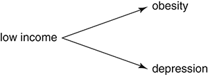

3.因果图描绘了低收入是肥胖和抑郁症共同原因的假设。

3. Causal graph depicting the hypothesis that low income is a common cause of both obesity and depression.

我们如何检验低收入会导致肥胖和抑郁的假设呢？最直接的方法是找到一个*收入水平相同的*个体样本，然后进行考察。样本中肥胖与抑郁症是否存在相关性。如果我们针对不同的收入水平进行分析，发现每个收入水平相同的样本中，肥胖与抑郁症的相关性都消失了，这便是支持共同原因假说的有力证据。因为这表明，一旦将收入因素考虑在内，肥胖就不再与抑郁症相关。相反，如果即使在收入水平相同的人群中，肥胖与抑郁症之间也存在很强的相关性，这便是反对共同原因假说的证据。在统计学中，这个过程被称为“控制”收入变量。

How could we test the hypothesis that low income causes both obesity and depression? The obvious thing to do is to find a sample of individuals *all with the same income level*, and examine whether obesity and depression are correlated within the sample. If we do this for a number of different income levels, and find that within each income-homogeneous sample the correlation disappears, this is strong evidence in favour of the common cause hypothesis. For it shows that once income is taken into account, obesity is no longer associated with depression. Conversely, if a strong obesity–depression correlation exists even among individuals with the same income level, this is evidence against the common cause hypothesis. In statistical jargon, this procedure is known as ‘controlling for’ the variable income.

这里的基本逻辑与现代科学的支柱——对照实验类似。假设一位昆虫学家想要检验“在较高温度下饲养昆虫幼虫会导致成虫体型减小”这一假设。为了验证这一假设，昆虫学家会获取大量的昆虫幼虫，一部分在低温下饲养，另一部分在高温下饲养，然后测量最终成虫的体型。为了有效地检验这一因果假设，除了温度之外，两组幼虫之间所有其他因素都必须尽可能保持一致。例如，所有幼虫都应该来自同一物种，性别相同，并且喂食相同的食物。因此，昆虫学家必须精心设计实验，控制所有可能影响成虫体型的变量。只有这样，才能将两组成虫体型的差异可靠地归因于温度差异。

The underlying logic here is similar to that of the controlled experiment, a mainstay of modern science. Suppose an entomologist wishes to test the hypothesis that rearing insect larvae at higher temperatures leads to reduced adult body size. To test this, the entomologist gets a large number of insect larvae, rears some at a cool and others at a warm temperature, then measures the size of the resulting adults. For this to be an effective test of the causal hypothesis, it is important that all factors other than temperature be held constant between the two groups, so far as possible. For example, the larvae should all be from the same species, the same sex, and be fed the same food. So the entomologist must design their experiment carefully, controlling for all variables that could potentially affect adult body size. Only then can a difference in adult body size between the two groups safely be attributed to the temperature difference.

有时有人认为，控制实验是科学中进行因果推断的唯一可靠方法。持这种观点的人认为，纯粹的观察数据，没有任何实验干预，无法让我们了解因果关系。然而，这是一个颇具争议的论点。因为尽管控制实验无疑是探索自然奥秘的好方法，但统计控制技术通常也能达到类似的效果。近年来，统计学家和计算机科学家已经开发出强大的统计控制技术。从观察数据中进行因果推断。实验数据和观察数据在方法论上是否存在根本差异，以及这种差异是否会影响从中得出的因果推断的可靠性，这是一个持续争论的问题。

It is sometimes argued that controlled experiments are the only reliable way of making causal inferences in science. Proponents of this view argue that purely observational data, without any experimental intervention, cannot give us knowledge of causality. However this is a controversial thesis. For while controlled experimentation is certainly a good way of probing nature’s secrets, the technique of statistical control can often accomplish something quite similar. In recent years, statisticians and computer scientists have developed powerful techniques for making causal inferences from observational data. Whether there is a fundamental methodological difference between experimental and observational data, vis-à-vis the reliability of the causal inferences that can be drawn from them, is a matter of continuing debate.

在现代生物医学中，一种特殊的对照实验常常备受重视。这就是*随机对照试验*（RCT），它最初由R.A. Fisher在20世纪30年代提出，常用于检验新药的疗效。在典型的RCT中，患有特定疾病（例如严重偏头痛）的患者被分为两组。治疗组接受药物治疗，而对照组则不接受。研究人员随后比较两组患者在特定结局指标（例如偏头痛症状缓解情况）上的差异。如果治疗组患者的疗效显著优于对照组，则可初步证明该药物有效。RCT的关键在于，患者最初的分组必须是随机的*。Fisher*及其现代追随者认为，这是维持有效因果推断的必要条件。

In modern biomedical science, a particular sort of controlled experiment is often given particular prominence. This is the *randomized controlled trial* (RCT), originally devised by R. A. Fisher in the 1930s, and often used to test the effectiveness of a new drug. In a typical RCT, patients with a particular medical condition, e.g. severe migraine, are divided into two groups. Those in the treatment group receive the drug, while those in the control group do not. The researchers then compare the two groups on the outcome of interest, e.g. relief of migraine symptoms. If those in the treatment group do significantly better than the control group, this is presumptive evidence that the drug works. The key feature of an RCT is that the initial division of the patients into two groups must be done at *random*. Fisher and his modern followers argue that this is necessary to sustain a valid causal inference.

为什么随机化如此重要？因为它有助于消除混杂因素对目标结果的影响。通常，结果会受到多种因素的影响，例如年龄、饮食和运动。除非所有这些因素都已知，否则研究人员无法对其进行明确控制。然而，通过将患者随机分配到治疗组和对照组，可以很大程度上规避这个问题。即使药物以外的其他因素确实会影响结果，随机化也能确保这些因素不太可能在治疗组或对照组中过度代表。因此，如果治疗组和对照组的结果存在显著差异，则很可能是由药物引起的。当然，这并不能严格*证明*药物是因果关系，但它构成了强有力的证据。

Why is randomization so important? Because it helps to eliminate the effect of confounding factors on the outcome of interest. Typically the outcome will be affected by many factors, e.g. age, diet, and exercise. Unless all of these factors are known, the researcher cannot explicitly control for them. However by randomly allocating patients to the treatment and control groups, this problem can be largely circumvented. Even if factors other than the drug do affect the outcome, randomization ensures that any such factors are unlikely to be over-represented in either the treatment or the control group. So if there is a significant difference in outcome between treatment and control groups, this is very likely due to the drug. Of course this does not strictly *prove* that the drug was causally responsible, but it constitutes strong evidence.

在医学领域，随机对照试验（RCT）通常被视为评估因果关系的“黄金标准”。事实上，“循证医学”运动的支持者常常认为，*只有*RCT才能告诉我们某种特定疗法是否具有因果效力。然而，这种观点或许过于绝对（而且将“证据”一词仅用于指代RCT也具有误导性）。在许多科学领域，由于实际或伦理方面的原因，RCT难以实施，但人们仍然经常进行因果推断。此外，我们日常生活中许多关于因果关系的知识并非来自RCT。例如，幼儿知道把手伸进火里会感到灼痛；这无需任何随机试验就能证实。虽然RCT固然重要，并且在可行的情况下应该进行，但这并不意味着它是发现因果关系的唯一途径。

In medicine, the RCT is usually regarded as the ‘gold standard’ for assessing causality. Indeed proponents of the movement known as ‘evidence-based medicine’ often argue that *only* an RCT can tell us when a particular treatment is causally effective. However this position is arguably too strong (and the appropriation of the word ‘evidence’ to refer only to RCTs is misleading). In many areas of science, RCTs are not feasible, for either practical or ethical reasons, and yet causal inferences are routinely made. Furthermore, much of the causal knowledge we have in everyday life we gained without RCTs. Young children know that putting their hand in the fire causes a painful burning sensation; no randomized trial was needed to establish this. While RCTs are certainly important, and should be done when feasible, it is not true that they are the only way of discovering causality.

# 概率与科学推断

# Probability and scientific inference

鉴于归纳推理无法提供确定性，我们自然会希望概率的概念能够帮助我们理解其运作方式。即使科学家的证据不能证明其假设是正确的，难道就不能使其具有很高的可能性吗？在探讨这一观点之前，我们需要简要了解一下概率的概念本身。

Given that inductive reasoning cannot give us certainty, it is natural to hope that the concept of probability will help us understand how it works. Even if a scientist’s evidence does not prove that their hypothesis is true, surely it can render it highly probable? Before exploring this idea we need to attend briefly to the concept of probability itself.

概率既有客观层面，也有主观层面。客观而言，概率指的是世界上事物发生的频率，或者说事物发生的倾向。例如，如果有人告诉你，一位英国女性活到90岁的概率是十分之一，你会理解为十分之一的英国女性能活到90岁。同样，对于“抛硬币正面朝上的概率是二分之一”这句话，自然的理解是，在一系列抛硬币中，正面朝上的比例非常接近二分之一。从这个角度理解，关于概率的陈述是客观的真或假，与个人的主观感受无关。

Probability has both an objective and a subjective guise. In its objective guise, probability refers to how often things in the world happen, or tend to happen. For example, if you are told that the probability of an Englishwoman living to age 90 is one in ten, you would understand this as meaning that one-tenth of all Englishwomen attain that age. Similarly, a natural understanding of the statement ‘the probability that the coin will land heads is a half’ is that in a long sequence of coin flips, the proportion of heads would be very close to a half. Understood this way, statements about probability are objectively true or false, independently of what anyone believes.

从主观角度来看，概率是理性信念程度的衡量标准。假设一位科学家告诉你，在火星上发现生命的概率极低。这是否意味着只有极少数天体存在生命？当然不是。首先，没有人知道天体的数量，也不知道其中有多少天体存在生命。因此，这里涉及的是另一种概率概念。既然火星上要么存在生命，要么不存在生命，那么在这种情况下谈论概率，必然反映的是我们对世界现状的无知，而不是对世界本身客观特征的描述。所以，很自然地，我们可以将这位科学家的说法理解为：根据所有证据，人们对“火星上存在生命”这一假设的理性信念程度非常低。

In its subjective guise, probability is a measure of rational degree of belief. Suppose a scientist tells you that the probability of finding life on Mars is extremely low. Does this mean that life is found on only a small proportion of all the celestial bodies? Surely not. For one thing, no one knows how many celestial bodies there are, nor how many of them contain life. So a different notion of probability is at work here. Now since there either is life on Mars or there isn’t, talk of probability in this context must presumably reflect our ignorance of the state of the world, rather than describing an objective feature of the world itself. So it is natural to take the scientist’s statement to mean that in the light of all the evidence, the rational degree of belief to have in the hypothesis that there is life on Mars is very low.

在现有证据的基础上，对某个科学假设的理性信念程度可以被视为一种概率，这种观点为科学推理的运作方式提供了一种自然的解释。假设一位科学家正在考虑一个特定的假设*H。*根据目前的证据，这位科学家对*H*有一定的信念程度，记为*P* ( *H)，*这是一个介于 0 和 1 之间的数值。（*P* ( *H* ) 的另一个名称是科学家对*H*的“信心” 。）随后出现了一些新的证据，例如来自实验或观察的证据。根据这些新证据，科学家将他们对*H*的信心更新为*Pnew* ( *H* )。如果新证据支持该理论，那么*Pnew* ( *H* ) 将大于*P* ( *H* )，也就是说，科学家将更加确信*H*是正确的。

The idea that the rational degree of belief to have in a scientific hypothesis, given the evidence, may be viewed as a type of probability suggests a natural picture of how scientific inference works. Suppose a scientist is considering a particular hypothesis *H*. In the light of the evidence to date, the scientist has a certain degree of belief in *H*, denoted *P*(*H),* which is a number between zero and one. (Another name for *P*(*H*) is the scientist’s ‘credence’ in *H*.) Some new evidence then comes to light, e.g. from experiment or observation. In the light of this new evidence, the scientist updates their credence in *H* to *Pnew*(*H*). If the new evidence supports the theory, then *Pnew*(*H*) will be greater than *P*(*H*), i.e. the scientist will have become more confident that *H* is true.

A toy example will help flesh this out. Suppose a playing card has been drawn from a well-shuffled pack and is concealed from your view. Let *H* be the hypothesis that the card is the queen of hearts. What is the value of *P*(*H*), i.e. your initial rational credence in *H*? Presumably it is 1/52. For there are fifty-two cards in the pack and they are all equally likely to be chosen. Suppose you then learn that the chosen card is definitely a heart. Call this piece of information *e*. In the light of *e*, what is the value of *Pnew*(*H*), i.e. your updated credence in *H* given the new evidence? Clearly, *Pnew*(*H*) should equal 1/13—for there are thirteen hearts in the pack and you know that the concealed card is one of them. So learning *e* has increased your credence in *H* from 1/52 to 1/13.

This is all fairly obvious, but what is the general rule for updating your credence in the light of new information? The answer is called ‘conditionalization’. To grasp this rule we need the concept of conditional probability. In the card example, *P*(*H*) is your initial credence in hypothesis *H*. Your initial credence in *H* conditional on the assumption that *e* is true is denoted *P*(*H*/*e*). (Read this as ‘the probability of *H* given *e*’.) What is the value of *P*(*H*/*e*)? The answer is 1/13. For on the assumption that *e* is true, i.e. that the card drawn is a heart, your credence in the hypothesis *H* equals 1/13. When you learn that *e is* actually true, your new credence in *H*, i.e. *P<sub>n</sub>**<sub>ew</sub>*(*H*), should then be set equal to your initial credence in *H* conditional on *e*, according to the rule of conditionalization.

# 条件化规则

# Rule of conditionalization

得知证据*e 后，P* *<sub>new</sub>**<sub>(</sub>* H *)*应等于*P* ( *H* / *e* )。

Upon learning evidence *e, P<sub>n</sub>**<sub>ew</sub>*(*H*) should equal *P*(*H*/*e*).

为了更好地理解条件化规则，请注意，条件概率*P* ( *H* / *e* ) 根据定义等于*P* ( *H*且*e* )/ *P* ( *e* )。在纸牌示例中，*P* ( *H*且*e* ) 表示你最初认为*H*和*e*都为真的概率。但由于在这种情况下*H*逻辑蕴含*e——*因为如果这张牌是红桃皇后，那么它一定是红桃——因此*P* ( *H*且*e* ) 等于*P* ( *H* )，即 1/52。那么*P* ( *e* ) 呢？这是你最初认为所选牌是红桃的概率。由于牌组中恰好有四分之一的牌是红桃，并且你认为所有牌成为所选牌的概率均等，因此*P* ( *e ) 等于 1/4。应用**P* ( *H* / *e* )的定义，这告诉我们*P* ( *H* / *e* ) 等于 1/52 除以 1/4，即 1/13——与我们之前计算的答案相同。

To better understand the rule of conditionalization, note that the conditional probability *P*(*H*/*e*) is by definition equal to the ratio *P*(*H* and *e*)/*P*(*e*). In the card example, *P*(*H* and *e*) denotes your initial credence that both *H* and *e* are true. But since in this case *H* logically entails *e*—for if the card is the queen of hearts then it must be a heart—it follows that *P*(*H* and *e*) is simply equal to *P*(*H*), i.e. 1/52. What about *P*(*e*)? This is your initial credence that the chosen card is a heart. Since exactly one quarter of the cards in the deck are hearts, and you regard all the cards as equally likely to be the chosen one, it follows that *P*(*e*) is ¼. Applying the definition of *P*(*H*/*e*), this tells us that *P*(*H*/*e*) equals 1/52 divided by ¼, which is 1/13—the same answer as we computed previously.

条件化规则听起来可能很复杂，但就像许多逻辑规则一样，我们常常不假思索地遵循它。在卡片例子中，直觉上很明显，学习*e*应该会将你对*H*的理性信念从1/52提高到1/13，而实际上，大多数人也正是这样做的。这样做，即使他们从未听说过条件化规则，也无意识地遵循了它。除了这些隐性应用之外，条件化规则也经常被科学家显式地使用，例如在某些统计推理中。贝叶斯统计学这一统计学分支广泛运用条件化更新。（“贝叶斯”这个名称源于17世纪英国牧师托马斯·贝叶斯，他是概率论的早期先驱，也是条件化规则的发现者。）

The rule of conditionalization may sound complicated, but like many logical rules we often obey it without thinking. In the card example, it is intuitively obvious that learning *e* should increase your rational credence in *H* from 1/52 to 1/13, and in practice this is exactly what most people would do. In doing so, they are implicitly obeying the rule of conditionalization even if they have never heard of it. In addition to its implicit uses, the conditionalization rule is often used explicitly by scientists, for example in certain sorts of statistical reasoning. The branch of statistics known as Bayesian statistics makes extensive use of updating by conditionalization. (The name ‘Bayesian’ refers to the 17th-century English clergyman Thomas Bayes, an early pioneer of probability theory, who discovered the conditionalization rule.)

一些科学哲学家希望将条件化更新作为科学推理的通用模型，甚至适用于那些并非明确基于概率的推理。其核心思想是，任何理性科学家都可以被认为对其理论或假设抱有一定的初始信念，然后根据新的证据，遵循条件化规则对其进行更新。即便科学家的实际推理过程与此截然不同，这些哲学家认为这仍然是一种有用的理想化模型。

Some philosophers of science wish to use updating by conditionalization as a general model for scientific inference, applicable even to inferences that are not explicitly probabilistic. The idea is that any rational scientist can be thought of as having an initial credence in their theory or hypothesis, which they then update in the light of new evidence by following the rule of conditionalization. Even if the scientist’s conscious reasoning process looks nothing like this, it is a useful idealization according to these philosophers.

这种“贝叶斯式”的科学推理观点颇具吸引力，因为它阐明了科学方法的某些方面。试想一下，当一个科学理论做出可检验的预测，并且最终被证实为真时，这通常被视为支持该理论的证据。在第一章中，我们举了爱因斯坦广义相对论的例子：该理论预测星光会受到太阳引力场的偏转；当这一预测得到证实后，科学家们对爱因斯坦理论的信心增强了。但是，既然总会有其他无法排除的可能解释，为什么一个成功的预测会增强科学家对某个理论的信心呢？这仅仅是科学家推理方式的一个简单事实，还是背后有着更深层次的解释？

This ‘Bayesian’ view of scientific inference is quite attractive, as it sheds light on certain aspects of the scientific method. Consider the fact that when a scientific theory makes a testable prediction that turns out to be true, this is usually taken as evidence in favour of the theory. In Chapter 1 we had the example of Einstein’s theory of general relativity predicting that starlight would be deflected by the sun’s gravitational field; when this prediction was confirmed it increased scientists’ confidence in Einstein’s theory. But why should a successful prediction enhance a scientist’s confidence in a theory, given that there will always be other possible explanations that can’t be ruled out? Is this simply a brute fact about how scientists reason, or does it have a deeper explanation?

贝叶斯主义者认为这确实有更深层次的解释。假设一个理论*T*蕴含一个可检验的命题*e*。科学家最初对*T*为真和*e为真分别抱有**P* ( *T* )和*P* ( *e* )的置信度。我们假设*P* ( *T* ) 和*P* ( *e* ) 都取非极端值，即不为零或一。假设科学家随后得知*e*确为真。如果他们遵循条件化规则，那么根据逻辑，他们对理论*T 的新置信度，*即*Pnew* ( *T* )，必然大于*P* ( *T* )。换句话说，只要科学家遵循条件化规则，当他们得知自己的理论做出了正确的预测时，他们必然会增强对该理论的信心。因此，在贝叶斯科学推理的观点下，成功预测通常会使科学家对自己的理论更有信心这一事实可以得到一个简洁的解释。

Bayesians argue that it does indeed have a deeper explanation. Suppose that a theory *T* entails a testable statement *e*. The scientist initially has credence *P*(*T*) that *T* is true and *P*(*e*) that *e* is true. We assume that both *P*(*T*) and *P*(*e*) take non-extreme values, i.e. are not zero or one. Suppose the scientist then learns that *e* is definitely true. If they follow the rule of conditionalization, their new credence in theory *T,* i.e. *Pnew*(*T*), must then be greater than *P*(*T*) as a matter of logic. In other words, upon learning that their theory has made a true prediction, a scientist will necessarily increase their confidence in the theory so long as they obey the conditionalization rule. So the fact that successful predictions typically lead scientists to become more confident of their theories has a neat explanation, on the Bayesian view of scientific inference.

然而，贝叶斯观点也有其局限性。许多有趣的科学推论都涉及提出前所未有的理论或假设。哥白尼、牛顿和达尔文的伟大科学成就都属于此类。他们各自提出了前人从未考虑过的新理论。引导他们得出这些理论的推理过程显然不能被视为贝叶斯推理。因为条件化描述的是，当科学家获得新的证据时，他们对某个理论的理性信念应该如何改变；这预设了该理论此前已被提出。因此，从数据推导出全新理论的科学推论不能用条件化来理解。

However the Bayesian view has its limitations. Much interesting scientific inference involves inventing theories or hypotheses that have never been thought of before. The great scientific advances made by Copernicus, Newton, and Darwin were all of this sort. Each of these scientists came up with a new theory which their predecessors had never entertained. The reasoning that led them to these theories cannot plausibly be regarded as Bayesian. For conditionalization describes how a scientist’s rational credence in a theory should change when they get new evidence; this presumes that the theory has already been thought of. So scientific inferences that go from data to completely new theory cannot be understood in terms of conditionalization.

贝叶斯观点的另一个局限性在于，在获得新证据之前，初始信念的来源是什么。在扑克牌的例子中，你最初理性地认为选中的牌是红桃皇后，这很容易确定，因为一副牌有52张，每张牌被选中的概率均等。但许多科学假设并非如此。例如，假设到2100年全球变暖将超过4摄氏度。在获得任何相关证据之前，科学家对这个假设的初始信念应该是什么？这个问题的答案显而易见。一些贝叶斯科学哲学家认为，初始信念完全是主观的，也就是说，它们仅仅代表科学家对假设的“最佳猜测”，因此任何初始信念都与其他信念一样好。在这种贝叶斯观点下，科学家可以通过客观理性的方式，在获得新证据时*改变*他们的信念（即条件化），但对他们的初始信念应该是什么并没有客观的限制。

Another limitation of the Bayesian view concerns the source of the initial credences, prior to updating on the new evidence. In the card example, your initial rational credence that the chosen card was the queen of hearts was easy to determine, because there are fifty-two cards in a deck each with an equal chance of being chosen. But many scientific hypotheses are not like this. Consider the hypothesis that global warming will exceed four degrees by the year 2100. What should a scientist’s initial credence in this hypothesis, before getting any relevant evidence, be? There is no obvious answer to this question. Some Bayesian philosophers of science reply that initial credences are purely subjective, i.e. they simply represent a scientist’s ‘best guess’ about the hypothesis, so any initial credence is as good as any other. On this version of the Bayesian view, there is an objectively rational way for a scientist to *change* their credences when they get new evidence, i.e. conditionalization, but no objective constraint on what their initial credences should be.

许多哲学家认为这种主观维度的介入是不受欢迎的，因此他们得出结论：贝叶斯观点并非科学推理的全部。这也表明，休谟的归纳问题无法找到贝叶斯式的“解决方案”。认为我们可以借助概率来摆脱休谟问题的想法由来已久。即便太阳过去每天都升起并不能证明它明天也会升起，但这难道不意味着它明天升起的概率很高吗？这种对休谟问题的回应最终是否有效是一个复杂的问题，但我们可以得出以下结论：如果唯一的客观约束在于我们应该如何改变我们的信念，而我们最初的信念应该是什么则完全是主观的，那么那些对世界持有非常怪异观点的人也会被视为完全理性。因此，通过概率来摆脱休谟问题并不能从贝叶斯科学推理的观点中得出。

This intrusion of a subjective dimension is regarded as unwelcome by many philosophers, leading them to conclude that the Bayesian view cannot be the whole story about scientific inference. Also, it shows that there cannot be a Bayesian ‘solution’ to Hume’s problem of induction. The idea that we can somehow escape Hume’s problem by invoking probability is an old one. Even if the sun’s having risen every day in the past doesn’t prove that it will rise tomorrow, surely it makes it highly probable? Whether this response to Hume ultimately works is a complex matter, but we can say the following. If the only objective constraints concern how we should change our credences, but what our initial credences should be is entirely subjective, then individuals with very bizarre opinions about the world will count as perfectly rational. So a probabilistic escape from Hume’s problem will not fall out of the Bayesian view of scientific inference.

# 第三章

# Chapter 3

# 科学解释

# Explanation in science

科学的一个重要目标是尝试解释我们周围世界发生的一切。有时，我们寻求解释是为了实际目的。例如，我们可能想知道臭氧层为何损耗如此迅速，以便采取相应措施。而在其他情况下，我们寻求科学解释仅仅是为了满足我们的求知欲——我们想要更多地了解世界的运行方式。历史上，对科学解释的追求一直受到这两种目标的驱动。

One important aim of science is to try and explain what happens in the world around us. Sometimes we seek explanations for practical ends. For example, we might want to know why the ozone layer is being depleted so quickly in order to try and do something about it. In other cases we seek scientific explanations simply to satisfy our intellectual curiosity—we want to understand more about how the world works. Historically, the pursuit of scientific explanation has been motivated by both goals.

现代科学常常成功地提供解释。例如，化学家可以解释钠燃烧时为何会变成黄色；天文学家可以解释日食发生的时间；经济学家可以解释日元在20世纪80年代贬值的原因；遗传学家可以解释男性脱发为何具有家族遗传倾向；神经生理学家可以解释极度缺氧为何会导致脑损伤。你或许还能想到许多其他成功的科学解释的例子。

Quite often, modern science is successful in its aim of supplying explanations. For example, chemists can explain why sodium turns yellow when it burns. Astronomers can explain why solar eclipses occur when they do. Economists can explain why the yen declined in value in the 1980s. Geneticists can explain why male baldness tends to run in families. Neurophysiologists can explain why extreme oxygen deprivation leads to brain damage. You can probably think of many other examples of successful scientific explanations.

但究竟什么*是*科学解释？说某种现象可以用科学“解释”究竟意味着什么？自亚里士多德以来，这个问题就一直困扰着哲学家们，但我们的出发点将是德裔美籍哲学家在20世纪50年代提出的关于科学解释的著名论述。卡尔·亨佩尔。亨佩尔的解释被称为*覆盖律*模型，原因稍后会阐明。

But what exactly *is* a scientific explanation? What exactly does it mean to say that a phenomenon can be ‘explained’ by science? This is a question that has exercised philosophers since Aristotle, but our starting-point will be a famous account of scientific explanation put forward in the 1950s by the German-American philosopher Carl Hempel. Hempel’s account is known as the *covering law* model of explanation, for reasons that will become clear.

# 亨佩尔的覆盖定律解释模型

# Hempel’s covering law model of explanation

覆盖律模型的基本思想很简单。亨佩尔指出，科学解释通常是为了回应他所谓的“寻求解释的为什么问题”而给出的。这些问题包括“为什么地球不是完美的球形？”或“为什么女性比男性寿命更长？”——它们都是对解释的需求。因此，给出科学解释就是对寻求解释的为什么问题提供一个令人满意的答案。如果我们能够确定这种答案必须具备的基本特征，我们就能知道什么是科学解释。

The basic idea behind the covering law model is straightforward. Hempel noted that scientific explanations are usually given in response to what he called ‘explanation-seeking why-questions’. These are questions such as ‘why is the earth not perfectly spherical?’ or ‘why do women live longer than men?’—they are demands for explanation. To give a scientific explanation is thus to provide a satisfactory answer to an explanation-seeking why-question. If we could determine the essential features that such an answer must have, we would know what scientific explanation is.

*亨佩尔认为，科学解释通常具有论证*的逻辑结构，即一组前提后跟一个结论。结论表明需要解释的现象确实存在，而前提则告诉我们为什么结论是正确的。例如，假设有人问为什么糖会溶于水。这是一个寻求解释的“为什么”问题。亨佩尔指出，为了回答这个问题，我们必须构建一个论证，其结论是“糖溶于水”，而前提则告诉我们为什么这个结论是正确的。因此，阐述科学解释的任务就变成了精确地刻画一组前提与结论之间必须存在的关系，只有这样，前提才能构成对结论的解释。这就是亨佩尔给自己设定的问题。

Hempel suggested that scientific explanations typically have the logical structure of an *argument*, i.e. a set of premises followed by a conclusion. The conclusion states that the phenomenon which needs explaining occurs, and the premises tell us why the conclusion is true. Thus suppose someone asks why sugar dissolves in water. This is an explanation-seeking why-question. To answer it, says Hempel, we must construct an argument whose conclusion is ‘sugar dissolves in water’ and whose premises tell us why this conclusion is true. The task of providing an account of scientific explanation then becomes the task of characterizing precisely the relation that must hold between a set of premises and a conclusion, in order for the former to count as an explanation of the latter. That was the problem Hempel set himself.

亨佩尔对这个问题的解答有三点。首先，前提必须蕴含结论，也就是说，论证必须是演绎式的。其次，所有前提都必须为真。第三，前提必须至少包含一条普遍规律。普遍规律包括“所有金属都能导电”、“物体的加速度与其质量成反比”以及“所有植物都含有……”等。例如“叶绿素”；它们与“这块金属能导电”和“我桌上的植物含有叶绿素”等具体事实形成对比。普遍规律有时也被称为*自然规律*。亨佩尔认为，科学解释可以诉诸具体事实，也可以诉诸普遍规律，但他认为至少一条普遍规律是必不可少的。因此，按照亨佩尔的理念，解释一种现象就是证明它的出现可以从一条普遍规律中演绎得出，或许还可以辅以其他规律和/或具体事实，而所有这些都必须为真。

Hempel’s answer to the problem was threefold. First, the premises should entail the conclusion, i.e. the argument should be a deductive one. Secondly, the premises should all be true. Thirdly, the premises should consist of at least one general law. General laws are things such as ‘all metals conduct electricity’, ‘a body’s acceleration varies inversely with its mass’, and ‘all plants contain chlorophyll’; they contrast with particular facts such as ‘this piece of metal conducts electricity’ and ‘the plant on my desk contains chlorophyll’. General laws are sometimes called *laws of nature*. Hempel allowed that a scientific explanation could appeal to particular facts as well as general laws, but he held that at least one general law was always essential. So to explain a phenomenon, on Hempel’s conception, is to show that its occurrence follows deductively from a general law, perhaps supplemented by other laws and/or particular facts, all of which must be true.

举例来说，假设我要解释为什么我桌上的植物死了。我可能会这样解释：由于书房光线昏暗，阳光无法照射到植物；但阳光是植物进行光合作用的必要条件；没有光合作用，植物就无法合成生存所需的碳水化合物，最终会死亡；因此，我的植物死了。这个解释完全符合亨佩尔的模型。它通过两个真理——阳光是光合作用的必要条件，以及光合作用是植物生存的必要条件——和一个具体事实——植物没有获得阳光——来解释植物的死亡。鉴于这两个真理和这个具体事实，植物的死亡*是必然*发生的；这就是为什么前者能够很好地解释后者。

To illustrate, suppose I am trying to explain why the plant on my desk has died. I might offer the following explanation. Owing to the poor light in my study, no sunlight has been reaching the plant; but sunlight is necessary for a plant to photosynthesize; and without photosynthesis a plant cannot make the carbohydrates it needs to survive, and so will die; therefore my plant died. This explanation fits Hempel’s model exactly. It explains the death of the plant by deducing it from two true laws—that sunlight is necessary for photosynthesis, and that photosynthesis is necessary for survival—and one particular fact—that the plant was not getting any sunlight. Given the truth of the two laws and the particular fact, the death of the plant *had* to occur; that is why the former constitute a good explanation of the latter.

从示意图上看，亨佩尔的解释模型可以写成如下形式：

Schematically, Hempel’s model of explanation can be written as follows:

普通法

General Laws

具体事实

Particular Facts

⇒

⇒

待解释的现象

Phenomenon to be explained

需要解释的现象称为*被解释项（explanandum）*，而解释该现象的普遍规律和具体事实称为*解释项（explanans）*。*被解释项*可以是具体的，也可以是普遍的。在前面的例子中，它是一个具体事实——我的植物死了。但有时我们想要解释的事物是普遍性的。例如，我们可能想解释为什么日晒常常会导致皮肤癌。这本身就是一个普遍规律，而非具体事实。要解释它，我们需要从更基本的规律中推导出来——大概是关于辐射对皮肤细胞影响的规律，以及关于阳光中辐射量的具体事实。因此，无论*被解释项*（即我们试图解释的事物）是具体的还是普遍的，科学解释的结构本质上都是相同的。

The phenomenon to be explained is called the *explanandum*, and the general laws and particular facts that do the explaining are called the *explanans*. The *explanandum* may be either particular or general. In the previous example, it was a particular fact—the death of my plant. But sometimes the things we want to explain are general. For example, we might wish to explain why exposure to the sun often leads to skin cancer. This is itself a generality, not a particular fact. To explain it, we would need to deduce it from more fundamental laws—presumably, laws about the impact of radiation on skin cells, combined with particular facts about the amount of radiation in sunlight. So the structure of a scientific explanation is essentially the same whether the *explanandum*, i.e. thing we are trying to explain, is particular or general.

很容易理解“覆盖定律模型”名称的由来。根据该模型，解释的本质在于证明待解释的现象被某种普遍的自然定律所“覆盖”。这个想法确实很有吸引力。因为证明某种现象是普遍定律的结果，就能消除其神秘感，使其更容易理解。许多实际的科学解释也确实符合亨佩尔描述的模式。例如，牛顿解释了行星为何绕太阳做椭圆运动，他证明这可以从万有引力定律以及一些其他假设中推导出来。牛顿的解释与亨佩尔的模型完全吻合：通过证明在自然定律和一些其他事实的约束下，某种现象必然如此，就能解释该现象。牛顿之后，行星轨道为何是椭圆的这一问题就不再是谜了。

It is easy to see where the covering law model gets its name. For according to the model, the essence of explanation is to show that the phenomenon to be explained is ‘covered’ by some general law of nature. There is certainly something appealing about this idea. For showing that a phenomenon is a consequence of a general law takes the mystery out of it—it renders it more intelligible. And many actual scientific explanations do fit the pattern Hempel describes. For example, Newton explained why the planets move in ellipses around the sun by showing that this can be deduced from his law of universal gravitation, along with some minor additional assumptions. Newton’s explanation fits Hempel’s model exactly: a phenomenon is explained by showing that it had to be so, given the laws of nature plus some additional facts. After Newton, there was no longer any mystery about why planetary orbits are elliptical.

亨佩尔意识到并非所有科学解释都完全符合他的模型。例如，如果你问别人为什么雅典的雾霾近年来加剧，他们可能会回答“因为家庭燃木量增加”。这没错，而且是一个完全可以接受的科学解释，尽管它没有提及任何定律。但亨佩尔会说，如果解释得更详细一些，定律就会发挥作用。想必存在这样一条定律：如果一定区域内燃木烟雾排放量超过一定水平，且风力足够小，就会形成雾霾云。完整的解释……要解释雅典雾霾加剧的原因，可以引用这条法律，以及雅典燃木量增加和当地风力较弱的事实。实际上，除非我们过于吹毛求疵，否则不会如此详细地解释。但如果要解释，它与这条法律的适用模式非常吻合。

Hempel was aware that not all scientific explanations fit his model exactly. For example, if you ask someone why the smog in Athens has worsened in recent years they might reply ‘because of the increase in domestic wood-burning’. This is true, and is a perfectly acceptable scientific explanation, though it involves no mention of any laws. But Hempel would say that if the explanation were spelled out in full detail, laws would enter the picture. Presumably there is a law which says something like ‘if wood-smoke emissions exceed a certain level in an area of a given size, and if the wind is sufficiently light, smog clouds will form’. The full explanation of why the smog in Athens has worsened would cite this law, along with the fact that wood-burning in Athens has increased and that wind levels there are fairly low. In practice we wouldn’t spell out the explanation in this much detail unless we were being very pedantic. But if we were to spell it out, it would correspond quite well to the covering law pattern.

亨佩尔从他的模型中得出了一个关于解释和预测之间关系的有趣结论。他认为，这两者是同一枚硬币的两面。每当我们用一个涵盖性的定律来解释某种现象时，我们所引用的定律和具体事实，即便我们之前并不了解这种现象，也足以预测它的发生。举例来说，我们再次考虑牛顿对行星轨道为何是椭圆的解释。这个事实早在牛顿用万有引力理论解释它之前就已经为人所知——它是由开普勒发现的。但即便开普勒当时并不了解，牛顿也能够根据他的万有引力理论做出预测。亨佩尔用以下方式表达了这一点：每一个科学解释都可能是一种预测——即使我们之前并不了解这种现象，它也能用来预测它。亨佩尔认为，反过来也成立：每一个可靠的预测都可能是一种解释。举例来说，假设科学家根据栖息地破坏的信息预测山地大猩猩将在2030年灭绝。假设他们的预测最终被证实是正确的。亨佩尔认为，他们之前用来预测大猩猩灭绝的信息，在大猩猩灭绝之后也可以用来解释这一事实。解释和预测在结构上是对称的。

Hempel drew an interesting consequence from his model about the relation between explanation and prediction. He argued that these are two sides of the same coin. Whenever we give a covering law explanation of a phenomenon, the laws and particular facts we cite would have enabled us to predict the occurrence of the phenomenon, if we hadn’t already known about it. To illustrate, consider again Newton’s explanation of why planetary orbits are elliptical. This fact was known long before Newton explained it using his theory of gravity—it was discovered by Kepler. But had it not been known, Newton would have been able to predict it from his theory of gravity. Hempel expressed this by saying that every scientific explanation is potentially a prediction—it would have served to predict the phenomenon in question, had it not already been known. The converse is also true, Hempel thought: every reliable prediction is potentially an explanation. To illustrate, suppose scientists predict that mountain gorillas will be extinct by 2030, based on information about the destruction of their habitat. Suppose they turn out to be right. According to Hempel, the information they used to predict the gorillas’ extinction before it happened will serve to explain that same fact after it has happened. Explanation and prediction are structurally symmetric.

尽管覆盖律模型能够很好地捕捉许多实际科学解释的结构，但它也面临着一些棘手的反例。特别是，有些案例符合覆盖律模型，但直觉上却不能算作真正的科学解释。这些案例表明，亨佩尔的模型过于宽松——它允许纳入一些本应排除的因素。本文将重点讨论其中的两个案例。

Though the covering law model captures the structure of many actual scientific explanations quite well, it also faces a number of awkward counterexamples. In particular, there are cases that fit the covering law model but intuitively do not count as genuine scientific explanations. These cases suggest that Hempel’s model is too liberal—it allows in things that should be excluded. We focus on two such cases here.

# 情况（i）：对称性问题

# Case (i): the problem of symmetry

假设你在一个阳光明媚的日子里躺在沙滩上，你注意到一根旗杆在沙滩上投下了 20 米长的影子（见图4）。

Suppose you are lying on the beach on a sunny day, and you notice that a flagpole is casting a shadow of 20 metres across the sand (see Figure 4).

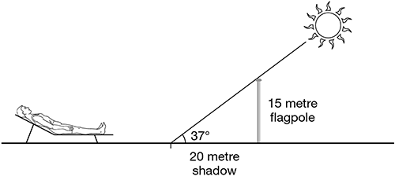

4.当太阳位于头顶正上方 37° 时，15 米高的旗杆会投下 20 米长的影子。

4. A 15-metre flagpole casts a shadow of 20 metres when the sun is 37° overhead.

有人问你为什么影子长20米。这是一个寻求解释的“为什么”的问题。一个合理的答案可能是这样的：“太阳光线照射到旗杆上，旗杆高15米。太阳的仰角为37°。由于光沿直线传播，简单的三角函数计算（tan 37° = 15/20）表明，旗杆会投射出20米长的影子。”

Someone asks you to explain why the shadow is 20 metres long. This is an explanation-seeking why-question. A plausible answer might go as follows: ‘light rays from the sun are hitting the flagpole, which is exactly 15 metres high. The angle of elevation of the sun is 37°. Since light travels in straight lines, a simple trigonometric calculation (tan 37° = 15/20) shows that the flagpole will cast a shadow 20 metres long.’

这看起来是一个完全合理的科学解释。通过按照亨佩尔的模式重写它，我们可以看到它符合覆盖律模型：

This looks like a perfectly good scientific explanation. And by rewriting it in accordance with Hempel’s schema, we can see that it fits the covering law model:

| 一般法律 | 光沿直线传播 |
| --- | --- |
|  | 三角函数定律 |
| 具体事实 | 太阳仰角为37° |
|  | 旗杆高15米 |
| 待解释的现象 | 影子长20米 |

影子的长度可以根据旗杆的高度、太阳的仰角、光沿直线传播的光学定律以及三角函数定律推导得出。由于这些定律成立，且旗杆的高度确实是 15 米，因此该解释完全满足亨佩尔的要求。到目前为止一切顺利。问题如下：假设我们将被*解释项*——影子的长度为 20 米——替换为旗杆的高度为 15 米。结果如下：

The length of the shadow is deduced from the height of the flagpole and the angle of elevation of the sun, along with the optical law that light travels in straight lines and the laws of trigonometry. Since these laws are true, and since the flagpole is indeed 15 metres high, the explanation satisfies Hempel’s requirements precisely. So far so good. The problem arises as follows. Suppose we swap the *explanandum*—that the shadow is 20 metres long—with the particular fact that the flagpole is 15 metres high. The result is this:

| 一般法律 | 光沿直线传播 |
| --- | --- |
|  | 三角函数定律 |
| 具体事实 | 太阳仰角为37° |
|  | 影子长20米 |
| 待解释的现象 | 旗杆高15米 |

这种“解释”显然也符合遮蔽定律的模式。旗杆的高度是根据其投射的影子长度、太阳的仰角、光沿直线传播的光学定律以及三角函数定律推导出来的。但将此视为旗杆为何15米高的*解释*似乎非常奇怪。旗杆为何15米高的真正解释大概是木匠故意设计的——这与它投射的影子长度毫无关系。因此，亨佩尔的模型过于宽泛：它允许将一些显然并非科学解释的东西视为科学解释。

This ‘explanation’ clearly conforms to the covering law pattern too. The height of the flagpole is deduced from the length of the shadow it casts and the angle of elevation of the sun, along with the optical law that light travels in straight lines and the laws of trigonometry. But it seems very odd to regard this as an *explanation* of why the flagpole is 15 metres high. The real explanation of why the flagpole is 15 metres high is presumably that a carpenter deliberately made it so—it has nothing to do with the length of the shadow that it casts. So Hempel’s model is too liberal: it allows something to count as a scientific explanation which obviously is not.

旗杆的例子所蕴含的普遍寓意是，解释的概念本身就存在重要的不对称性。在给定相关规律和其他事实的情况下，旗杆的高度可以解释影子的长度，但反之则不然。一般来说，如果给定相关规律和其他事实， *x*可以解释*y ，那么在相同的规律和事实下，* *y*就不能解释*x*。这有时被表述为解释是一种不对称关系。亨佩尔的覆盖律模型并非如此。尊重这种不对称性。正如我们可以根据定律和其他事实，从旗杆的高度推导出影子的长度一样，我们也可以根据影子的长度推导出旗杆的高度。因此，亨佩尔的模型未能充分体现科学解释的本质，因为它暗示解释应该是一种对称关系，而实际上它是不对称的。

The general moral of the flagpole example is that the concept of explanation exhibits an important asymmetry. The height of the flagpole explains the length of the shadow, given the relevant laws and additional facts, but not vice versa. In general, if *x* explains *y*, given the relevant laws and additional facts, then it will not be true that *y* explains *x*, given the same laws and facts. This is sometimes expressed by saying that explanation is an asymmetric relation. Hempel’s covering law model does not respect this asymmetry. For just as we can deduce the length of the shadow from the height of the flagpole, given the laws and additional facts, so we can deduce the height of the flagpole from the length of the shadow. So Hempel’s model fails to capture fully what it is to be a scientific explanation, for it implies that explanation should be a symmetric relation when in fact it is asymmetric.

影子和旗杆的例子也反驳了亨佩尔关于解释和预测是同一枚硬币两面的论点。原因显而易见。假设你不知道旗杆有多高。如果有人告诉你旗杆的影子长20米，太阳位于头顶正上方37°，那么只要你掌握相关的光学和三角学定律，就能*预测出*旗杆的高度。但正如我们刚才看到的，这些信息显然无法*解释*旗杆为什么是这个高度。因此，在这个例子中，预测和解释分道扬镳。在我们知道某个事实之前可以用来预测它的信息，在我们知道这个事实之后却不能用来解释它，这与亨佩尔的论点相矛盾。

The shadow and flagpole case also provides a counterexample to Hempel’s thesis that explanation and prediction are two sides of the same coin. The reason is obvious. Suppose you didn’t know how high the flagpole was. If someone told you that it was casting a shadow of 20 metres and that the sun was 37° overhead, you would be able to *predict* the flagpole’s height, given that you knew the relevant optical and trigonometrical laws. But as we have just seen, this information clearly doesn’t *explain* why the flagpole has the height it does. So in this example prediction and explanation part ways. Information that serves to predict a fact before we know it does not serve to explain that same fact after we know it, which contradicts Hempel’s thesis.

# 案例（二）：无关性问题

# Case (ii): the problem of irrelevance

假设一个小孩在医院的产科病房里。他注意到房间里有一个人——名叫约翰——没有怀孕，便问医生为什么。医生回答说：“约翰过去几年一直在定期服用避孕药。定期服用避孕药的人是不会怀孕的。所以，约翰没有怀孕。” 假设医生说的是真的——约翰患有精神疾病，确实在服用避孕药，而且他认为避孕药对他有帮助。即便如此，医生的回答显然对小孩没有帮助。约翰没有怀孕的正确解释显然是：他是男性，而男性不可能怀孕。

Suppose a young child is in a maternity ward in a hospital. The child notices that one person in the room—who is a man called John—is not pregnant, and asks the doctor why not. The doctor replies: ‘John has been taking birth control pills regularly for the last few years. People who take birth control pills regularly never become pregnant. Therefore, John has not become pregnant.’ Let us suppose that what the doctor says is true—John is mentally ill and does indeed take birth control pills, which he believes help him. Even so, the doctor’s reply to the child is clearly not helpful. The correct explanation of why John has not become pregnant, obviously, is that he is male and males cannot become pregnant.

然而，医生的解释完全符合覆盖律模型。医生从服用避孕药的人不会怀孕这一普遍规律以及约翰一直在服用避孕药这一特殊事实推断出需要解释的现象——约翰没有怀孕。由于普遍规律和特殊事实都为真，并且它们确实蕴含了被*解释项*，根据覆盖律模型，医生已经解释了约翰为什么没有怀孕。但实际上，他并没有解释清楚。

However, the explanation the doctor has given fits the covering law model exactly. The doctor deduces the phenomenon to be explained—that John is not pregnant—from the general law that people who take birth control pills do not become pregnant and the particular fact that John has been taking birth control pills. Since both the general law and the particular fact are true, and since they do entail the *explanandum*, according to the covering law model the doctor has given an explanation of why John is not pregnant. But of course he hasn’t.

总的来说，对某种现象的良好解释应该包含与该现象发生*相关*的信息。医生对孩子的回答恰恰错在这一点上。虽然医生告诉孩子的话完全正确，但约翰服用避孕药与他没有怀孕无关，因为即使他没有服用避孕药，他也不会怀孕。这就是为什么医生的回答不能算作对孩子问题的合理解答。亨佩尔的模型忽略了我们解释概念中这一关键特征。

The general moral is that a good explanation of a phenomenon should contain information that is *relevant* to the phenomenon’s occurrence. This is where the doctor’s reply to the child goes wrong. Although what the doctor tells the child is perfectly true, the fact that John has been taking birth control pills is irrelevant to his not being pregnant, because he wouldn’t have been pregnant even if he hadn’t taken been taking the pills. This is why the doctor’s reply does not constitute a good answer to the child’s question. Hempel’s model does not respect this crucial feature of our concept of explanation.

# 解释与因果关系

# Explanation and causality

由于覆盖律模型存在问题，人们自然会寻求理解科学解释的替代方法。一些哲学家认为，关键在于*因果关系*的概念。这确实是一个颇具吸引力的观点。因为在许多情况下，解释一种现象实际上就是说明其原因。例如，如果事故调查员试图解释一起飞机坠毁事故，他们显然是在寻找事故的原因。事实上，“飞机为什么会坠毁？”和“飞机坠毁的原因是什么？”这两个问题几乎是同义的。同样，如果生态学家试图解释为什么热带雨林的生物多样性不如以往，他们也是在寻找生物多样性减少的原因。解释和因果关系这两个概念之间的联系非常紧密。

Since the covering law model encounters problems, it is natural to look for an alternative way of understanding scientific explanation. Some philosophers believe that the key lies in the concept of *causality*. This is quite an attractive suggestion. For in many cases to explain a phenomenon is indeed to say what caused it. For example, if an accident investigator is trying to explain an aeroplane crash, they are obviously looking for the cause of the crash. Indeed the questions ‘why did the plane crash?’ and ‘what was the cause of the plane crash?’ are practically synonymous. Similarly, if an ecologist is trying to explain why there is less biodiversity in the tropical rainforests than there used to be, they are looking for the cause of the reduction in biodiversity. The link between the concepts of explanation and causality is quite intimate.

受此联系的启发，许多哲学家放弃了覆盖律解释，转而采用基于因果关系的解释。具体细节各有不同，但这些解释背后的基本思想是：解释一个现象就是说明它的原因。在某些情况下，覆盖律解释和因果解释之间的区别其实并不大，因为从普遍规律推导出现象的发生通常就等于*给出*了它的原因。例如，我们不妨再回顾一下牛顿对行星轨道为何呈椭圆形的解释。我们看到，这种解释符合覆盖律模型——因为牛顿从万有引力定律以及一些其他事实推导出了行星轨道的形状。但牛顿的解释也是一种因果解释，因为行星的椭圆轨道是由行星和太阳之间的引力作用*造成的。*

Impressed by this link, a number of philosophers have abandoned the covering law account of explanation in favour of causality-based accounts. The details vary, but the basic idea behind these accounts is that to explain a phenomenon is simply to say what caused it. In some cases, the difference between the covering law and causal accounts is not actually very great, for to deduce the occurrence of a phenomenon from a general law often just *is* to give its cause. For example, recall again Newton’s explanation of why planetary orbits are elliptical. We saw that this explanation fits the covering law model—for Newton deduced the shape of the planetary orbits from his law of gravity, plus some additional facts. But Newton’s explanation was also a causal one, since elliptical planetary orbits are *caused* by the gravitational attraction between planets and the sun.

然而，覆盖律和因果解释并非完全等价——在某些情况下，它们甚至会相悖。事实上，许多哲学家之所以倾向于用因果解释，正是因为他们认为因果解释可以避免覆盖律模型面临的一些问题。回想一下旗杆问题。根据覆盖律，为什么我们的直觉告诉我们旗杆的高度可以解释影子的长度，而反之则不然？合理的解释是，旗杆的高度是影子长20米的*原因*，但影子长20米并不是旗杆高15米的原因。因此，与覆盖律模型不同，因果解释在旗杆问题上给出了“正确”的答案——它尊重了我们的直觉，即我们不能通过指出影子的长度来解释旗杆的高度。

However the covering law and causal accounts are not fully equivalent—in some cases they diverge. Indeed, many philosophers favour a causal account of explanation precisely because they think it can avoid some of the problems facing the covering law model. Recall the flagpole problem. Why do our intuitions tell us that the height of the flagpole explains the length of the shadow, given the laws, but not vice versa? Plausibly, because the height of the flagpole is the *cause* of the shadow being 20 metres long, but the shadow being 20 metres long is not the cause of the flagpole being 15 metres high. So unlike the covering law model, a causal account of explanation gives the ‘right’ answer in the flagpole case—it respects our intuition that we cannot explain the height of the flagpole by pointing to the length of the shadow it casts.

旗杆问题的总体寓意在于，覆盖律模型无法解释解释是一种不对称关系这一事实。显然，因果关系也是一种不对称关系：如果*x是**y*的原因，那么*y就不是**x*的原因。例如，如果短路导致了火灾，那么火灾显然不是短路的原因。因此，很自然地会认为，解释的不对称性源于因果关系的不对称性。因果关系。如果解释一个现象就是说明是什么导致了它，那么既然因果关系是不对称的，我们就应该预期解释也是不对称的——事实也的确如此。覆盖律模型之所以会遇到“旗杆问题”，正是因为它试图在不考虑因果关系的情况下分析科学解释的概念。

The general moral of the flagpole problem was that the covering law model cannot accommodate the fact that explanation is an asymmetric relation. Now causality is obviously an asymmetric relation too: if *x* is the cause of *y*, then *y* is not the cause of *x*. For example, if the short-circuit caused the fire, then the fire clearly did not cause the short-circuit. It is therefore natural to suggest that the asymmetry of explanation derives from the asymmetry of causality. If to explain a phenomenon is to say what caused it, then since causality is asymmetric we should expect explanation to be asymmetric too—as it is. The covering law model runs up against the flagpole problem precisely because it tries to analyse the concept of scientific explanation without reference to causality.

避孕药的例子也是如此。约翰服用避孕药并不能解释他为什么没有怀孕，因为避孕药并非他没有怀孕的*原因*。相反，约翰的性别才是他没有怀孕的原因。这就是为什么我们认为“为什么约翰没有怀孕？”这个问题的正确答案是“因为他是男性，而男性不可能怀孕”，而不是医生的答案。因此，覆盖律模型之所以会陷入无关性问题，正是因为它没有明确要求科学解释能够指出我们想要解释的现象的根本原因。

The same is true of the birth control pill case. That John takes birth control pills does not explain why he isn’t pregnant, because the birth control pills are not the *cause* of his not being pregnant. Rather, John’s sex is the cause of his not being pregnant. That is why we think that the correct answer to the question ‘why is John not pregnant?’ is ‘because he is male, and males can’t become pregnant’, rather than the doctor’s answer. So the covering law model runs into the problem of irrelevance precisely because it does not explicitly require that a scientific explanation identify the cause of the phenomenon that we wish to explain.

批评亨佩尔未能重视因果关系与解释之间的紧密联系，这一点很容易理解，许多哲学家也曾这样做过。但在某种程度上，这种批评并不公平。因为亨佩尔信奉*经验*主义哲学，而经验主义者历来对因果关系的概念持怀疑态度。经验主义认为，我们所有的知识都来源于经验。我们在第二章中提到的大卫·休谟是一位杰出的经验主义者，他认为我们不可能体验到因果关系。因此，他得出结论：因果关系并不存在——因果关系是我们人类“投射”到世界的东西！这是一个很难接受的结论。玻璃花瓶摔碎难道不是一个客观事实吗？休谟否认了这一点。他承认，大多数摔碎的玻璃花瓶确实都碎了，这是一个客观事实。但我们对因果关系的理解远不止于此。它包含一种观念，即掉落和破碎之间存在因果关系，前者*导致*后者。根据这种观点，世界上并不存在这样的联系。休谟：我们看到的只是一个花瓶被摔落，然后片刻后它就碎了。这让我们误以为两者之间存在因果关系，但实际上并非如此。

It is easy to criticize Hempel for failing to respect the close link between causality and explanation, as many philosophers have done. In some ways this criticism is a bit unfair. For Hempel subscribed to the philosophical doctrine called *empiricism*, and empiricists are traditionally suspicious of the concept of causality. Empiricism says that all our knowledge comes from experience. David Hume, whom we met in Chapter 2, was a leading empiricist, and he argued that it is impossible to experience causal relations. So he concluded that they don’t exist—causality is something that we humans ‘project’ onto the world! This is a very hard conclusion to accept. Surely it is an objective fact that dropping glass vases causes them to break? Hume denied this. He allowed that it is an objective fact that most glass vases which have been dropped have in fact broken. But our idea of causality includes more than this. It includes the idea of a causal connection between the dropping and the breaking, i.e. that the former *brings about* the latter. No such connections are to be found in the world, according to Hume: all we see is a vase being dropped, and then it breaking a moment later. This leads us to believe there is a causal connection between the two, but in reality there is not.

很少有经验主义者直接接受这一惊人的结论。但由于休谟的著作，他们倾向于将因果关系视为一个需要谨慎对待的概念。因此，对经验主义者而言，用因果关系来分析解释的想法似乎是荒谬的。如果一个人的目标是澄清科学解释的概念（正如亨佩尔的目标），那么使用本身也需要澄清的概念就毫无意义。因此，覆盖律模型没有提及因果关系并非亨佩尔的疏忽。近年来，经验主义的受欢迎程度有所下降。此外，许多哲学家得出结论：因果关系的概念虽然存在问题，但对于我们理解世界而言是不可或缺的。因此，基于因果关系的科学解释理论似乎比亨佩尔时代更容易被接受。

Few empiricists have accepted this startling conclusion outright. But as a result of Hume’s work, they have tended to regard causality as a concept to be treated with caution. So to an empiricist, the idea of analysing explanation in terms of causality would seem perverse. If one’s goal is to clarify the concept of scientific explanation, as Hempel’s was, there is little point in using notions which are equally in need of clarification themselves. So the fact that the covering law model makes no mention of causality was not a mere oversight on Hempel’s part. In recent years empiricism has declined somewhat in popularity. Furthermore, many philosophers have come to the conclusion that the concept of causality, although problematic, is indispensable to how we understand the world. So the idea of a causality-based account of scientific explanation seems more acceptable than it would have done in Hempel’s day.

基于因果关系的解释能够很好地捕捉许多实际科学解释的结构，但也存在一些不太适用的情况。例如，科学中所谓的“理论等同”，如“水是H₂O <sub>”</sub>或“温度是平均分子动能”。在这两种情况下，一个熟悉的日常概念被等同于一个更深奥的科学概念。这种理论等同为我们提供了看似科学的解释。当化学家发现水是H₂O时<sub>，</sub>他们就解释了水是什么。同样，当物理学家发现物体的温度是其分子平均动能时，他们就解释了温度是什么。但这两种解释都不是因果关系。由H₂O构成<sub>并不</sub>意味着*一种*物质是水——它只是水*而已*。拥有特定的平均分子动能并不*意味着*一种液体具有特定的温度——它只是*具有*该温度而已。如果接受这些例子……他们认为，合理的科学解释表明，基于因果关系的解释并不能说明全部问题。

Causality-based accounts capture the structure of many actual scientific explanations quite well, but there are also cases they fit less well. Consider what are called ‘theoretical identifications’ in science, such as ‘water is H<sub>2</sub>O’ or ‘temperature is mean molecular kinetic energy’. In both cases, a familiar everyday concept is equated or identified with a more esoteric scientific concept. Such theoretical identifications furnish us with what appear to be scientific explanations. When chemists discovered that water is H<sub>2</sub>O, they thereby explained what water is. Similarly, when physicists discovered that an object’s temperature is the average kinetic energy of its molecules, they thereby explained what temperature is. But neither of these explanations is causal. Being made of H<sub>2</sub>O doesn’t *cause* a substance to be water—it just *is* being water. Having a particular mean molecular kinetic energy doesn’t *cause* a liquid to have the temperature it does—it just *is* having that temperature. If these examples are accepted as legitimate scientific explanations, they suggest that causality-based accounts of explanation cannot be the whole story.

# 科学能解释一切吗？

# Can science explain everything?

现代科学可以解释我们所处世界的许多方面。但也有许多事实尚未被科学解释，或者至少尚未得到充分解释。生命的起源就是其中一个例子。我们知道，大约40亿年前，具有自我复制能力的分子出现在原始汤中，生命由此演化而来。但我们并不了解这些能够自我复制的分子最初是如何出现的（尽管一些可能的解释已被提出）。另一个例子是，患有阿斯伯格综合征的儿童通常拥有非常好的记忆力。大量研究证实了这一事实，但至今仍无人能够解释其原因。

Modern science can explain a great deal about the world we live in. But there are also numerous facts that have not been explained by science, or at least not explained fully. The origin of life is one such example. We know that about four billion years ago, molecules with the ability to make copies of themselves appeared in the primeval soup, and life evolved from there. But we do not understand how these self-replicating molecules got there in the first place (though some possible scenarios have been sketched). Another example is the fact that children with Asperger’s syndrome often have very good memories. Numerous studies have confirmed this fact, but as yet nobody has succeeded in explaining it.

许多人相信，最终科学能够解释这类事实。这种观点相当合理。分子生物学家正努力研究生命起源的问题，只有悲观主义者才会认为他们永远无法解决这个问题。诚然，这个问题并不容易，尤其因为我们很难了解40亿年前地球的状况。但即便如此，也没有理由认为生命的起源永远无法得到解释。阿斯伯格症儿童的超强记忆力也是如此。记忆科学仍处于起步阶段，关于阿斯伯格症等疾病的神经学基础，还有许多未知之处等待我们去发现。显然，我们无法保证最终一定能找到解释。但鉴于现代科学已经取得的众多解释性成就，我们有理由相信，许多当今无法解释的事实最终也会得到解释。

Many people believe that in the end, science will be able to explain facts of this sort. This is quite a plausible view. Molecular biologists are working hard on the problem of the origin of life, and only a pessimist would say they will never solve it. Admittedly the problem is not easy, not least because it is hard to know what conditions on earth four billion years ago were like. But nonetheless, there is no reason to think that the origin of life will never be explained. Similarly for the exceptional memories of children with Asperger’s. The science of memory is still fairly new, and much remains to be discovered about the neurological basis of conditions such as Asperger’s syndrome. Obviously we cannot guarantee that the explanation will eventually be found. But given the number of explanatory successes that modern science has already notched up, the smart money must be on many of today’s unexplained facts eventually being explained too.

但这是否意味着科学原则上可以解释一切？或者说，是否存在一些现象注定永远无法被科学解释？解释？这并非一个容易回答的问题。一方面，断言科学可以解释一切似乎有些狂妄；另一方面，断言任何特定现象都无法用科学解释又显得目光短浅。因为科学日新月异，从今天的科学视角来看完全无法解释的现象，明天或许就能轻易解释。

But does this mean that science can in principle explain everything? Or are there some phenomena that must forever elude scientific explanation? This is not an easy question to answer. On the one hand, it seems arrogant to assert that science can explain everything. On the other hand, it seems short-sighted to assert that any particular phenomenon can never be explained scientifically. For science changes and develops fast, and a phenomenon that looks completely inexplicable from the vantage-point of today’s science may be easily explained tomorrow.

许多哲学家认为，科学永远无法解释一切，这完全是出于逻辑原因。因为要解释任何事物，无论它是什么，我们都需要援引其他事物。但谁来解释这第二个事物呢？举例来说，牛顿用万有引力定律解释了各种各样的现象。但万有引力定律本身又该如何解释呢？如果有人问*为什么*所有物体之间都存在引力，我们应该如何回答？牛顿对此无能为力。在牛顿科学中，万有引力定律是一个基本原理：它解释了其他事物，但它自身却无法被解释。这个道理具有普遍性。无论未来的科学能够解释多少事物，它给出的解释都必须运用某些基本定律和原理。既然任何事物都无法自我解释，那么至少其中一些定律和原理本身也将无法被解释。

According to many philosophers, there is a purely logical reason why science will never be able to explain everything. For in order to explain something, whatever it is, we need to invoke something else. But what explains the second thing? To illustrate, recall that Newton explained a diverse range of phenomena using his law of gravity. But what explains the law of gravity itself? If someone asks *why* all bodies exert a gravitational attraction on each other, what should we tell them? Newton had no answer to this question. In Newtonian science the law of gravity was a fundamental principle: it explained other things, but could not itself be explained. The moral generalizes. However much the science of the future can explain, the explanations it gives will have to make use of certain fundamental laws and principles. Since nothing can explain itself, it follows that at least some of these laws and principles will themselves remain unexplained.

无论人们如何看待这种论点，它无疑都非常抽象。它试图表明有些事物永远无法解释，但却没有告诉我们这些事物究竟是什么。然而，一些哲学家对他们认为科学永远无法解释的现象提出了具体的见解。例如*意识*——它是像我们人类和其他高等动物这样有思想、有感觉的生物的显著特征。神经科学家、心理学家和其他领域的专家已经并将继续对意识的本质进行大量研究。但一些近期的哲学家声称，无论这些研究得出什么结论，都永远无法完全解释意识的本质。这种现象本身就蕴含着某种神秘的特质。他们认为，意识是任何科学研究都无法消除的。

Whatever one makes of this argument, it is undeniably very abstract. It purports to show that some things will never be explained, but does not tell us what they are. However, some philosophers have made concrete suggestions about phenomena which they think science can never explain. An example is *consciousness*—the distinguishing feature of thinking, feeling creatures such as ourselves and other higher animals. Much research into the nature of consciousness has been and continues to be done, by neuroscientists, psychologists, and others. But a number of recent philosophers claim that whatever this research throws up, it will never fully explain the nature of consciousness. There is something intrinsically mysterious about the phenomenon of consciousness, they maintain, that no amount of scientific investigation can eliminate.

这种观点的依据是什么？其基本论点是，意识体验与世间万物截然不同，因为它们具有“主观性”。例如，想想观看恐怖电影的体验。这种体验有一种非常独特的“感觉”；用现在的术语来说，就是这种体验“感觉很特别”。神经科学家或许有一天能够详细解释大脑中产生恐惧感的复杂过程。但这能解释为什么观看恐怖电影会给人这种感觉，而不是其他感觉吗？一些哲学家认为不能。在他们看来，对大脑的科学研究至多只能告诉我们哪些大脑过程与哪些意识体验相关。这当然是有趣且有价值的信息。然而，它并不能解释*为什么*具有独特主观“感觉”的体验会源于大脑中纯粹的物理活动。因此，意识，或者至少是意识的某个重要方面，在科学上是无法解释的。

What are the grounds for this view? The basic argument is that conscious experiences are fundamentally unlike anything else in the world, in that they have a ‘subjective aspect’. Consider for example the experience of watching a terrifying horror movie. This is an experience with a very distinctive ‘feel’ to it; in the current jargon, there is ‘something that it is like’ to have the experience. Neuroscientists may one day be able to give a detailed account of the complex goings-on in the brain which produce our feeling of terror. But will this explain why watching a horror movie feels the way it does, rather than feeling some other way? Some philosophers argue that it will not. On their view, the scientific study of the brain can at most tell us which brain processes are correlated with which conscious experiences. This is certainly interesting and valuable information. However it doesn’t tell us *why* experiences with distinctive subjective ‘feels’ should result from the purely physical goings-on in the brain. Hence consciousness, or at least one important aspect of it, is scientifically inexplicable.

尽管这个论点颇具说服力，但它也颇具争议，并非所有哲学家都认同，更遑论所有神经科学家。事实上，哲学家丹尼尔·丹尼特1991年出版的一本著名著作就以*《意识的解释》*为题，颇具挑战性。那些认为意识无法用科学解释的人有时会被指责缺乏想象力。即便目前脑科学确实无法解释意识体验的主观层面，我们难道不能想象一种不同的脑科学的出现，它拥有不同的解释方法，*能够*解释我们体验的感受方式吗？哲学家们一直试图告诉科学家什么是可能的，什么是不可能的，而后来的科学发展往往证明哲学家们的观点是错误的。最终结果如何，只有时间才能给出答案。那些认为意识必然永远无法用科学解释的人，也将面临同样的命运。

Though quite compelling, this argument is controversial and not endorsed by all philosophers, let alone all neuroscientists. Indeed a well-known 1991 book by the philosopher Daniel Dennett is defiantly entitled *Consciousness Explained*. Supporters of the view that consciousness is scientifically inexplicable are sometimes accused of having a lack of imagination. Even if it is true that brain science as currently practised cannot explain the subjective aspect of conscious experience, can we not imagine the emergence of a different type of brain science, with different explanatory techniques, that *does* explain why our experiences feel the way they do? There is a long tradition of philosophers trying to tell scientists what is and isn’t possible, and later scientific developments have often proved the philosophers wrong. Only time will tell whether the same fate awaits those who argue that consciousness must always elude scientific explanation.

# 解释与简化

# Explanation and reduction

不同的科学学科旨在解释不同类型的现象。解释橡胶为何不导电是物理学的任务；解释乌龟为何寿命如此之长是生物学的任务；解释高利率为何能降低通货膨胀是经济学的任务，等等。简而言之，不同学科之间存在分工：每个学科都专注于解释其特定的现象。这就解释了为什么各学科之间通常不会相互竞争——例如，为什么生物学家并不担心物理学家和经济学家会侵占他们的研究领域。

The different scientific disciplines are designed for explaining different types of phenomena. To explain why rubber doesn’t conduct electricity is a task for physics. To explain why turtles have such long lives is a task for biology. To explain why higher interest rates reduce inflation is a task for economics, and so on. In short, there is a division of labour between the different sciences: each specializes in explaining its own particular set of phenomena. This explains why the sciences are not usually in competition with one another—why biologists, for example, do not worry that physicists and economists might encroach on their turf.

然而，人们普遍认为，各个科学分支并非完全平等：有些分支比其他分支更具基础性。物理学通常被认为是所有科学中最基础的。为什么呢？因为其他科学研究的对象最终都是由物理粒子构成的。以生物体为例。生物体由细胞构成，细胞本身又由水、核酸、蛋白质、糖类和脂质构成，而这些物质又都由分子或连接在一起的长链分子构成。但是，分子是由原子构成的，而原子是物理粒子。因此，生物学家研究的对象最终只是非常复杂的物理实体。这同样适用于其他科学，甚至包括社会科学。以经济学为例。经济学研究企业和消费者在市场中的行为及其后果。但是，消费者是人，企业也是由人组成的；而人是生物体，因此也是物理实体。

Nonetheless, it is widely held that the different branches of science are not all on a par: some are more fundamental than others. Physics is usually regarded as the most fundamental science of all. Why? Because the objects studied by the other sciences are ultimately composed of physical particles. Consider living organisms, for example. Living organisms are made up of cells, which are themselves made up of water, nucleic acids, proteins, sugars, and lipids, all of which consist of molecules or long chains of molecules joined together. But molecules are made up of atoms, which are physical particles. So the objects biologists study are ultimately just very complex physical entities. The same applies to the other sciences, even the social sciences. Take economics for example. Economics studies the behaviour of firms and consumers in the market place, and the consequences of this behaviour. But consumers are human beings and firms are made up of human beings; and human beings are living organisms, hence physical entities.

这是否意味着，原则上物理学可以涵盖所有更高层次的科学？因为一切都由物理量构成。如果物理学能够完美地预测宇宙中所有物理粒子的行为，那么其他所有科学岂不都变得多余了？大多数哲学家对此持反对意见。毕竟，认为物理学有朝一日能够解释生物学和经济学所解释的现象，这听起来似乎很疯狂。直接从物理定律推导出生物学和经济学定律的可能性微乎其微。无论未来的物理学发展成什么样子，它都极不可能预测经济衰退。生物学和经济学等科学不仅无法被物理学所取代，而且在很大程度上独立于物理学之外。

Does this mean that, in principle, physics can subsume all the higher-level sciences? Since everything is made up of physical particles, surely if we had a complete physics, which allowed us to predict perfectly the behaviour of every physical particle in the universe, all the other sciences would become superfluous? Most philosophers resist this line of thought. After all, it seems crazy to suggest that physics might one day be able to explain the things that biology and economics explain. The prospect of deducing the laws of biology and economics straight from the laws of physics looks very remote. Whatever the physics of the future looks like, it is most unlikely to be capable of predicting economic downturns. Far from being reducible to physics, sciences such as biology and economics seem largely autonomous of it.

这就引出了一个哲学难题：一门研究本质上是物质实体的科学，怎么可能*不能*被还原为物理学呢？假设高等科学实际上独立于物理学之外，这又如何可能呢？一些哲学家认为，答案在于高等科学研究的对象在物理层面上是*多种实现的*。为了说明多种实现的概念，不妨想象一堆烟灰缸。每个烟灰缸显然都是一个物理实体，就像宇宙中的一切事物一样。但是，这些烟灰缸的物理构成可能千差万别——有些可能是玻璃做的，有些是铝做的，有些是塑料做的，等等。它们的尺寸、形状和重量也可能各不相同。一个烟灰缸可以拥有的物理属性种类几乎是无限的。因此，我们不可能用纯粹的物理术语来定义“烟灰缸”这个概念。我们找不到形如“ *x*是烟灰缸当且仅当*x*是……”的真命题，其中空格处必须填入物理学术语。这意味着烟灰缸在物理层面上以多种形式存在。

This leads to a philosophical puzzle. How can a science which studies entities which are ultimately physical *not* be reducible to physics? Granted that the higher-level sciences are in fact autonomous of physics, how is this possible? According to some philosophers, the answer lies in the fact that the objects studied by the higher-level sciences are *multiply realized* at the physical level. To illustrate the idea of multiple realization, imagine a collection of ashtrays. Each individual ashtray is obviously a physical entity, like everything else in the universe. But the physical composition of the ashtrays could be very different—some might be made of glass, others of aluminium, others of plastic, and so on. And they will probably differ in size, shape, and weight. There is virtually no limit on the range of different physical properties that an ashtray can have. So it is impossible to define the concept ‘ashtray’ in purely physical terms. We cannot find a true statement of the form ‘*x* is an ashtray if and only if *x* is … ’ where the blank is filled by an expression taken from the language of physics. This means that ashtrays are multiply realized at the physical level.

哲学家们经常援引多重实现理论来解释为什么心理学不能被还原为物理学或化学，但原则上，这种解释适用于任何更高层次的科学。例如，考虑一下神经细胞比皮肤细胞寿命更长的生物学事实。细胞是物理实体，因此人们可能会……有人认为，这一事实终有一天会被物理学解释。然而，细胞在微观物理层面上几乎肯定是多种实现的。细胞最终由原子构成，但不同细胞中原子的精确排列方式却截然不同。因此，“细胞”的概念无法用基础物理学的术语来定义。不存在“ *x*是细胞当且仅当*x*是……”这种形式的真命题，其中空格处可以填入微观物理学的表达式。如果这是正确的，那就意味着基础物理学永远无法解释为什么神经细胞比皮肤细胞寿命更长，或者任何其他关于细胞的事实。细胞生物学的词汇和物理学的词汇无法以所需的方式相互对应。因此，我们就能解释为什么细胞生物学无法被还原为物理学，尽管细胞是物理实体。并非所有哲学家都认同多种实现的理论，但它确实为高等科学的自主性提供了一个简洁的解释，这种自主性既独立于物理学，也独立于其他科学。

Philosophers have often invoked multiple realization to explain why psychology cannot be reduced to physics or chemistry, but in principle the explanation works for any higher-level science. For example, consider the biological fact that nerve cells live longer than skin cells. Cells are physical entities, so one might think that this fact will one day be explained by physics. However, cells are almost certainly multiply realized at the microphysical level. Cells are ultimately made up of atoms, but the precise arrangement of atoms will be very different in different cells. So the concept ‘cell’ cannot be defined in terms drawn from fundamental physics. There is no true statement of the form ‘*x* is a cell if and only if *x* is … ’ where the blank is filled by an expression taken from the language of microphysics. If this is correct, it means that fundamental physics will never be able to explain why nerve cells live longer than skin cells, or indeed any other facts about cells. The vocabulary of cell biology and the vocabulary of physics do not map onto each other in the required way. Thus we have an explanation of why it is that cell biology cannot be reduced to physics, despite the fact that cells are physical entities. Not all philosophers are happy with the doctrine of multiple realization, but it does promise a neat explanation of the autonomy of the higher-level sciences, both from physics and from each other.

# 第四章

# Chapter 4

# 现实主义与反现实主义

# Realism and anti-realism

在哲学界，存在着一场古老的辩论，一方是实在论，另一方是*唯心*论*。*实在论认为，物质世界独立于人类的思想和感知而存在。唯心论则否定了这一点——它声称物质世界在某种程度上依赖于人类的意识活动。对大多数人来说，实在论似乎比唯心论更合情理。因为实在论与常识相符，即关于世界的真相“就在那里”，等待着人们去发现。的确，乍一看，唯心论似乎很荒谬。既然即使人类灭绝，岩石和树木依然存在，那么它们的存在又如何依赖于人类的思维呢？实际上，这个问题远比这复杂得多，至今仍是哲学家们探讨的话题。

There is an ancient debate in philosophy between two opposing schools of thought called *realism* and *idealism*. Realism holds that the physical world exists independently of human thought and perception. Idealism denies this—it claims that the physical world is in some way dependent on the conscious activity of humans. To most people, realism seems more plausible than idealism. For realism fits well with the commonsense view that the facts about the world are ‘out there’ waiting to be discovered. Indeed at first glance idealism can sound plain silly. Since rocks and trees would continue to exist even if the human race died out, in what sense is their existence dependent on human minds? In fact the issue is a bit more subtle than this, and continues to be discussed by philosophers today.

虽然传统的实在论/唯心论之争属于*形而上学*的范畴，但它与科学并无直接关联。本章关注的是一个当代的、专门针对科学的辩论，它在某些方面与传统的实在论/唯心论之争有相似之处。这场辩论的双方分别是被称为*科学实在论的*立场和它的对立面——*反实在论*或*工具主义*。从现在开始，我们将用“实在论”来指代科学实在论，“实在论者”来指代科学实在论者。

Though the traditional realism/idealism issue belongs to an area of philosophy called *metaphysics*, it has nothing in particular to do with science. Our concern in this chapter is with a contemporary debate that is specifically about science, and is in some ways analogous to the traditional issue. The debate is between a position known as *scientific realism* and its converse, known as *anti-realism* or *instrumentalism*. From now on we shall use the word ‘realism’ to mean scientific realism, and ‘realist’ to mean scientific realist.

# 科学现实主义与反现实主义

# Scientific realism and anti-realism

科学实在论的基本思想很简单。实在论者认为，科学旨在提供对世界的真实描述，而且通常都能成功。因此，在实在论者看来，好的科学理论就是能够真实描述世界本来面目的理论。这听起来似乎是一个相当无害的理论。毕竟，肯定没有人会认为科学的目的是为了对世界做出错误的描述吧？但反实在论者却不这么认为。相反，反实在论者认为，科学的目标是找到*经验上充分的*理论，即能够正确预测实验和观察结果的理论。如果一个理论达到了完美的经验充分性，那么对于反实在论者来说，它是否真实地描述了世界这个问题就显得多余了；事实上，有些人甚至认为这个问题本身就毫无意义。

The basic idea of scientific realism is straightforward. Realists hold that science aims to provide a true description of the world, and that it often succeeds. So a good scientific theory, according to realists, is one that truly describes the way the world is. This may sound like a fairly innocuous doctrine. For surely no one thinks that science is aiming to produce a false description of the world? But that is not what anti-realists think. Rather, anti-realists hold that the aim of science is to find theories that are *empirically adequate*, i.e. which correctly predict the results of experiment and observation. If a theory achieves perfect empirical adequacy, the further question of whether it truly describes the world is redundant, for anti-realists; indeed some argue that this question does not even make sense.

现实主义与反现实主义之间的对比在那些对不可观测的现实领域做出论断的科学领域最为鲜明。物理学就是一个显而易见的例子。物理学家提出了关于原子、电子、夸克、轻子和其他奇异实体的理论，这些实体都无法以通常意义上的方式被观测到；此外，这些理论通常以高度数学化的语言表达。因此，物理理论与非科学家对世界的常识性描述截然不同。然而，现实主义者认为，这些理论*是*对世界——亚原子世界——的描述，而衡量其成功与否的标准在于它们对世界的描述是否正确。在这方面，科学理论与对世界的常识性描述是相等的。

The contrast between realism and anti-realism is starkest for sciences which make claims about the unobservable region of reality. Physics is the obvious example. Physicists advance theories about atoms, electrons, quarks, leptons, and other strange entities, none of which can be observed in the normal sense of the word; moreover these theories are typically couched in a highly mathematical language. So physical theories are rather different from the commonsense descriptions of the world that non-scientists give. Nonetheless, realists argue, these theories *are* attempts to describe the world—the subatomic world—and the measure of their success is whether what they say about the world is true. In this respect, scientific theories and commonsense descriptions of the world are on a par.

反实在论者认为，科学理论的真正目的在于经验上的充分性，而非真理。物理学家或许会谈论不可观测的实体，但它们仅仅是为了帮助预测可观测现象而引入的*方便的虚构概念*。举例来说，我们再次考虑气体动力学理论，该理论认为：任何体积的气体都包含大量运动的微小粒子。这些粒子——分子——是不可观测的。从分子动力学理论中，我们可以推导出气体可观测行为的各种结果，例如，在压力保持不变的情况下，加热气体样本会导致其膨胀，这可以通过实验验证。反实在论者认为，分子动力学理论中引入不可观测粒子的唯一目的就是推导出这类结果。气体是否真的包含运动的分子并不重要；分子动力学理论的目的并非在于真正描述隐藏的事实，而仅仅是为了提供一种便捷的预测观测结果的方法。我们可以看出，反实在论有时被称为“工具主义”——它将科学理论视为帮助我们预测可观测现象的工具，而不是试图描述现实的本质。

Anti-realists argue that empirical adequacy, not truth, is the real aim of scientific theorizing. Physicists may talk about unobservable entities, but they are merely *convenient fictions* introduced in order to help predict observable phenomena. To illustrate, consider again the kinetic theory of gases, which says that any volume of gas contains a large number of very small entities in motion. These entities—molecules—are unobservable. From the kinetic theory we can deduce various consequences about the observable behaviour of gases, for example that heating a sample of gas will cause it to expand if the pressure remains constant, which can be verified experimentally. Anti-realists argue that the only purpose of positing unobservable entities in the kinetic theory is to deduce consequences of this sort. Whether or not gases really do contain molecules in motion doesn’t matter; the point of the kinetic theory is not to truly describe the hidden facts, but just to provide a convenient way of predicting observations. We can see why anti-realism is sometimes called ‘instrumentalism’—it regards scientific theories as instruments for helping us predict observable phenomena, rather than as attempts to describe the underlying nature of reality.

由于实在论/反实在论之争关乎科学的目标，人们或许会认为只需询问科学家们就能解决。为什么不做个非正式的科学家调查，问问他们各自的目标呢？但这种建议却不得要领——它对“科学的目标”这一表述理解得过于字面化。当我们问科学的目标是什么时，我们并非在询问个别科学家的目标。相反，我们是在问如何才能最好地理解科学家的言行——如何*诠释*科学事业。虽然了解科学家们对实在论/反实在论之争的看法固然有趣，但归根结底，这仍然是一个哲学问题。

Since the realism/anti-realism debate concerns the aim of science, one might think it could be resolved by simply asking the scientists themselves. Why not do a straw poll of scientists asking them about their aims? But this suggestion misses the point—it takes the expression ‘the aim of science’ too literally. When we ask what the aim of science is, we are not asking about the aims of individual scientists. Rather, we are asking how best to make sense of what scientists say and do—how to *interpret* the scientific enterprise. While it would certainly be interesting to discover scientists’ own views on the realism/anti-realism debate, the issue is ultimately a philosophical one.

反实在论的一个动机源于这样一种信念：我们实际上无法获得关于现实中不可观察部分的知识——它超越了人类的认知范围。这种悲观的信念源于经验主义，经验主义是一种哲学学说，它认为人类的知识仅限于原则上可以经验到的事物。应用于科学领域，经验主义学说就变成了这样一种观点：科学知识的界限是由我们的观察能力决定的。因此，科学可以让我们了解化石，树木和糖晶体是存在的，但原子、电子和夸克却不存在。这种观点并非完全没有道理。因为没有人会认真怀疑化石和树木的存在，但原子和电子的存在却并非如此。正如我们在上一章中看到的，19世纪末，许多顶尖科学家确实对原子的存在表示怀疑。任何接受这种观点的人显然都必须解释，如果科学知识仅限于可观察的事物，那么*为什么*科学家还要提出假设不可观察实体的理论呢？反实在论者的解释是，这些理论是方便的虚构，旨在帮助预测可观察世界中事物的行为。

One motivation for anti-realism stems from the belief that we cannot actually attain knowledge of the unobservable part of reality—it lies beyond human ken. This pessimistic belief stems from empiricism, the philosophical doctrine according to which human knowledge is limited to what can in principle be experienced. Applied to science, the empiricist doctrine becomes the view that the limits to scientific knowledge are set by our powers of observation. So science can give us knowledge of fossils, trees, and sugar crystals, but not of atoms, electrons, and quarks. This view is not altogether implausible. For no one could seriously doubt the existence of fossils and trees, but the same is not true of atoms and electrons. As we saw in the last chapter, in the late 19th century many leading scientists did doubt the existence of atoms. Anyone who accepts such a view must obviously give some explanation of *why* scientists advance theories that posit unobservable entities, if scientific knowledge is limited to what can be observed. The explanation anti-realists give is that they are convenient fictions, designed to help predict the behaviour of things in the observable world.

现实主义者并不认为科学知识受限于我们的观察能力。相反，他们相信我们已经掌握了大量关于不可观察现实的知识。因为我们完全有理由相信我们最好的科学理论是正确的，而这些理论正是在描述不可观察的实体。例如，原子论认为所有物质都由原子构成。原子论能够解释世界上的诸多事实。现实主义者认为这是该理论正确的有力证据，也就是说，物质确实由原子构成，并且原子的行为符合该理论的描述。当然，尽管有明显的证据支持，但该理论也*可能*是错误的，任何理论都可能如此。仅仅因为原子不可观察，并不意味着我们就应该将原子论解释为对现实的一种描述之外的任何东西——而且很可能是一种非常成功的描述。

Realists do not agree that scientific knowledge is limited by our powers of observation. On the contrary, they believe that we already have substantial knowledge of unobservable reality. For there is every reason to believe that our best scientific theories are true, and those theories talk about unobservable entities. Consider for example the atomic theory of matter, which says that all matter is made up of atoms. The atomic theory is capable of explaining a great range of facts about the world. Realists regard this as good evidence that the theory is true, i.e. that matter really is made up of atoms which behave as the theory says. Of course the theory *might* be false, despite the apparent evidence in its favour, but so might any theory. Just because atoms are unobservable, that is no reason to interpret atomic theory as anything other than an attempted description of reality—and a very successful one, in all likelihood.

反实在论的另一种动机源于这样一个事实：科学理论具有一些普通世界描述所不具备的特殊性。许多科学理论构建都涉及模型的构建，这些模型通常用数学语言表达。这类模型通常会做出一些理想化的假设，这些假设在现实世界中是错误的，但为了保持模型的可操作性，这些假设又是必要的。例如，在经济学中，许多模型假设经济主体是完全理性的，并且拥有完美的……人们获取信息，并做出最大化自身效用的决策。经济学家们知道现实中的人们并非如此，但他们仍然希望自己的模型能够为现实世界的经济提供一些启示。同样，在进化生物学中，许多模型假设种群规模无限大，交配是随机的；这些假设极大地简化了数学计算。现实中没有任何种群能够满足这些假设，但生物学家们希望这些假设能够足够接近现实，从而使他们的模型具有解释力。反实在论者经常认为，科学中理想化模型的普遍存在恰恰支持了他们的观点。他们认为，将这类模型视为试图真实描述世界是毫无意义的，因为它们包含着已知为错误的假设。这类模型的目标是经验上的充分性，而非真理。

A different motivation for anti-realism stems from the fact that scientific theories have certain peculiarities which ordinary descriptions of the world do not. Much scientific theorizing involves the construction of models, often couched in mathematical language. Such models typically make idealizing assumptions that are known to be false of the real world, but are necessary to keep the model tractable. In economics, for example, many models assume that agents are perfectly rational, have perfect information, and make decisions that maximize their utility. Economists know that real people are not like this, but they hope that their models may nonetheless shed light on the real-world economy. Similarly, in evolutionary biology many models assume that the population size is infinite and that mating is random; these assumptions greatly simplify the mathematics. No real population satisfies these assumptions, but biologists hope that they are a good enough approximation to reality for their models to have explanatory power. Anti-realists often argue that the prevalence of idealized models in science supports their view. It makes no sense to regard such models as attempts to truly describe the world, they argue, since they contain assumptions known to be false. The aim of such models is empirical adequacy, not truth.

现实主义者并不认为这种论点具有决定性意义。理想化模型在科学理论中的作用并不意味着我们必须彻底否定科学追求真理的观点。相反，现实主义者认为，我们需要接受的是，这类模型的目标是近似真理，而非精确真理。例如，考虑一个气候变化的数学模型。这样的模型会包含许多简化的假设，而这些假设已知并非完全正确，例如化石燃料是二氧化碳的唯一来源。但这并不意味着该模型的目标*仅仅*是做出正确的预测。相反，该模型旨在对真正影响气候变化的潜在因果因素进行近似的真实描述。当然，一个好的气候变化模型应该在预测方面取得成功，但其真正的目标是设计一个尽可能准确地反映气候真实因果影响的模型。现实主义者认为，理想化模型永远无法完全真实地描述世界，但它仍然可以是一个很好的近似。

Realists do not regard this argument as decisive. The role of idealized models in scientific theorizing does not compel us to reject outright the idea that science aims at truth. Instead we need to accept that approximate truth, rather than exact truth, is the goal of such models, realists argue. Consider for example a mathematical model of climate change. Such a model will incorporate many simplifying assumptions that are known not to be exactly true, e.g. that fossil fuels are the sole source of carbon dioxide. But that does not mean that the model aims *only* at generating correct predictions. Rather, the model is aiming to provide an approximately true description of the hidden causal factors that actually affect climate change. Certainly a good climate change model should be predictively successful, but the real aim is to devise a model that accurately represents, as far as possible, the real causal influences on the climate. An idealized model will never be a literally true description of the world, but it may still be a good approximation, realists argue.

# “没有奇迹”的论点

# The ‘no miracles’ argument

许多假设存在不可观测实体的理论在经验上都取得了成功——它们对事物的预测非常准确。宏观物体的行为。气体动力学理论（详见“科学实在论与反实在论”一节）就是一个例子，类似的例子还有很多。此外，这类理论通常具有技术应用价值。例如，激光技术正是基于原子中电子从高能级跃迁到低能级时所发生现象的理论。而激光确实有效——它使我们能够矫正近视、打印高质量文本、用制导导弹攻击敌人等等。因此，支撑激光技术的理论在实践中得到了高度验证。

Many theories which posit unobservable entities are empirically successful—they make excellent predictions about the behaviour of macroscopic objects. The kinetic theory of gases, described in the section ‘Scientific realism and anti-realism’, is one example, and there are many others. Furthermore, such theories often have technological applications. For example, laser technology is based on a theory about what happens when electrons in an atom go from higher to lower energy states. And lasers work—they allow us to correct myopia, print high-quality text, attack our enemies with guided missiles, and more. The theory that underpins laser technology is therefore highly empirically successful.

假设存在不可观测实体的理论在经验上取得成功，是科学实在论的主要论据之一，即“无奇迹论证”。该论证最初由美国著名哲学家希拉里·普特南提出，它指出，如果电子和原子不存在，那么假设它们存在的理论能够做出准确的预测将是一个极其巧合的现象。如果原子和电子不存在，又该如何解释该理论与经验数据的紧密吻合呢？同样地，除非我们假设相关理论是正确的，否则又该如何解释这些理论所带来的技术进步呢？如果原子和电子仅仅是反实在论者所坚持的“方便的虚构”，那么激光又为何能够工作呢？在这种观点看来，成为反实在论者就等同于相信奇迹。既然存在非奇迹的替代方案，那么不相信奇迹就更好了，因此我们应该成为科学实在论者。

The empirical success of theories which posit unobservable entities is the basis of one of the main arguments for scientific realism, known as the ‘no miracles’ argument. Originally formulated by Hilary Putnam, a leading American philosopher, the no miracles argument says that it would be an extraordinary coincidence if a theory which posits electrons and atoms made accurate predictions unless these entities actually exist. If there are no atoms and electrons, what explains the theory’s close fit with the empirical data? Similarly, how do we explain the technological advances our theories have led to, unless by supposing that the theories in question are true? If atoms and electrons are just ‘convenient fictions’, as anti-realists maintain, then why do lasers work? On this view, being an anti-realist is akin to believing in miracles. Since it is better not to believe in miracles if a non-miraculous alternative is available, we should be scientific realists.

这种论证并非旨在*证明*实在论正确而反实在论错误，而是一种似是而非的论证——一种推论最佳解释的方法。需要解释的现象是，许多假设存在不可观测实体和过程的理论都获得了很高的经验成功率。无奇迹论的支持者认为，对此现象的最佳解释是这些理论是正确的——相关实体确实存在，并且其行为与理论的描述完全一致。

This argument is not intended to *prove* that realism is right and anti-realism wrong. Rather it is a plausibility argument—an inference to the best explanation. The phenomenon to be explained is the fact that many theories which postulate unobservable entities and processes enjoy a high level of empirical success. The best explanation of this fact, say advocates of the no miracles argument, is that the theories are true—the entities in question really exist, and behave just as the theories say.

除非我们接受这种解释，否则我们理论的实证成功就是一个无法解释的谜团。

Unless we accept this explanation, the empirical success of our theories is an unexplained mystery.

反实在论者对“没有奇迹”论点的一种回应诉诸科学史。历史上，许多科学理论在当时都取得了经验上的成功，但后来却被证明是错误的。在20世纪80年代一篇著名的文章中，美国科学哲学家拉里·劳丹列举了三十多个这样的理论，这些理论来自不同的科学领域和时代。燃素燃烧理论就是其中之一。该理论在18世纪末之前被广泛接受，它认为任何物体燃烧时都会向大气中释放一种名为“燃素”的物质。现代化学告诉我们，这是错误的：根本不存在燃素这种物质。燃烧实际上是物体与空气中的氧气发生反应的结果。尽管燃素并不存在，但燃素燃烧理论在当时却取得了相当不错的经验结果：它与当时可获得的数据吻合得相当好。

One anti-realist response to the no miracles argument appeals to the history of science. Historically, there are many examples of scientific theories which were empirically successful in their day but later turned out to be false. In a well-known article from the 1980s, the American philosopher of science Larry Laudan listed more than thirty such theories, drawn from a range of different scientific disciplines and eras. The phlogiston theory of combustion is one example. This theory, which was widely accepted until the end of the 18th century, held that when any object burns it releases a substance called ‘phlogiston’ into the atmosphere. Modern chemistry teaches us that this is false: there is no such substance as phlogiston. Rather, burning occurs when things react with oxygen in the air. But despite the non-existence of phlogiston, the phlogiston theory was empirically quite successful: it fitted the data available at the time reasonably well.

诸如此类的例子表明，支持科学实在论的“无奇迹论证”过于草率。该论证的支持者将当今科学理论的经验成功视为其真理的证据。但科学史表明，经验上成功的理论往往最终被证明是错误的。那么，我们如何确定今天的理论不会重蹈覆辙呢？例如，我们如何确定原子论不会像燃素论那样被证伪呢？反实在论者认为，一旦我们认真研究科学史，就会发现从经验成功推导出理论真理是相当站不住脚的。因此，对于原子论，理性的态度应该是不可知论——它可能是正确的，也可能是错误的。反实在论者说，我们对此一无所知。

Examples such as this suggest that the no miracles argument for scientific realism is too quick. Proponents of that argument regard the empirical success of today’s scientific theories as evidence of their truth. But the history of science shows that empirically successful theories have often turned out to be false. So how do we know that the same fate will not befall today’s theories? How do we know that the atomic theory of matter, for example, will not go the same way as the phlogiston theory? Once we pay due attention to the history of science, argue the anti-realists, we see that the inference from empirical success to theoretical truth is rather shaky. The rational attitude towards the atomic theory is thus one of agnosticism—it may be true or it may not. We just do not know, say the anti-realists.

这是对“没有奇迹”论点的有力反驳，但并非决定性的。现实主义者对此做出了回应，他们修改了这一论点。有两种修正方法。第一种修正认为，理论的经验成功表明它是近似正确的，而非精确正确的。这种较弱的论断不易被科学史上的反例所驳倒。它也更为谦逊：它允许现实主义者承认，当今的科学理论可能并非每个细节都完全正确，但仍然认为它们大体上是正确的。而且正如我们所见，现实主义者无论如何都需要近似真理的概念来解释理想化的模型。第二种修正方法涉及对“无奇迹论证”的完善，即细化经验成功的概念。一些现实主义者认为，经验成功不仅指拟合已知数据，还包括预测先前未知的*新*观测结果。相对于这种更为严格的经验成功标准，我们更难找到历史上那些经验上成功的理论最终被证明是错误的案例。

This is a powerful counter to the no miracles argument, but it is not decisive. Realists have responded by modifying the argument in two ways. The first modification is to claim that a theory’s empirical success is evidence that it is approximately true, rather than precisely true. This weaker claim is less vulnerable to counter examples from the history of science. It is also more modest: it allows the realist to admit that today’s scientific theories may not be correct down to every last detail, while still holding that they are broadly on the right lines. And as we have seen, the realist needs the notion of approximate truth anyway, to account for idealized models. The second modification of the no miracles argument involves refining the notion of empirical success. Some realists hold that empirical success is not just a matter of fitting the known data, but also allowing us to predict *new* observations that were previously unknown. Relative to this more stringent criterion of empirical success, it is less easy to find historical examples of empirically successful theories which later turned out to be false.

这些改进能否挽救“无奇迹论”尚存争议。它们确实减少了历史上的反例数量，但并未完全消除。其中一个反例是光的波动理论，该理论最初由克里斯蒂安·惠更斯于1690年提出。根据这一理论，光是由一种被称为以太的不可见介质中的波状振动构成的，而以太被认为遍布整个宇宙。（波动理论的竞争对手是牛顿所推崇的光的粒子理论，该理论认为光是由光源发射的极小粒子构成的。）直到1815年，法国物理学家奥古斯特·菲涅耳提出了该理论的数学版本，并用它来预测一些令人惊讶的新光学现象，波动理论才被广泛接受。光学实验证实了菲涅耳的预测，使许多19世纪的科学家相信光的波动理论一定是正确的。但现代物理学告诉我们，该理论是错误的：以太并不存在，因此光并非由以太中的振动构成。这又是一个错误但经验上成功的理论的例子。

Whether these refinements can save the no miracles argument is debatable. They certainly reduce the number of historical counterexamples, but not to zero. One that remains is the wave theory of light, first put forward by Christian Huygens in 1690. According to this theory, light consists of wave-like vibrations in an invisible medium called the ether, which was supposed to permeate the whole universe. (The rival to the wave theory was the particle theory of light, favoured by Newton, which held that light consists of very small particles emitted by the light source.) The wave theory was not widely accepted until the French physicist Auguste Fresnel formulated a mathematical version of the theory in 1815, and used it to predict some surprising new optical phenomena. Optical experiments confirmed Fresnel’s predictions, convincing many 19th-century scientists that the wave theory of light must be true. But modern physics tells us the theory is not true: there is no such thing as the ether, so light doesn’t consist of vibrations in it. Again, we have an example of a false but empirically successful theory.

这个例子的关键在于，它甚至反驳了修正后的“无奇迹论证”。因为菲涅耳的理论*确实*做出了新的预测，所以即使按照更严格的经验成功标准来看，它也算是经验上的成功。鉴于菲涅耳的理论是基于以太的概念（而以太并不存在），很难理解它如何能被称为“近似正确”。无论一个理论“近似正确”的确切含义是什么，其必要条件无疑是该理论所描述的实体确实存在。简而言之，即使按照对“近似正确”概念的严格理解，菲涅耳的理论也是经验上的成功，但它甚至连近似正确都算不上。反实在论者认为，这个故事的寓意在于，我们不应该仅仅因为现代科学理论在经验上取得了成功，就想当然地认为它们至少大致正确。

The important feature of this example is that it tells against even the modified version of the no miracles argument. For Fresnel’s theory *did* make novel predictions, so qualifies as empirically successful even relative to the stricter notion of empirical success. And it is hard to see how Fresnel’s theory can be called ‘approximately true’, given that it was based around the idea of the ether, which does not exist. Whatever exactly it means for a theory to be approximately true, a necessary condition is surely that the entities the theory talks about really do exist. In short, Fresnel’s theory was empirically successful even according to a strict understanding of this notion, but was not even approximately true. The moral of the story, say anti-realists, is that we should not assume that modern scientific theories are even roughly on the right lines, just because they are so empirically successful.

因此，“无奇迹论”的地位仍是一个悬而未决的问题。一方面，科学史对这一论断提出了严峻的挑战。另一方面，这一论断又具有某种直觉上的说服力。考虑到那些假设原子和电子存在的理论取得了惊人的成功，我们很难接受原子和电子可能并不存在的观点。但历史表明，无论我们当前的科学理论与数据多么吻合，我们都应该谨慎地假设它们是正确的。许多科学家过去都曾这样假设，但最终都被证明是错误的。

The status of the no miracles argument is thus an open question. On the one hand, the argument is open to serious challenge from the history of science. On the other hand, there is something intuitively compelling about the argument. It really is hard to accept that atoms and electrons might not exist when one considers the amazing success of theories which postulate these entities. But as history shows, we should be cautious about assuming that our current scientific theories are true, however well they fit our data. Many scientists have assumed that in the past and been proved wrong.

# 可观察/不可观察的区别

# The observable/unobservable distinction

现实主义与反现实主义之争的核心在于区分可观察与不可观察之物。迄今为止，我们一直想当然地认为这种区分是理所当然的——桌椅是可观察的，原子和电子则不是。但事实上，这种区分在哲学上颇具争议。实际上，科学现实主义的主要论点之一就指出，这种区分根本无法从原则层面进行界定。

Central to the debate between realism and anti-realism is the distinction between what is observable and what is not. So far we have simply taken this distinction for granted—tables and chairs are observable, atoms and electrons are not. But in fact the distinction is quite philosophically problematic. Indeed, one of the main arguments for scientific realism says that it is not possible to draw the distinction in a principled way.

为什么这可以作为支持科学实在论的论据？因为反实在论者认为科学无法提供关于不可观测实在的知识，这预设了可观测与不可观测之间存在清晰的界限。如果事实证明这种界限无法令人满意地划分，那么反实在论显然就站不住脚了。这就是为什么科学实在论者常常热衷于强调与可观测/不可观测区分相关的种种问题。

Why should this be an argument for scientific realism? Because anti-realists hold that science cannot give us knowledge of unobservable reality, which presumes that there is a clear distinction between what can be observed and what cannot. If it turns out that this division cannot be drawn satisfactorily, then anti-realism is obviously in trouble. That is why scientific realists are often keen to emphasize the problems associated with the observable/unobservable distinction.

其中一个问题涉及观察与探测之间的关系。像电子这样的粒子在通常意义上是无法直接观测的，但我们可以使用称为粒子探测器的特殊装置来探测它们的存在。最简单的粒子探测器是云室，它由一个充满饱和水蒸气的空气的密闭容器组成（见图5）。当电子等带电粒子穿过云室时，它们会与空气中的中性原子碰撞，将原子转化为离子；水蒸气在这些离子周围凝结，形成肉眼可见的液滴。我们可以通过观察这些液滴的轨迹来追踪电子在云室中的运动路径。这是否意味着我们最终能够观测到电子呢？大多数哲学家会给出否定的答案：云室使我们能够探测到电子，而不是直接观测到它们。同样地，我们可以通过高速喷气式飞机留下的尾迹来探测它们，但观察这些尾迹并不等同于观测到喷气式飞机本身。但是，如何区分观察和探测总是很清楚的吗？

One such problem concerns the relation between observation and detection. Entities such as electrons are not observable in the ordinary sense, but their presence can be detected using special pieces of apparatus called particle detectors. The simplest particle detector is the cloud chamber, which consists of a closed container filled with air that has been saturated with water vapour (see Figure 5). When charged particles such as electrons pass through the chamber, they collide with neutral atoms in the air, converting them into ions; water vapour condenses around these ions causing liquid droplets to form, which can be seen with the naked eye. We can follow the path of an electron through the cloud chamber by watching the tracks of these liquid droplets. Does this mean that electrons can be observed after all? Most philosophers would say no: cloud chambers allow us to detect electrons, not observe them directly. In much the same way, high-speed jets can be detected by the vapour trails they leave behind, but watching these trails is not observing the jet. But is it always clear how to distinguish observing from detecting?

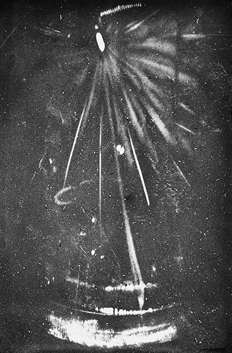

5.云室。

5. Cloud chamber.

在20世纪60年代初一篇著名的科学实在论辩护文章中，格罗弗·麦克斯韦向反实在论者提出了以下问题。考虑以下一系列事件：用肉眼观察某物，透过窗户观察某物，透过一副高度数的眼镜观察某物，透过双筒望远镜观察某物，透过低倍显微镜观察某物，透过……高倍显微镜等等。麦克斯韦认为这些事件处于一个平滑的连续体上。那么，我们如何决定哪些算作观察，哪些不算呢？生物学家可以观察吗？他们能否借助高倍显微镜直接观察到微生物？或者他们只能像物理学家在云室中探测电子那样探测到微生物的存在？如果某种事物只能借助精密的科学仪器才能被观察到，那么它究竟是可观测的还是不可观测的？仪器要达到何种精密程度，才能区分出“探测”和“观察”？麦克斯韦认为，这类问题没有原则性的答案，因此反实在论者试图将实体分为可观测和不可观测两类的做法是失败的。

In a well-known defence of scientific realism from the early 1960s, Grover Maxwell posed the following problem for the anti-realist. Consider the following sequence of events: looking at something with the naked eye, looking at something through a window, looking at something through a pair of strong glasses, looking at something through binoculars, looking at something through a low-powered microscope, looking at something through a high-powered microscope, and so on. Maxwell argued that these events lie on a smooth continuum. So how do we decide which count as observing and which not? Can a biologist observe micro-organisms with their high-powered microscope, or can they only detect their presence in the way that a physicist can detect the presence of electrons in a cloud chamber? If something can be only be seen with the help of sophisticated scientific instruments, does it count as observable or unobservable? How sophisticated can the instrumentation be, before we have a case of detecting rather than observing? There is no principled way of answering such questions, Maxwell argued, so the anti-realist’s attempt to classify entities as either observable or unobservable fails.

麦克斯韦的论点得到了科学家自身有时也会借助精密仪器“观察”粒子这一事实的支持。在哲学文献中，电子通常被视为不可观察实体的典型例子，但科学家们却常常乐于谈论使用粒子探测器“观察”电子。当然，这并不能证明哲学家们的观点是错误的，也不能证明电子实际上是可观察的，因为科学家们的这种说法或许更像是一种*修辞手法*。同样地，正如我们在第二章中所看到的，科学家们谈论某个理论的“实验证明”并不意味着实验真的能够证明理论的正确性。然而，如果真如反实在论者所坚持的那样，存在一个在哲学上重要的可观察/不可观察的区分，那么它与科学家们自身的表达方式如此不符，就显得十分奇怪了。

Maxwell’s argument is bolstered by the fact that scientists themselves sometimes talk about ‘observing’ particles with the help of sophisticated bits of apparatus. In the philosophical literature, electrons are usually taken as paradigm examples of unobservable entities, but scientists are often perfectly happy to talk about ‘observing’ electrons using particle detectors. Of course, this does not prove that the philosophers are wrong and that electrons are observable after all, for the scientists’ talk is probably best regarded as a *façon de parler*. Similarly, the fact that scientists talk about having ‘experimental proof’ of a theory does not mean that experiments can really prove theories to be true, as we saw in Chapter 2. Nonetheless, if there really is a philosophically important observable/unobservable distinction, as anti-realists maintain, it is odd that it corresponds so badly with the way scientists themselves speak.

麦克斯韦的论证有力，但并不具有决定性。当代反实在论的领军人物巴斯·范·弗拉森认为，麦克斯韦的论证仅仅表明“可观察的”是一个模糊的概念。模糊的概念指的是存在模糊不清的情况。“秃顶”就是一个例子。由于脱发程度不一，很多男性很难判断他们是否秃顶。但范·弗拉森指出，模糊的概念完全可以使用，并且可以在现实世界中区分不同的事物。没有人会仅仅因为“秃顶”是一个模糊的概念就认为秃顶和毛发浓密之间的区别是不真实的。模糊不清。当然，如果我们试图划出一条清晰的界限，那必然是武断的。但由于秃顶和不秃顶的男性之间存在着泾渭分明的例子，缺乏一条清晰的界限也就无关紧要了。范·弗拉森认为，“可观测”的概念也同样如此。有些实体可以被观测，例如椅子；有些实体则不能，例如夸克。麦克斯韦的论证强调了这样一个事实：也存在一些模糊不清的情况，我们无法确定这些实体是可以被观测到还是只能被探测到。因此，如果我们试图划出一条清晰的界限，那必然会带有一些武断的成分。但就像秃顶一样，这并不意味着可观测/不可观测的区分是不真实的。

Maxwell’s arguments are powerful but not decisive. Bas van Fraassen, a leading contemporary anti-realist, claims that Maxwell’s arguments only show ‘observable’ to be a vague term. A vague term is one that has borderline cases. ‘Bald’ is an example. Since hair loss comes in degrees, there are many men of whom it’s hard to say whether they are bald or not. But van Fraassen points out that vague terms are perfectly usable, and can mark genuine distinctions in the world. No one would argue that the distinction between bald and hirsute men is unreal simply because ‘bald’ is vague. Certainly, if we attempt to draw a sharp dividing line it will be arbitrary. But since there are clear-cut cases of men who are bald and men who are not, the lack of a sharp dividing line doesn’t matter. Precisely the same applies to ‘observable’, according to van Fraassen. There are clear-cut cases of entities that can be observed, for example chairs, and entities that cannot, for example quarks. Maxwell’s argument highlights the fact that there are also borderline cases, where we are unsure whether the entities in question can be observed or only detected. So if we try to draw a sharp dividing line, it will inevitably be somewhat arbitrary. But as with baldness, this does not show that the observable/unobservable distinction is unreal.

这个论点有多强？范·弗拉森或许是对的，即存在边界案例，以及由此导致无法在不带任意性的情况下划定清晰的界限，并不能证明可观察/不可观察的区分是不真实的。从这个意义上讲，他对麦克斯韦的反驳是成功的。然而，证明可观察与不可观察之间存在真实区别是一回事，证明这种区别值得反实在论者赋予它的重要性则是另一回事。即使我们承认范·弗拉森的观点，即存在明显的不可观察实体，并且这足以让反实在论者继续推进，我们仍然需要论证为什么对不可观察的现实的认识是不可能的。

How strong an argument is this? Van Fraassen is probably right that the existence of borderline cases, and the consequent impossibility of drawing a sharp boundary without arbitrariness, does not show the observable/unobservable distinction to be unreal. To that extent, his argument against Maxwell succeeds. However, it is one thing to show that there is a real distinction between what is observable and what is not, and another to show that the distinction merits the significance that anti-realists accord it. Even if we grant van Fraassen his point that there are clear cases of unobservable entities, and that that is enough for the anti-realist to get on with, an argument is still needed for why knowledge of unobservable reality is impossible.

# 欠决定论证

# The underdetermination argument

其中一种论点聚焦于科学家经验数据与其理论之间的关系。反实在论者强调，科学理论所依据的经验数据是关于可观察实体和过程的事实。举例来说，我们再次考虑气体动力学理论，该理论认为任何气体样本都由运动的分子组成。由于这些分子是不可观察的，我们显然无法通过直接观察各种气体样本来检验该理论。相反，我们需要……从理论中推导出一些可以直接检验的陈述，这些陈述必然是关于可观测实体的。正如我们所见，动力学理论表明，恒压下的气体样品在加热时会膨胀。这一陈述可以通过观察实验室中相关仪器的读数来直接检验。这个例子说明了一条普遍真理：关于可观测现象的事实为那些假设不可观测实体和过程的理论提供了最终数据。

One such argument focuses on the relation between scientists’ empirical data and their theories. Anti-realists emphasize that the empirical data to which scientific theories are responsible consist of facts about observable entities and processes. To illustrate, consider again the kinetic theory of gases, which says that any sample of gas consists of molecules in motion. Since these molecules are unobservable, we obviously cannot test the theory by directly observing various samples of gas. Rather, we need to deduce from the theory some statement that can be directly tested, which will invariably be about observable entities. As we saw, the kinetic theory implies that a sample of gas at constant pressure will expand when heated. This statement can be directly tested, by observing the readings on the relevant pieces of apparatus in a laboratory. This example illustrates a general truth: facts about observable phenomena provide the ultimate data for theories that posit unobservable entities and processes.

反实在论者进而认为，经验数据“不足以解释”科学家基于这些数据提出的理论。这意味着什么呢？这意味着原则上，这些数据可以用许多不同的、相互矛盾的理论来解释。以分子运动论为例，反实在论者会说，对经验数据的*一种*可能解释是，气体包含大量运动的分子，正如分子运动论所描述的那样。但他们坚持认为，还存在其他可能的解释，这些解释与分子运动论相冲突。因此，根据反实在论者的观点，假设存在不可观测实体的科学理论会*被*经验数据“不足以解释”——总会有许多相互竞争的理论能够同样很好地解释这些数据。

Anti-realists then argue that the empirical data ‘underdetermine’ the theories scientists put forward on their basis. What does this mean? It means that the data can in principle be explained by many different, mutually incompatible, theories. In the case of the kinetic theory, anti-realists will say that *one* possible explanation of the empirical data is that gases contain large numbers of molecules in motion, as the kinetic theory says. But they will insist that there are other possible explanations too, which conflict with the kinetic theory. So according to anti-realists, scientific theories which posit unobservable entities are *underdetermined* by the empirical data—there will always be a number of competing theories which can account for the data equally well.

不难理解，为何“不确定性决定论”支持反实在论的科学观。假设一位科学家相信某个关于不可观测实体的理论，理由是该理论能够解释大量的经验数据。然而，如果这些数据同样可以被其他相互矛盾的理论所解释，那么这位科学家的自信就显得毫无根据。他凭什么偏爱自己的理论而放弃其他理论呢？不确定性决定论自然而然地导向反实在论的结论：对于关于不可观测现实领域的理论，不可知论才是理性的态度。

It is easy to see why the underdetermination argument supports an anti-realist view of science. Suppose a scientist believes a given theory about unobservable entities, on the grounds that it can explain a large range of empirical data. However if the data can equally be accounted for by alternative theories, which are mutually incompatible, then the scientist’s confidence seems misplaced. For what reason does the scientist have to prefer their theory to one of the alternatives? Underdetermination leads naturally to the anti-realist conclusion that agnosticism is the rational attitude to take towards theories about the unobservable region of reality.

但反实在论者所坚持的那种观点是否真的能够用多种理论来解释经验数据呢？实在论者通常回应说，这种说法只在微不足道的意义上成立。原则上，对于给定的观测结果，总是存在不止一种可能的解释。但现实主义者认为，这并不意味着所有这些可能的解释都同样有效。例如，某个理论可能比其他理论更简单，或者更能与其他科学领域的理论相契合，或者假设的隐藏原因更少。现实主义者认为，一旦我们承认理论选择的标准不仅仅在于与数据的兼容性，那么解释不足的问题就迎刃而解了。

But is it true that the empirical data can always be explained by multiple theories, as anti-realists maintain? Realists typically reply that this is true only in a trivial sense. In principle, there will always be more than one possible explanation of a given set of observations. But, say the realists, it does not follow that all of these possible explanations are equally good. One of the theories might be simpler than the others, for example, or might fit better with theories from another area of science, or might postulate fewer hidden causes. Once we acknowledge that there are criteria for theory choice that go beyond mere compatibility with the data, the problem of underdetermination is defused, according to realists.

这种思路得到了科学史上真正意义上的“不充分决定论”案例相对较少这一事实的支持。如果像反实在论者所坚持的那样，经验数据总是能被许多不同的理论解释，那么我们理应看到科学家们几乎永远处于争论之中。但事实并非如此。实际上，当我们考察历史记录时，情况几乎与“不充分决定论”的论证所预期的完全相反。科学家们非但没有面临大量对其数据的替代解释，反而常常难以找到*一个*能够充分拟合数据的理论。这支持了实在论的观点，即“不充分决定论”仅仅是哲学家们的担忧，与实际的科学实践几乎毫无关联。

This line of thought is bolstered by the fact that there are relatively few real cases of underdetermination in the history of science. If the empirical data can always be explained by many different theories, as anti-realists maintain, surely we should expect to find scientists in near perpetual disagreement with one another? But that is not what we find. Indeed when we inspect the historical record, the situation is almost exactly the reverse of what the underdetermination argument would lead us to expect. Far from scientists being faced with a large number of alternative explanations of their data, they often have difficulty finding even *one* theory that fits the data adequately. This lends support to the realist view that underdetermination is merely a philosopher’s worry, with little relation to actual scientific practice.

反实在论者不太可能对这种回应感到满意。毕竟，哲学上的担忧仍然是合理的，即便它们的实际意义微乎其微。此外，认为可以用诸如简洁性之类的标准来评判相互竞争的理论，这立刻引出了一个棘手的问题：为什么更简单的理论就更有可能是正确的？我们在第二章中已经探讨过这个问题。

Anti-realists are unlikely to be impressed by this response. After all, philosophical worries are still genuine ones, even if their practical implications are few. Moreover, the suggestion that criteria such as simplicity can be used to adjudicate between competing theories immediately invites the awkward question of why simpler theories should be thought more likely to be true; we touched on this issue in Chapter 2.

反实在论者通常承认，在实践中可以通过诸如简洁性之类的标准来区分对数据的相互竞争的解释，从而消除不确定性。但他们否认这些标准是真理的可靠指标。简单的理论或许更便于操作，但它们本质上并不比复杂的理论更可能成立。因此，不完全决定论的论点依然成立：原则上，经验数据总是有多种解释，我们无从得知哪种解释是正确的，因此我们无法获得关于不可观察现实的知识。

Anti-realists typically grant that underdetermination can be eliminated in practice by using criteria such as simplicity to discriminate between competing explanations of our data. But they deny that such criteria are reliable indicators of the truth. Simpler theories may be more convenient to work with, but they are not intrinsically more probable than complex ones. So the underdetermination argument stands: in principle there are always multiple explanations of the empirical data, we have no way of knowing which is true, so knowledge of unobservable reality cannot be had.

然而，故事并未就此结束；现实主义者还有进一步的反驳。现实主义者指责反现实主义者选择性地运用“不确定性论证”。现实主义者认为，如果始终如一地运用这一论证，不仅会排除对不可观测世界的知识，还会排除对大部分*可观测*世界的知识。为了理解现实主义者为何如此认为，我们不妨注意到，许多可观测的事物实际上从未被观测到。例如，地球上绝大多数生物从未被人类观测到，但它们显然是可观测的。再比如，想想陨石撞击地球这样的事件。虽然从未有人亲眼目睹过此类事件，但它显然是可观测的。只不过恰好没有人恰好出现在正确的时间和地点。只有极小一部分可观测的事物最终被观测到。

However the story does not end here; there is a further realist comeback. Realists accuse anti-realists of applying the underdetermination argument selectively. If the argument is applied consistently, it rules out not only knowledge of the unobservable world, but also knowledge of much of the *observable* world, say the realists. To understand why realists say this, notice that many things that are observable never actually get observed. For example, the vast majority of living organisms on the planet never get observed by humans, but they are clearly observable. Or think of an event such as a large meteorite hitting the earth. No one has ever witnessed such an event, but it is clearly observable. It just so happens that no human was ever in the right place at the right time. Only a small fraction of what is observable actually gets observed.

关键在于此。反实在论者声称，不可观测的现实领域超出了科学知识的范畴。因此，他们承认我们可以了解那些可观测但未被观测*到的*物体和事件。然而，关于不可观测事物的理论，其数据不确定性并不亚于关于不可观测事物的理论。例如，假设一位科学家提出假设：1987年一颗陨石撞击了月球。他引用了各种观测数据来支持这一假设，例如，卫星拍摄的月球照片显示，月球上出现了一个1987年之前并不存在的大陨石坑。然而，原则上，这些数据可以用其他假设来解释——或许是火山爆发或地震造成了这个陨石坑。又或许是拍摄卫星照片的相机出了故障，实际上根本没有陨石坑。因此，这位科学家的假设同样无法完全被数据所证实。尽管这个假设是关于一个完全可观测的事件——陨石撞击月球。现实主义者认为，如果我们始终如一地运用不确定性论证，就不得不得出这样的结论：科学只能为我们提供关于实际观测到的事物的知识。

The key point is this. Anti-realists claim that the unobservable region of reality lies beyond the limits of scientific knowledge. So they allow that we can have knowledge of objects and events that are observable but unobserv*ed*. But theories about the unobserved are no less underdetermined by our data than theories about the unobservable. For example, suppose a scientist advances the hypothesis that a meteorite struck the moon in 1987. They cite various pieces of observational data to support this hypothesis, e.g. that satellite pictures of the moon show a large crater that wasn’t there before 1987. However, this data can in principle be explained by alternative hypotheses—perhaps a volcanic eruption caused the crater, or an earthquake. Or perhaps the camera that took the satellite pictures was faulty, and there is no crater at all. So the scientist’s hypothesis is underdetermined by the data, even though the hypothesis is about a perfectly observable event—a meteorite striking the moon. If we apply the underdetermination argument consistently, say realists, we are forced to conclude that science can only give us knowledge of things that have actually been observed.

许多科学哲学家并不认同这一结论。因为科学告诉我们的大部分内容都与尚未被观测到的事物有关——例如冰河时代、恐龙和大陆漂移。如果说我们不可能获得关于未观测事物的知识，那就等于说大多数被认为是科学知识的东西根本就不是真正的知识。科学实在论者认为这表明“未确定性论证”必然是错误的。既然科学显然能够为我们提供关于未观测事物的知识，即便我们关于未观测事物的理论受到数据的未确定性限制，那么未确定性本身就不是获得知识的障碍。因此，我们关于未观测事物的理论也受到未确定性限制这一事实，并不意味着科学无法为我们提供关于未观测事物的知识。

This conclusion is not one that many philosophers of science would accept. For much of what science tell us concerns things that have not been observed—think of ice ages, dinosaurs, and continental drift. To say that knowledge of the unobserved is impossible is to say that most of what passes for scientific knowledge is not really knowledge at all. Scientific realists take this to show that the underdetermination argument must be wrong. Since science clearly does give us knowledge of the unobserved, despite the fact that theories about the unobserved are underdetermined by our data, it follows that underdetermination is no barrier to knowledge. So the fact that our theories about the unobservable are also underdetermined does not mean that science cannot give us knowledge of the unobservable.

实际上，持这种观点的实在论者认为，不完全决定论问题不过是换了种说法的休谟归纳问题。不完全决定论意味着数据可以用其他理论来解释。但这实际上只是说数据并不蕴含理论：从数据到理论的推论是非演绎的。无论理论是关于不可观测的实体，还是关于可观测但不可观测的实体，都无关紧要——两种情况下逻辑相同。当然，证明不完全决定论证只是归纳问题的一种变体，并不意味着它可以被忽略。但这确实意味着，对于不可观测的实体，并没有什么*特殊的*困难。因此，实在论者认为，反实在论的立场最终是武断的。理解科学如何赋予我们关于原子和电子的知识所面临的任何难题，同样也适用于理解科学如何赋予我们关于普通宏观物体的知识。

In effect, realists who argue this way are saying that the underdetermination problem is simply Hume’s problem of induction in disguise. Underdetermination means that the data can be accounted for by alternative theories. But this is effectively just to say that the data do not entail the theory: the inference from data to theory is non-deductive. Whether the theory is about unobservable entities, or about observable but unobserved entities, makes no difference—the logic of the situation is the same in both cases. Of course, showing that the underdetermination argument is just a version of the problem of induction does not mean that it can be ignored. But it does mean that there is no *special* difficulty about unobservable entities. Therefore the anti-realist position is ultimately arbitrary, say the realists. Whatever problems there are in understanding how science can give us knowledge of atoms and electrons are equally problems for understanding how science can give us knowledge of ordinary macroscopic objects.